# MSD

**Spark notebook**

This is the notebook file for Assignment 2 MSD Author: Yuanyuan Qin Date: 2023/10/15

This notebook will only work in a Jupyter session running on `mathmadslinux2p`.

You can start your own Jupyter session on `mathmadslinux2p` and open this notebook in Chrome on the MADS Windows server by

1. Login to the MADS Windows server using https://mathportal.canterbury.ac.nz/.
2. Download or copy this notebook to your home directory.
3. Open powershell and run `ssh mathmadslinux2p`.
4. Run `start_pyspark_notebook` or `/opt/anaconda3/bin/jupyter-notebook --ip 132.181.129.68 --port $((8000 + $((RANDOM % 999))))`.
5. Copy / paste the url provided in the shell window into Chrome on the MADS Windows server.
6. Open the notebook from the Jupyter root directory (which is your home directory).
7. Run `start_spark()` to start a spark session in the notebook.
8. Run `stop_spark()` before closing the notebook or kill your spark application by hand using the link in the Spark UI.

```python
# Run this cell to import pyspark and to define start_spark() and stop_spark()

import findspark

findspark.init()

import getpass
import pandas
import pyspark
import random
import re

from IPython.display import display, HTML
from pyspark import SparkContext
from pyspark.sql import SparkSession


# Functions used below

def username():
    """Get username with any domain information removed.
    """

    return re.sub('@.*', '', getpass.getuser())


def dict_to_html(d):
    """Convert a Python dictionary into a two column table for display.
    """

    html = []

    html.append(f'<table width="100%" style="width:100%; font-family: monospace;">')
    for k, v in d.items():
        html.append(f'<tr><td style="text-align:left;">{k}</td><td>{v}</td></tr>')
    html.append(f'</table>')

    return ''.join(html)


def show_as_html(df, n=20):
    """Leverage existing pandas jupyter integration to show a spark dataframe as html.

    Args:
        n (int): number of rows to show (default: 20)
    """

    display(HTML(df.limit(n).toPandas().to_html(max_rows=n, max_cols=100)))


def display_spark():
    """Display the status of the active Spark session if one is currently running.
    """

    if 'spark' in globals() and 'sc' in globals():

        name = sc.getConf().get("spark.app.name")

        html = [
            f'<p><b>Spark</b></p>',
            f'<p>The spark session is <b><span style="color:green">active</span></b>, look for <code>{name}</code> under the running applications section in the Spark UI.</p>',
            f'<ul>',
            f'<li><a href="http://mathmadslinux2p.canterbury.ac.nz:8080/" target="_blank">Spark UI</a></li>',
            f'<li><a href="{sc.uiWebUrl}" target="_blank">Spark Application UI</a></li>',
            f'</ul>',
            f'<p><b>Config</b></p>',
            dict_to_html(dict(sc.getConf().getAll())),
            f'<p><b>Notes</b></p>',
            f'<ul>',
            f'<li>The spark session <code>spark</code> and spark context <code>sc</code> global variables have been defined by <code>start_spark()</code>.</li>',
            f'<li>Please run <code>stop_spark()</code> before closing the notebook or restarting the kernel or kill <code>{name}</code> by hand using the link in the Spark UI.</li>',
            f'</ul>',
        ]
        display(HTML(''.join(html)))

    else:

        html = [
            f'<p><b>Spark</b></p>',
            f'<p>The spark session is <b><span style="color:red">stopped</span></b>, confirm that <code>{username() + " (jupyter)"}</code> is under the completed applications section in the Spark UI.</p>',
            f'<ul>',
            f'<li><a href="http://mathmadslinux2p.canterbury.ac.nz:8080/" target="_blank">Spark UI</a></li>',
            f'</ul>',
        ]
        display(HTML(''.join(html)))


# Functions to start and stop spark

def start_spark(executor_instances=2, executor_cores=1, worker_memory=1, master_memory=1):
    """Start a new Spark session and define globals for SparkSession (spark) and SparkContext (sc).

    Args:
        executor_instances (int): number of executors (default: 2)
        executor_cores (int): number of cores per executor (default: 1)
        worker_memory (float): worker memory (default: 1)
        master_memory (float): master memory (default: 1)
    """

    global spark
    global sc

    user = username()

    cores = executor_instances * executor_cores
    partitions = cores * 4
    port = 4000 + random.randint(1, 999)

    spark = (
        SparkSession.builder
        .master("spark://masternode2:7077")
        .config("spark.driver.extraJavaOptions", f"-Dderby.system.home=/tmp/{user}/spark/")
        .config("spark.dynamicAllocation.enabled", "false")
        .config("spark.executor.instances", str(executor_instances))
        .config("spark.executor.cores", str(executor_cores))
        .config("spark.cores.max", str(cores))
        .config("spark.executor.memory", f"{worker_memory}g")
        .config("spark.driver.memory", f"{master_memory}g")
        .config("spark.driver.maxResultSize", "0")
        .config("spark.sql.shuffle.partitions", str(partitions))
        .config("spark.ui.port", str(port))
        .appName(user + " (jupyter)")
        .getOrCreate()
    )
    sc = SparkContext.getOrCreate()

    display_spark()


def stop_spark():
    """Stop the active Spark session and delete globals for SparkSession (spark) and SparkContext (sc).
    """

    global spark
    global sc

    if 'spark' in globals() and 'sc' in globals():

        spark.stop()

        del spark
        del sc

    display_spark()


# Make css changes to improve spark output readability

html = [
    '<style>',
    'pre { white-space: pre !important; }',
    'table.dataframe td { white-space: nowrap !important; }',
    'table.dataframe thead th:first-child, table.dataframe tbody th { display: none; }',
    '</style>',
]
display(HTML(''.join(html)))


# Print function docstrings

help(start_spark)
help(stop_spark)
help(display_spark)
help(show_as_html)
```

```
Help on function start_spark in module __main__:

start_spark(executor_instances=2, executor_cores=1, worker_memory=1, master_memory=1)
    Start a new Spark session and define globals for SparkSession (spark) and SparkContext (sc).

    Args:
        executor_instances (int): number of executors (default: 2)
        executor_cores (int): number of cores per executor (default: 1)
        worker_memory (float): worker memory (default: 1)
        master_memory (float): master memory (default: 1)

Help on function stop_spark in module __main__:

stop_spark()
    Stop the active Spark session and delete globals for SparkSession (spark) and SparkContext (sc).

Help on function display_spark in module __main__:

display_spark()
    Display the status of the active Spark session if one is currently running.

Help on function show_as_html in module __main__:

show_as_html(df, n=20)
    Leverage existing pandas jupyter integration to show a spark dataframe as html.

    Args:
        n (int): number of rows to show (default: 20)
```

### Start Spark

```python
# Run this cell to start a spark session in this notebook
start_spark(executor_instances=4, executor_cores=4, worker_memory=4, master_memory=4)
```

**Spark**

The spark session is **active**, look for `yqi43 (jupyter)` under the running applications section in the Spark UI.

- [Spark UI](http://mathmadslinux2p.canterbury.ac.nz:8080/)

- [Spark Application UI](http://mathmadslinux2p.canterbury.ac.nz:4069)

**Config**

| spark.sql.shuffle.partitions | 64 |
| --- | --- |
| spark.dynamicAllocation.enabled | false |
| spark.executor.instances | 4 |
| spark.driver.memory | 4g |
| spark.executor.memory | 4g |
| spark.master | spark://masternode2:7077 |
| spark.cores.max | 16 |
| spark.executor.id | driver |
| spark.sql.warehouse.dir | file:/users/home/yqi43/spark-warehouse |
| spark.driver.host | mathmadslinux2p.canterbury.ac.nz |
| spark.driver.port | 36167 |
| spark.executor.cores | 4 |
| spark.driver.extraJavaOptions | -Dderby.system.home=/tmp/yqi43/spark/ |
| spark.rdd.compress | True |
| spark.serializer.objectStreamReset | 100 |
| spark.driver.maxResultSize | 0 |
| spark.app.id | app-20231016083648-0864 |
| spark.submit.pyFiles |  |
| spark.app.name | yqi43 (jupyter) |
| spark.submit.deployMode | client |
| spark.ui.port | 4069 |
| spark.ui.showConsoleProgress | true |
| spark.app.startTime | 1697398607261 |

**Notes**

- The spark session `spark` and spark context `sc` global variables have been defined by `start_spark()`.

- Please run `stop_spark()` before closing the notebook or restarting the kernel or kill `yqi43 (jupyter)` by hand using the link in the Spark UI.

### import library and help function

```python
# Write your imports and code here or insert cells below

from pyspark.sql import Row, DataFrame, Window, functions as F
from pyspark.sql.types import *
from pyspark.sql.functions import *

from pyspark.ml.classification import GBTClassifier, LogisticRegression
from pyspark.ml.classification import LinearSVC
from pyspark.ml.classification import RandomForestClassifier

from pyspark.ml.evaluation import MulticlassClassificationEvaluator
from pyspark.ml.evaluation import BinaryClassificationEvaluator
from pyspark.ml.feature import VectorAssembler
from pyspark.ml.stat import Correlation
from pyspark.ml.tuning import CrossValidator, ParamGridBuilder

from pyspark.ml.evaluation import RankingEvaluator
from pyspark.ml.recommendation import ALS

name = "yqi43"
```

```python
# Other imports to be used locally

import subprocess
import math
import os

import datetime

import matplotlib as mpl
import matplotlib.pyplot as plt
import seaborn as sns
import numpy as np
import scipy as sp
import pandas as pd

%matplotlib notebook
```

```python
# help function for classification

np.set_printoptions(edgeitems=5, threshold=100, precision=4)

def file_line_count(file_path):
    """
    Count the rows of .csv, .txt, .tsv
    Returns the rows count of each file

    """

    command = f"hdfs dfs -cat {file_path} | wc -l"
    result = subprocess.run(command, shell=True, stdout=subprocess.PIPE, text=True)
    return int(result.stdout.strip())

def get_all_folders(path):
    """
    Get the sub-folder name from the hdfs path and save it to an list

    """
    folders = []
    hdfs_ls_cmd = f"hdfs dfs -ls {path}"
    ls_output = subprocess.check_output(hdfs_ls_cmd, shell=True).decode("utf-8")
    folder_names = [line.split()[-1] for line in ls_output.strip().split("\n") if line.startswith("drwx")]
    for folder in folder_names:
        folders.append(folder)
        folders.extend(get_all_folders(folder))
    return folders

def expand(x, s=0.05, d=0):
    """Expand a two element array about its center point by a relative scale or a fixed offset.
    Args:
        x (list|np.array): two element array
        s (float): relative scale to expand array based on its width x[1] - x[0]
        d (float): fixed offset to expand array
    Returns:
        x (np.array): expanded two element array
    """
    x = np.array(x)
    d = d + s * (x[1] - x[0])
    return x + np.array([-d, d])

def print_class_balance(data, name):
    """
    """

    total = data.count()
    counts = data.groupBy("label").count().toPandas()
    counts["ratio"] = counts["count"] / total

    print(f'dataset: {name}')
    print(f'total:   {total}')
    print(f'counts:')
    print(counts)
    print(f'')


def with_custom_prediction(pred, threshold, probabilityCol="probability", customPredictionCol="customPrediction"):
    """
    """

    apply_custom_threshold_udf = F.udf(lambda x: int(x[1] > threshold), IntegerType())

    return pred.withColumn(customPredictionCol, apply_custom_threshold_udf(F.col(probabilityCol)))


def print_metrics(pred, threshold=0.5, labelCol="label", predictionCol="prediction", rawPredictionCol="rawPrediction", probabilityCol="probability"):
    """
    """

    if threshold != 0.5:

        predictionCol = "customPrediction"
        pred = with_custom_prediction(pred, threshold, probabilityCol=probabilityCol, customPredictionCol=predictionCol)

    total = pred.count()

    nP_actual = pred.filter((F.col(labelCol) == 1)).count()
    nN_actual = pred.filter((F.col(labelCol) == 0)).count()

    nP = pred.filter((F.col(predictionCol) == 1)).count()
    nN = pred.filter((F.col(predictionCol) == 0)).count()
    TP = pred.filter((F.col(predictionCol) == 1) & (F.col(labelCol) == 1)).count()
    FP = pred.filter((F.col(predictionCol) == 1) & (F.col(labelCol) == 0)).count()
    FN = pred.filter((F.col(predictionCol) == 0) & (F.col(labelCol) == 1)).count()
    TN = pred.filter((F.col(predictionCol) == 0) & (F.col(labelCol) == 0)).count()

    if TP + FP > 0:
        precision = TP / (TP + FP)
    else:
        precision = 0

    recall = TP / (TP + FN)
    accuracy = (TP + TN) / total

    binary_evaluator = BinaryClassificationEvaluator(rawPredictionCol=rawPredictionCol, labelCol=labelCol, metricName='areaUnderROC')
    auroc = binary_evaluator.evaluate(pred)

    print(f'metrics for custom threshold')
    print(f'')
    print(f'threshold: {threshold}')
    print(f'')
    print(f'total:     {total}')
    print(f'')
    print(f'nP actual: {nP_actual}')
    print(f'nN actual: {nN_actual}')
    print(f'')
    print(f'nP:        {nP}')
    print(f'nN:        {nN}')
    print(f'')
    print(f'TP         {TP}')
    print(f'FP         {FP}')
    print(f'FN         {FN}')
    print(f'TN         {TN}')
    print(f'')
    print(f'precision: {precision:.8f}')
    print(f'recall:    {recall:.8f}')
    print(f'accuracy:  {accuracy:.8f}')
    print(f'')
    print(f'auroc:     {auroc:.8f}')
    print(f'')
```

```python
# Determine ideal number of partitions

conf = sc.getConf()

N = int(conf.get("spark.executor.instances"))
M = int(conf.get("spark.executor.cores"))
partitions = 4 * N * M

print(f'ideal # partitions = {partitions}')
```

```
ideal # partitions = 64
```

### Q1: Explore the data structure and file size

```python
# check the data structure

hdfs_path = "hdfs:///data/msd"

# Run file directory checking command: hdfs dfs -ls
command = f"hdfs dfs -ls {hdfs_path}"
process = subprocess.Popen(command, shell=True, stdout=subprocess.PIPE, stderr=subprocess.PIPE, text=True)

# get the output
stdout, stderr = process.communicate()

# print output
if process.returncode == 0:
    print("Files and directories in HDFS path:")
    print(stdout)
else:
    print(f"Error: {stderr}")
```

```
Files and directories in HDFS path:
Found 4 items
drwxr-xr-x   - jsw93 supergroup          0 2021-09-29 10:35 hdfs:///data/msd/audio
drwxr-xr-x   - jsw93 supergroup          0 2021-09-29 10:35 hdfs:///data/msd/genre
drwxr-xr-x   - jsw93 supergroup          0 2021-09-29 10:28 hdfs:///data/msd/main
drwxr-xr-x   - jsw93 supergroup          0 2021-09-29 10:35 hdfs:///data/msd/tasteprofile
```

```python
# Check the file size under each directory
!hdfs dfs -du -s -h hdfs:///data/msd/audio
!hdfs dfs -du -s -h hdfs:///data/msd/genre
!hdfs dfs -du -s -h hdfs:///data/msd/main
!hdfs dfs -du -s -h hdfs:///data/msd/tasteprofile
```

```
12.3 G  98.1 G  hdfs:///data/msd/audio
30.1 M  241.0 M  hdfs:///data/msd/genre
174.4 M  1.4 G  hdfs:///data/msd/main
490.4 M  3.8 G  hdfs:///data/msd/tasteprofile
```

```python
# audio directory
directory_path = "hdfs:///data/msd/audio"
result = subprocess.run(["hdfs", "dfs", "-du", "-h", directory_path], stdout=subprocess.PIPE, text=True)

# generate output
output = result.stdout

print(f"Total size of directory {directory_path}:")
print(output)
```

```
Total size of directory hdfs:///data/msd/audio:
103.0 K  824.3 K  hdfs:///data/msd/audio/attributes
12.2 G   97.8 G   hdfs:///data/msd/audio/features
40.3 M   322.1 M  hdfs:///data/msd/audio/statistics
```

```python
#genre directory
directory_path = "hdfs:///data/msd/genre"
result = subprocess.run(["hdfs", "dfs", "-du", "-h", directory_path], stdout=subprocess.PIPE, text=True)

# generate output
output = result.stdout

print(f"Total size of directory {directory_path}:")
print(output)
```

```
Total size of directory hdfs:///data/msd/genre:
11.1 M  88.7 M  hdfs:///data/msd/genre/msd-MAGD-genreAssignment.tsv
8.4 M   67.3 M  hdfs:///data/msd/genre/msd-MASD-styleAssignment.tsv
10.6 M  85.0 M  hdfs:///data/msd/genre/msd-topMAGD-genreAssignment.tsv
```

```python
# main directory
directory_path = "hdfs:///data/msd/main/summary"
result = subprocess.run(["hdfs", "dfs", "-du",  "-h", directory_path], stdout=subprocess.PIPE, text=True)

# generate output
output = result.stdout

print(f"Total size of directory {directory_path}:")
print(output)
```

```
Total size of directory hdfs:///data/msd/main/summary:
55.9 M   447.5 M  hdfs:///data/msd/main/summary/analysis.csv.gz
118.5 M  947.7 M  hdfs:///data/msd/main/summary/metadata.csv.gz
```

```python
# tasteprofile directory: triplets.tsv is a subdirectory, not the file

directory_path = "hdfs:///data/msd/tasteprofile"
result = subprocess.run(["hdfs", "dfs", "-du", "-h", directory_path], stdout=subprocess.PIPE, text=True)

# generate output
output = result.stdout

print(f"Total size of directory {directory_path}:")
print(output)
```

```
Total size of directory hdfs:///data/msd/tasteprofile:
2.0 M    16.2 M  hdfs:///data/msd/tasteprofile/mismatches
488.4 M  3.8 G   hdfs:///data/msd/tasteprofile/triplets.tsv
```

```python
# tasteprofile/mismatches directory
directory_path = "hdfs:///data/msd/tasteprofile/mismatches"
result = subprocess.run(["hdfs", "dfs", "-du", "-h", directory_path], stdout=subprocess.PIPE, text=True)

# generate output
output = result.stdout

print(f"Total size of directory {directory_path}:")
print(output)
```

```
Total size of directory hdfs:///data/msd/tasteprofile/mismatches:
89.2 K  713.6 K  hdfs:///data/msd/tasteprofile/mismatches/sid_matches_manually_accepted.txt
1.9 M   15.5 M   hdfs:///data/msd/tasteprofile/mismatches/sid_mismatches.txt
```

```python
# audio/statistics directory
directory_path = "hdfs:///data/msd/audio/statistics"
result = subprocess.run(["hdfs", "dfs", "-du", "-h", directory_path], stdout=subprocess.PIPE, text=True)

# generate output
output = result.stdout

print(f"Total size of directory {directory_path}:")
print(output)
```

```
Total size of directory hdfs:///data/msd/audio/statistics:
40.3 M  322.1 M  hdfs:///data/msd/audio/statistics/sample_properties.csv.gz
```

### Explore the dataset under Tier 2 directory

```python
# audio/attributes
directory_path = "hdfs:///data/msd/audio/attributes"
result = subprocess.run(["hdfs", "dfs", "-du", "-h", directory_path], stdout=subprocess.PIPE, text=True)

# generate output
output = result.stdout

print(f"Total size of directory {directory_path}:")
print(output)
```

```
Total size of directory hdfs:///data/msd/audio/attributes:
1.0 K   8.2 K    hdfs:///data/msd/audio/attributes/msd-jmir-area-of-moments-all-v1.0.attributes.csv
671     5.2 K    hdfs:///data/msd/audio/attributes/msd-jmir-lpc-all-v1.0.attributes.csv
484     3.8 K    hdfs:///data/msd/audio/attributes/msd-jmir-methods-of-moments-all-v1.0.attributes.csv
898     7.0 K    hdfs:///data/msd/audio/attributes/msd-jmir-mfcc-all-v1.0.attributes.csv
777     6.1 K    hdfs:///data/msd/audio/attributes/msd-jmir-spectral-all-all-v1.0.attributes.csv
777     6.1 K    hdfs:///data/msd/audio/attributes/msd-jmir-spectral-derivatives-all-all-v1.0.attributes.csv
12.0 K  96.2 K   hdfs:///data/msd/audio/attributes/msd-marsyas-timbral-v1.0.attributes.csv
9.8 K   78.0 K   hdfs:///data/msd/audio/attributes/msd-mvd-v1.0.attributes.csv
1.4 K   10.9 K   hdfs:///data/msd/audio/attributes/msd-rh-v1.0.attributes.csv
34.1 K  272.8 K  hdfs:///data/msd/audio/attributes/msd-rp-v1.0.attributes.csv
3.8 K   30.8 K   hdfs:///data/msd/audio/attributes/msd-ssd-v1.0.attributes.csv
9.8 K   78.0 K   hdfs:///data/msd/audio/attributes/msd-trh-v1.0.attributes.csv
27.6 K  221.2 K  hdfs:///data/msd/audio/attributes/msd-tssd-v1.0.attributes.csv
```

```python
# row counts of audio/attributes

file_paths = [
             "hdfs:///data/msd/audio/attributes/msd-jmir-area-of-moments-all-v1.0.attributes.csv",
             "hdfs:///data/msd/audio/attributes/msd-jmir-lpc-all-v1.0.attributes.csv",
             "hdfs:///data/msd/audio/attributes/msd-jmir-methods-of-moments-all-v1.0.attributes.csv",
             "hdfs:///data/msd/audio/attributes/msd-jmir-mfcc-all-v1.0.attributes.csv",
             "hdfs:///data/msd/audio/attributes/msd-jmir-spectral-all-all-v1.0.attributes.csv",
             "hdfs:///data/msd/audio/attributes/msd-jmir-spectral-derivatives-all-all-v1.0.attributes.csv",
             "hdfs:///data/msd/audio/attributes/msd-marsyas-timbral-v1.0.attributes.csv",
             "hdfs:///data/msd/audio/attributes/msd-mvd-v1.0.attributes.csv",
             "hdfs:///data/msd/audio/attributes/msd-rh-v1.0.attributes.csv",
             "hdfs:///data/msd/audio/attributes/msd-rp-v1.0.attributes.csv",
             "hdfs:///data/msd/audio/attributes/msd-ssd-v1.0.attributes.csv",
             "hdfs:///data/msd/audio/attributes/msd-trh-v1.0.attributes.csv",
             "hdfs:///data/msd/audio/attributes/msd-tssd-v1.0.attributes.csv"
            ]

for file_path in file_paths:
    line_count = file_line_count(file_path)
    print(f"File: {file_path} - Number of Rows: {line_count}")
```

```
File: hdfs:///data/msd/audio/attributes/msd-jmir-area-of-moments-all-v1.0.attributes.csv - Number of Rows: 21
File: hdfs:///data/msd/audio/attributes/msd-jmir-lpc-all-v1.0.attributes.csv - Number of Rows: 21
File: hdfs:///data/msd/audio/attributes/msd-jmir-methods-of-moments-all-v1.0.attributes.csv - Number of Rows: 11
File: hdfs:///data/msd/audio/attributes/msd-jmir-mfcc-all-v1.0.attributes.csv - Number of Rows: 27
File: hdfs:///data/msd/audio/attributes/msd-jmir-spectral-all-all-v1.0.attributes.csv - Number of Rows: 17
File: hdfs:///data/msd/audio/attributes/msd-jmir-spectral-derivatives-all-all-v1.0.attributes.csv - Number of Rows: 17
File: hdfs:///data/msd/audio/attributes/msd-marsyas-timbral-v1.0.attributes.csv - Number of Rows: 125
File: hdfs:///data/msd/audio/attributes/msd-mvd-v1.0.attributes.csv - Number of Rows: 421
File: hdfs:///data/msd/audio/attributes/msd-rh-v1.0.attributes.csv - Number of Rows: 61
File: hdfs:///data/msd/audio/attributes/msd-rp-v1.0.attributes.csv - Number of Rows: 1441
File: hdfs:///data/msd/audio/attributes/msd-ssd-v1.0.attributes.csv - Number of Rows: 169
File: hdfs:///data/msd/audio/attributes/msd-trh-v1.0.attributes.csv - Number of Rows: 421
File: hdfs:///data/msd/audio/attributes/msd-tssd-v1.0.attributes.csv - Number of Rows: 1177
```

```python
# 13 directories (NOT FILES) under audio/features

directory_path = "hdfs:///data/msd/audio/features"
result = subprocess.run(["hdfs", "dfs", "-du", "-h", directory_path], stdout=subprocess.PIPE, text=True)

# generate output
output = result.stdout

print(f"Total size of directory {directory_path}:")
print(output)
```

```
Total size of directory hdfs:///data/msd/audio/features:
65.5 M   524.2 M  hdfs:///data/msd/audio/features/msd-jmir-area-of-moments-all-v1.0.csv
53.1 M   424.6 M  hdfs:///data/msd/audio/features/msd-jmir-lpc-all-v1.0.csv
35.8 M   286.5 M  hdfs:///data/msd/audio/features/msd-jmir-methods-of-moments-all-v1.0.csv
70.8 M   566.1 M  hdfs:///data/msd/audio/features/msd-jmir-mfcc-all-v1.0.csv
51.1 M   408.9 M  hdfs:///data/msd/audio/features/msd-jmir-spectral-all-all-v1.0.csv
51.1 M   408.9 M  hdfs:///data/msd/audio/features/msd-jmir-spectral-derivatives-all-all-v1.0.csv
412.2 M  3.2 G    hdfs:///data/msd/audio/features/msd-marsyas-timbral-v1.0.csv
1.3 G    10.3 G   hdfs:///data/msd/audio/features/msd-mvd-v1.0.csv
240.3 M  1.9 G    hdfs:///data/msd/audio/features/msd-rh-v1.0.csv
4.0 G    32.3 G   hdfs:///data/msd/audio/features/msd-rp-v1.0.csv
640.6 M  5.0 G    hdfs:///data/msd/audio/features/msd-ssd-v1.0.csv
1.4 G    11.5 G   hdfs:///data/msd/audio/features/msd-trh-v1.0.csv
3.9 G    31.0 G   hdfs:///data/msd/audio/features/msd-tssd-v1.0.csv
```

```python
# row counts of tsv files under genre/

!hdfs dfs -cat hdfs:///data/msd/genre/msd-MAGD-genreAssignment.tsv | wc -l
!hdfs dfs -cat hdfs:///data/msd/genre/msd-MASD-styleAssignment.tsv | wc -l
!hdfs dfs -cat hdfs:///data/msd/genre/msd-topMAGD-genreAssignment.tsv | wc -l
```

```
422714
273936
406427
```

#### tasteprofile/mismatches/

```python
# row counts of txt file under tasteprofile/mismatches

!hdfs dfs -cat hdfs:///data/msd/tasteprofile/mismatches/sid_matches_manually_accepted.txt | wc -l
!hdfs dfs -cat hdfs:///data/msd/tasteprofile/mismatches/sid_mismatches.txt | wc -l
```

```
938
19094
```

### Load each dataset with schema

```python
# Load meta data from HDFS hdfs:///data/msd/main/summary/metadata.csv.gz

hdfs_file_path = "hdfs:///data/msd/main/summary/metadata.csv.gz"
meta_data = spark.read.option("header", "true").csv(hdfs_file_path)

meta_data = meta_data.repartition(partitions)

meta_data.cache()

meta_data.printSchema()

show_as_html(meta_data)
```

```
root
 |-- analyzer_version: string (nullable = true)
 |-- artist_7digitalid: string (nullable = true)
 |-- artist_familiarity: string (nullable = true)
 |-- artist_hotttnesss: string (nullable = true)
 |-- artist_id: string (nullable = true)
 |-- artist_latitude: string (nullable = true)
 |-- artist_location: string (nullable = true)
 |-- artist_longitude: string (nullable = true)
 |-- artist_mbid: string (nullable = true)
 |-- artist_name: string (nullable = true)
 |-- artist_playmeid: string (nullable = true)
 |-- genre: string (nullable = true)
 |-- idx_artist_terms: string (nullable = true)
 |-- idx_similar_artists: string (nullable = true)
 |-- release: string (nullable = true)
 |-- release_7digitalid: string (nullable = true)
 |-- song_hotttnesss: string (nullable = true)
 |-- song_id: string (nullable = true)
 |-- title: string (nullable = true)
 |-- track_7digitalid: string (nullable = true)
```

|  | analyzer_version | artist_7digitalid | artist_familiarity | artist_hotttnesss | artist_id | artist_latitude | artist_location | artist_longitude | artist_mbid | artist_name | artist_playmeid | genre | idx_artist_terms | idx_similar_artists | release | release_7digitalid | song_hotttnesss | song_id | title | track_7digitalid |
| --- | --- | --- | --- | --- | --- | --- | --- | --- | --- | --- | --- | --- | --- | --- | --- | --- | --- | --- | --- | --- |
| 0 | None | 54767 | 0.3361905414776491 | 0.24943173393177126 | AREVQ0L1187B9AD5EE | None | None | None | bf404f5a-d06b-4fbe-be16-48b98ff21191 | Felicia Sanders | 14463 | None | 0 | 0 | The Song From Moulin Rouge & Felicia At The Bl... | 301443 | 0.0 | SOGOBVM12A8C13B3E3 | My Love Belongs To You | 3392708 |
| 1 | None | 4072 | 0.6464539086139657 | 0.4073660190716647 | AR78JQQ1187FB387DB | 34.05349 | Los Angeles, CA | -118.24532 | e3bcf587-a354-4723-a2d3-1c679d6571ea | Bread | -1 | None | 0 | 0 | Peasant | 448545 | 0.48456252996792964 | SOUNEGE12AB017DA6C | Castro | 4979178 |
| 2 | None | 224464 | 0.5912885341033217 | 0.4938017984866659 | AR1SQV21187B9AE9C6 | None | None | None | c1f9719f-34bf-4243-b060-dbfa76cf8634 | Samsas Traum | -1 | None | 0 | 0 | Die Liebe Gottes | 541684 | 0.0 | SOTXLDE12AB018555D | Flügel aus Wachs - Das Wesen des Erzengels | 5996486 |
| 3 | None | 19261 | 0.6303741834258311 | 0.49979926064741664 | AR5GIG31187B9B2EB1 | None | None | None | fb5f6b0a-8854-45f5-854c-560cb2f347ad | Carpark North | 70782 | None | 0 | 0 | All Things To All People | 28269 | 0.6816111081066363 | SOVCCBR12A8C13C23B | Berlin | 309811 |
| 4 | None | 189840 | 0.4867119339149625 | 0.3737593582633744 | ARNMJB11187FB57C77 | 51.16418 | GERMANY | 10.45415 | 054f2808-5352-43df-9a6b-3051bb687f06 | Al Gromer Khan | -1 | None | 0 | 0 | Space Hotel | 248739 | 0.2998774882739778 | SOLKQAT12A8C138EFB | Utopia Al-Kahira-Beautiful Future | 2729203 |
| 5 | None | 367053 | 0.4217922530276164 | 0.31920972076720344 | AR0OEYB1187FB4A81E | 53.93063 | Yorkshire, England | -1.20788 | 7e92079b-6d93-4c8d-87bd-364c3a5d2bc3 | Catherine Howe | -1 | None | 0 | 0 | Harry / Silent Mother Nature | 495430 | None | SOEBDYP12AB018198D | Castle Gate (From Harry) | 5485495 |
| 6 | None | 189167 | 0.5087362002352603 | 0.39136213919306156 | ARJTZVE1187FB45066 | None | None | None | ea83bee9-c141-42ce-ba85-d1005b02dc24 | The Bobby McGee's | -1 | None | 0 | 0 | S'Amuser Com Des Fous | 244281 | None | SOKHTMW12A8C13C541 | Kafkaesque / Kafkan | 2906162 |
| 7 | None | 43119 | 0.620099160209649 | 0.3776235044704088 | ARZDGWJ1187B9AA5DC | None | None | None | 8ef27ebb-f741-4ddf-bf5d-61a6bb981eca | Vinylshakerz | -1 | None | 0 | 0 | Hypnotic Tango | 313862 | None | SOJWDVQ12A8C141FA6 | Hypnotic Tango | 3549899 |
| 8 | None | 41751 | 0.637523097942556 | 0.4257294134629907 | ARSFOFU1187B9B3EE0 | None | None | None | 37ff534b-5ec5-4fc7-9969-06e3fdf88aa5 | DJ Shog | -1 | None | 0 | 0 | 2Faces | 354150 | 0.36727341580934564 | SOORZZA12AAA8C8580 | Make The Sun Rise | 3959567 |
| 9 | None | 364882 | 0.525664623081966 | 0.4115843977024169 | ARK5JDG1187FB50CA9 | None | None | None | f83b5ecb-daf1-4a64-9499-402f8fea58ef | Sephiroth | -1 | None | 0 | 0 | Draconian Poetry | 492925 | 0.6591518500510904 | SOBFOAZ12AB017BAAD | Now Night Her Course Began | 5458315 |
| 10 | None | 4882 | 0.62558262471993 | 0.5513006194662533 | ARZ9RGY1187FB50D1A | None | None | None | 2a7fb97d-b2fe-4fdc-ac40-e283050aebe9 | Downhere | 41188 | None | 0 | 0 | Ending Is Beginning | 693116 | None | SOKBMTA12A58A7940B | The Beggar Who Gives Alms | 7694375 |
| 11 | None | 137944 | 0.6321657188034325 | 0.4552068137368764 | ARBFAWR1187FB3DD1E | None | None | None | 618bf47d-48ff-4aec-8d82-435b93dcca76 | Alejandra Guzman | 3202 | None | 0 | 0 | Indeleble | 518059 | 0.2707759989463275 | SONNRSQ12AB01874F7 | No Estoy Llorando | 5735910 |
| 12 | None | 15042 | 0.5188924721617288 | 0.3798605378552731 | ARRDDKG1187B98FF68 | None | None | None | 3b37a233-f776-4ebd-b946-c899db06e858 | Ranking Joe | 108379 | None | 0 | 0 | Zion High | 21372 | 0.4191258929591558 | SODBSKN12A6D4F7847 | Fire | 221579 |
| 13 | None | 9124 | 0.5622093760835152 | 0.3832695612233238 | ARS9D4S1187FB376C6 | None | None | None | feeea442-e401-4323-a7e2-e83f70ce4df9 | Sanctuary | 15776 | None | 0 | 0 | Refuge Denied | 282449 | 0.6091471665146831 | SOBHLUS12A8C130C60 | Soldiers Of Steel | 3140434 |
| 14 | None | 266231 | 0.53572065113582 | 0.3205832560821887 | ARIX60F1187FB418F6 | None | None | None | c7c3f631-d115-4704-908e-e025bd7ec49f | Mad Max | -1 | None | 0 | 0 | Here We Are | 342443 | None | SOWWOZX12AB01849F2 | Down To Babylon | 3834500 |
| 15 | None | 78207 | 0.49793219113114934 | 0.2582756159529409 | ARHOCA51187FB39213 | 40.71455 | NY - New York City | -74.00712 | f5c78cca-1bb5-40f4-a9e1-9b3c593715fa | Laura Leon | -1 | None | 0 | 0 | Preludes To Passion | 98022 | 0.0 | SOUESWQ12A8C13588E | Sicilienne (by Francis Poulenc) | 1018229 |
| 16 | None | 138507 | 0.5750943219706013 | 0.3074564459328186 | ARATF7W11C8A414F1F | None | None | None | a4e24871-8dad-4862-9939-ae921d2c5553 | Sandy Vee | -1 | None | 0 | 0 | Secret Love | 594883 | None | SOQTFQE12AB018AFB6 | Secret Love | 6600526 |
| 17 | None | 176575 | 0.3795434288341768 | 0.2807284279051808 | ARQCKT31187B98906B | 40.43831 | Pittsburgh, PA | -79.99745 | 5ae21532-265a-4149-9d44-d7f3c2161984 | Hurl | -1 | None | 0 | 0 | A Place Called Today | 517249 | 0.3231121208952123 | SOXXMCB12AB018A304 | Effie | 5725898 |
| 18 | None | 50318 | 0.4667847000922096 | 0.0 | ARWQ5AG1187B9AC600 | None | None | None | 8b4278af-86c3-4046-86bd-2b8df58a2446 | Gabriel Gordon | -1 | None | 0 | 0 | Frequency | 713466 | None | SOHJQKU12AB018B52F | Far And Wide | 7914865 |
| 19 | None | 23398 | 0.6323452021440723 | 0.45723920719357697 | AR4WP491187B9A9139 | 40.71455 | New York, NY | -74.00712 | 3257dcfb-0b88-4efa-ae43-9b92a799a463 | Dawn Landes | 53391 | None | 0 | 0 | Songs From The Point! | 624923 | 0.37616992484089345 | SOKKNDR12AB0182A59 | Lifeline | 6937759 |

```python
row_count = meta_data.count()
print(f"Total count of rows is {row_count}")
```

```
Total count of rows is 1000000
```

```python
# How many unique songs in the meta data record

unique_song_count = meta_data.select("song_id").distinct().count()

print("Number of unique song_id: ", unique_song_count)
```

```
Number of unique song_id:  998963
```

```python
# Load meta data from HDFS hdfs:///data/msd/main/summary/analysis.csv.gz

hdfs_file_path = "hdfs:///data/msd/main/summary/analysis.csv.gz"

analysis_df = spark.read.option("header", "true").csv(hdfs_file_path)

analysis_df = analysis_df.repartition(partitions)

analysis_df.cache()

analysis_df.printSchema()

show_as_html(analysis_df)
```

```
root
 |-- analysis_sample_rate: string (nullable = true)
 |-- audio_md5: string (nullable = true)
 |-- danceability: string (nullable = true)
 |-- duration: string (nullable = true)
 |-- end_of_fade_in: string (nullable = true)
 |-- energy: string (nullable = true)
 |-- idx_bars_confidence: string (nullable = true)
 |-- idx_bars_start: string (nullable = true)
 |-- idx_beats_confidence: string (nullable = true)
 |-- idx_beats_start: string (nullable = true)
 |-- idx_sections_confidence: string (nullable = true)
 |-- idx_sections_start: string (nullable = true)
 |-- idx_segments_confidence: string (nullable = true)
 |-- idx_segments_loudness_max: string (nullable = true)
 |-- idx_segments_loudness_max_time: string (nullable = true)
 |-- idx_segments_loudness_start: string (nullable = true)
 |-- idx_segments_pitches: string (nullable = true)
 |-- idx_segments_start: string (nullable = true)
 |-- idx_segments_timbre: string (nullable = true)
 |-- idx_tatums_confidence: string (nullable = true)
 |-- idx_tatums_start: string (nullable = true)
 |-- key: string (nullable = true)
 |-- key_confidence: string (nullable = true)
 |-- loudness: string (nullable = true)
 |-- mode: string (nullable = true)
 |-- mode_confidence: string (nullable = true)
 |-- start_of_fade_out: string (nullable = true)
 |-- tempo: string (nullable = true)
 |-- time_signature: string (nullable = true)
 |-- time_signature_confidence: string (nullable = true)
 |-- track_id: string (nullable = true)
```

|  | analysis_sample_rate | audio_md5 | danceability | duration | end_of_fade_in | energy | idx_bars_confidence | idx_bars_start | idx_beats_confidence | idx_beats_start | idx_sections_confidence | idx_sections_start | idx_segments_confidence | idx_segments_loudness_max | idx_segments_loudness_max_time | idx_segments_loudness_start | idx_segments_pitches | idx_segments_start | idx_segments_timbre | idx_tatums_confidence | idx_tatums_start | key | key_confidence | loudness | mode | mode_confidence | start_of_fade_out | tempo | time_signature | … |
| --- | --- | --- | --- | --- | --- | --- | --- | --- | --- | --- | --- | --- | --- | --- | --- | --- | --- | --- | --- | --- | --- | --- | --- | --- | --- | --- | --- | --- | --- | --- |
| 0 | 22050 | 7e7e91f9b6c3867a2271dbad03071df7 | 0.0 | 223.84281 | 2.647 | 0.0 | 0 | 0 | 0 | 0 | 0 | 0 | 0 | 0 | 0 | 0 | 0 | 0 | 0 | 0 | 0 | 4 | 0.78 | -12.496 | 1 | 0.706 | 212.741 | 117.96 | 4 | … |
| 1 | 22050 | f5c482ccb07a06fbe9d52422f4c1a745 | 0.0 | 175.12444 | 0.0 | 0.0 | 0 | 0 | 0 | 0 | 0 | 0 | 0 | 0 | 0 | 0 | 0 | 0 | 0 | 0 | 0 | 0 | 0.789 | -6.752 | 1 | 0.749 | 168.641 | 99.277 | 3 | … |
| 2 | 22050 | ca99675e8d734f6cd70978fadc427290 | 0.0 | 146.85995 | 0.084 | 0.0 | 0 | 0 | 0 | 0 | 0 | 0 | 0 | 0 | 0 | 0 | 0 | 0 | 0 | 0 | 0 | 9 | 0.348 | -8.577 | 0 | 0.363 | 146.86 | 85.515 | 4 | … |
| 3 | 22050 | 015bb8f7944f67eb1f7ec95b1bb0c9a7 | 0.0 | 250.67057 | 0.369 | 0.0 | 0 | 0 | 0 | 0 | 0 | 0 | 0 | 0 | 0 | 0 | 0 | 0 | 0 | 0 | 0 | 4 | 0.156 | -12.307 | 1 | 0.415 | 234.992 | 120.829 | 4 | … |
| 4 | 22050 | 36f29153bf3aa919c11721d799adbdc0 | 0.0 | 314.43546 | 4.725 | 0.0 | 0 | 0 | 0 | 0 | 0 | 0 | 0 | 0 | 0 | 0 | 0 | 0 | 0 | 0 | 0 | 2 | 0.762 | -4.614 | 1 | 0.717 | 309.847 | 177.554 | 3 | … |
| 5 | 22050 | 1f131c09988aa32ec9440cc31f4cc2e2 | 0.0 | 195.81342 | 0.0 | 0.0 | 0 | 0 | 0 | 0 | 0 | 0 | 0 | 0 | 0 | 0 | 0 | 0 | 0 | 0 | 0 | 1 | 0.758 | -9.828 | 0 | 0.657 | 189.922 | 123.319 | 4 | … |
| 6 | 22050 | b41339a6eb5ac2f37113944affd78c31 | 0.0 | 442.122 | 0.094 | 0.0 | 0 | 0 | 0 | 0 | 0 | 0 | 0 | 0 | 0 | 0 | 0 | 0 | 0 | 0 | 0 | 5 | 0.322 | -14.401 | 1 | 0.3 | 433.093 | 122.114 | 1 | … |
| 7 | 22050 | 7f8ce48f177b60bebe662e882c943054 | 0.0 | 156.23791 | 6.513 | 0.0 | 0 | 0 | 0 | 0 | 0 | 0 | 0 | 0 | 0 | 0 | 0 | 0 | 0 | 0 | 0 | 0 | 0.497 | -10.671 | 1 | 0.564 | 150.906 | 145.108 | 3 | … |
| 8 | 22050 | 9de55bf6bac2e75d2c9b698aaa215645 | 0.0 | 226.61179 | 0.206 | 0.0 | 0 | 0 | 0 | 0 | 0 | 0 | 0 | 0 | 0 | 0 | 0 | 0 | 0 | 0 | 0 | 0 | 0.557 | -4.718 | 1 | 0.348 | 221.257 | 106.956 | 4 | … |
| 9 | 22050 | e7bc2d5ba3f8af0cee2378b2505d81b6 | 0.0 | 182.96118 | 0.49 | 0.0 | 0 | 0 | 0 | 0 | 0 | 0 | 0 | 0 | 0 | 0 | 0 | 0 | 0 | 0 | 0 | 7 | 0.046 | -12.199 | 1 | 0.402 | 172.164 | 182.307 | 4 | … |
| 10 | 22050 | 48fa6c8138ac238bf98625dc335e1d76 | 0.0 | 279.48363 | 0.0 | 0.0 | 0 | 0 | 0 | 0 | 0 | 0 | 0 | 0 | 0 | 0 | 0 | 0 | 0 | 0 | 0 | 0 | 0.799 | -6.062 | 1 | 0.61 | 279.484 | 172.751 | 4 | … |
| 11 | 22050 | 738c456a357182939f3065a6b2b4b932 | 0.0 | 244.27057 | 0.136 | 0.0 | 0 | 0 | 0 | 0 | 0 | 0 | 0 | 0 | 0 | 0 | 0 | 0 | 0 | 0 | 0 | 1 | 0.168 | -5.766 | 0 | 0.344 | 235.224 | 87.867 | 4 | … |
| 12 | 22050 | de1dfc85b8db84fd77d78602aa3309f8 | 0.0 | 150.5171 | 0.432 | 0.0 | 0 | 0 | 0 | 0 | 0 | 0 | 0 | 0 | 0 | 0 | 0 | 0 | 0 | 0 | 0 | 6 | 0.211 | -7.558 | 0 | 0.341 | 143.627 | 168.98 | 1 | … |
| 13 | 22050 | c785fc705c6266eaed011240baf54bcb | 0.0 | 230.29506 | 0.363 | 0.0 | 0 | 0 | 0 | 0 | 0 | 0 | 0 | 0 | 0 | 0 | 0 | 0 | 0 | 0 | 0 | 10 | 0.848 | -5.476 | 1 | 0.499 | 225.048 | 159.983 | 1 | … |
| 14 | 22050 | e1a614730e1ea6abb0c97d0b89977b1a | 0.0 | 226.7424 | 2.165 | 0.0 | 0 | 0 | 0 | 0 | 0 | 0 | 0 | 0 | 0 | 0 | 0 | 0 | 0 | 0 | 0 | 0 | 0.013 | -11.879 | 1 | 0.228 | 219.179 | 88.601 | 1 | … |
| 15 | 22050 | 0cfecadf040afe38c9af481850b899d9 | 0.0 | 160.9922 | 2.757 | 0.0 | 0 | 0 | 0 | 0 | 0 | 0 | 0 | 0 | 0 | 0 | 0 | 0 | 0 | 0 | 0 | 7 | 0.862 | -16.519 | 1 | 0.68 | 147.731 | 237.313 | 4 | … |
| 16 | 22050 | 658e70b2e52b82413224d308d3519a4b | 0.0 | 148.6624 | 0.223 | 0.0 | 0 | 0 | 0 | 0 | 0 | 0 | 0 | 0 | 0 | 0 | 0 | 0 | 0 | 0 | 0 | 0 | 0.721 | -2.619 | 1 | 0.576 | 139.535 | 150.778 | 1 | … |
| 17 | 22050 | d4316edfeab155b531e3917d873fa9d6 | 0.0 | 273.29261 | 0.85 | 0.0 | 0 | 0 | 0 | 0 | 0 | 0 | 0 | 0 | 0 | 0 | 0 | 0 | 0 | 0 | 0 | 1 | 0.121 | -9.564 | 1 | 0.471 | 261.329 | 53.434 | 4 | … |
| 18 | 22050 | 6918843b9c8560c6501fd41ab6fdeea6 | 0.0 | 178.57261 | 0.177 | 0.0 | 0 | 0 | 0 | 0 | 0 | 0 | 0 | 0 | 0 | 0 | 0 | 0 | 0 | 0 | 0 | 7 | 0.513 | -9.051 | 1 | 0.543 | 171.624 | 188.662 | 4 | … |
| 19 | 22050 | 9aa5ac01177631877ca27d472b5479f8 | 0.0 | 223.05914 | 0.0 | 0.0 | 0 | 0 | 0 | 0 | 0 | 0 | 0 | 0 | 0 | 0 | 0 | 0 | 0 | 0 | 0 | 9 | 0.007 | -6.107 | 1 | 0.245 | 204.701 | 174.966 | 4 | … |

```python
row_count = analysis_df.count()
print(f"Total count of rows is {row_count}")
```

```
Total count of rows is 1000000
```

```python
# data/msd/tasteprofile/triplets.tsv/*.tsv.gz"

tsv_files_path = "hdfs:///data/msd/tasteprofile/triplets.tsv/*.tsv.gz"

triplets_df = spark.read.option("delimiter", "\t").csv(tsv_files_path)

triplets_df = triplets_df.repartition(partitions)

triplets_df.cache()

triplets_df.printSchema()

triplets_df = triplets_df.select(col("_c0").alias("user_id"), col("_c1").alias("song_id"),  col("_c2").alias("count") )

triplets_df.show(20, truncate=False)
```

```
root
 |-- _c0: string (nullable = true)
 |-- _c1: string (nullable = true)
 |-- _c2: string (nullable = true)

+----------------------------------------+------------------+-----+
|user_id                                 |song_id           |count|
+----------------------------------------+------------------+-----+
|0b686cfb5d93147b9fe257926d8f7a0dfed9e6dd|SORWJHX12AB01878BA|3    |
|eba0f97946f1dc60379fd092b3b238884c0460f7|SOHXJIW12A8C13C203|1    |
|d958fdfeaaaa184f49b04824bea9237776e57e88|SOOHLZA12A6D4F98E4|1    |
|9ee344b2293430ca3e8f306010a857a42a5ae19d|SOSRERB12A8C139735|3    |
|19a1df69360316e327ff447784a1aeffac2ddf10|SOQPJFE12A58A79D06|1    |
|fb3f3300399a8f99d75d5790aa7dcdfbd6b51f31|SONQEYS12AF72AABC9|4    |
|aa1b0744ceeb5a704b02e20b7b9af0197f1c747c|SOAUQUW12AF729CD58|1    |
|bc140e5d270f6412d98749a23c87dc3215a5232e|SOHRQFL12A6D4F3C8A|1    |
|66a05ae7708919162c7a38ae55ca58d68dddda68|SOXFNRN12A6D4FBB31|1    |
|b7dcadaee07350d03a305e96c693911465adc841|SOLFXKT12AB017E3E0|1    |
|88d66e1f80a17a37784e22e2da28950c5b323819|SOBUSHL12A6701DD75|2    |
|b284dc0f220795f1fedea302cb1c3945d16e1bb0|SOFGTCQ12AB01812C8|3    |
|36f0d99eaa1c6f691133c22061f891426d9b83d3|SONTQUO12A6D4F7D8B|1    |
|586c8e68db5fa311bd00d6c18e8cdbdbf8c8b6d6|SOARFGZ12AB017AFCD|7    |
|f5c79c5d2529d7399a08894b4d53f44839c1f908|SOAWCYO12A8151DF97|1    |
|b8087e1bff2fb98d84b07d95f5a4ca1cdba8f61e|SONLKGJ12AAF3B535B|1    |
|d6c0a7970f724d54d81f5dd7ff6c880e4ac2db6a|SOOXRCH12AB0179BC6|1    |
|03610e59d37869b6666ad2c3ded154ff3a0ec56b|SOJVYJH12AB0180F4F|1    |
|860f8888d65056da1f80202f243e0cfe6837926c|SOHTNFL12A6D4F49AF|1    |
|047c9cc38906aabaac949cb418c99288fab9e66d|SONMQFU12A8C130D6A|7    |
+----------------------------------------+------------------+-----+
only showing top 20 rows
```

```python
row_count = triplets_df.count()
print(f"Total count of rows is {row_count}")
```

```
Total count of rows is 48373586
```

```python
# Load mismatch data from hdfs:///data/msd/tasteprofile/mismatches

file_path = "hdfs:///data/msd/tasteprofile/mismatches/sid_matches_manually_accepted.txt"

sid_match_manual = spark.read.text(file_path)

sid_match_manual.cache()

sid_match_manual.printSchema()

sid_match_manual.show(20, truncate = False)
```

```
root
 |-- value: string (nullable = true)

+-------------------------------------------------------------------------------------------------------------------------------------------------------------------------------------------------------------------------------------------------------------------------------------------------------+
|value                                                                                                                                                                                                                                                                                                  |
+-------------------------------------------------------------------------------------------------------------------------------------------------------------------------------------------------------------------------------------------------------------------------------------------------------+
|9d8                                                                                                                                                                                                                                                                                                    |
|< ERROR: <SOFQHZM12A8C142342 TRMWMFG128F92FFEF2> Josipa Lisac  -  razloga  !=  Lisac Josipa  -  1000 razloga                                                                                                                                                                                           |
|19d17                                                                                                                                                                                                                                                                                                  |
|< ERROR: <SODXUTF12AB018A3DA TRMWPCD12903CCE5ED> Lutan Fyah  -  Nuh Matter the Crisis Feat. Midnite  !=  Midnite  -  Nah Matter the Crisis                                                                                                                                                             |
|29d26                                                                                                                                                                                                                                                                                                  |
|< ERROR: <SOASCRF12A8C1372E6 TRMHIPJ128F426A2E2> Gaetano Donizetti  -  L'Elisir d'Amore: Act Two: Come sen va contento!  !=  Gianandrea Gavazzeni_ Orchestra E Coro Del Maggio Musicale Fiorentino_ Carlo Bergonzi_ Renata Scotto  -  L'Elisir D'Amore_ Act 2: Come Sen Va Contento (Adina) (Donizetti)|
|33d29                                                                                                                                                                                                                                                                                                  |
|< ERROR: <SOITDUN12A58A7AACA TRMHXGK128F42446AB> C.J. Chenier  -  Ay, Ai Ai  !=  Clifton Chenier  -  Ay_ Ai Ai                                                                                                                                                                                         |
|52d47                                                                                                                                                                                                                                                                                                  |
|< ERROR: <SOLZXUM12AB018BE39 TRMRSOF12903CCF516> 許志安  -  男人最痛  !=  Andy Hui  -  Nan Ren Zui Tong                                                                                                                                                                                                |
|126d120                                                                                                                                                                                                                                                                                                |
|< ERROR: <SOTJTDT12A8C13A8A6 TRMNKQE128F427C4D8> S  -  h  !=  Sammy Hagar  -  20th Century Man (Live)                                                                                                                                                                                                  |
```

[output cut: 10 more lines]

```python
row_count = sid_match_manual.count()
print(f"Total count of rows is {row_count}")
```

```
Total count of rows is 938
```

```python
file_path = "hdfs:///data/msd/tasteprofile/mismatches/sid_mismatches.txt"

sid_mismatches = spark.read.text(file_path)

sid_mismatches.cache()

sid_mismatches.printSchema()

sid_mismatches.show(20, truncate = False)
```

```
root
 |-- value: string (nullable = true)

+--------------------------------------------------------------------------------------------------------------------------------------------------------------------------+
|value                                                                                                                                                                     |
+--------------------------------------------------------------------------------------------------------------------------------------------------------------------------+
|ERROR: <SOUMNSI12AB0182807 TRMMGKQ128F9325E10> Digital Underground  -  The Way We Swing  !=  Linkwood  -  Whats up with the Underground                                   |
|ERROR: <SOCMRBE12AB018C546 TRMMREB12903CEB1B1> Jimmy Reed  -  The Sun Is Shining (Digitally Remastered)  !=  Slim Harpo  -  I Got Love If You Want It                     |
|ERROR: <SOLPHZY12AC468ABA8 TRMMBOC12903CEB46E> Africa HiTech  -  Footstep  !=  Marcus Worgull  -  Drumstern (BONUS TRACK)                                                 |
|ERROR: <SONGHTM12A8C1374EF TRMMITP128F425D8D0> Death in Vegas  -  Anita Berber  !=  Valen Hsu  -  Shi Yi                                                                  |
|ERROR: <SONGXCA12A8C13E82E TRMMAYZ128F429ECE6> Grupo Exterminador  -  El Triunfador  !=  I Ribelli  -  Lei M'Ama                                                          |
|ERROR: <SOMBCRC12A67ADA435 TRMMNVU128EF343EED> Fading Friend  -  Get us out!  !=  Masterboy  -  Feel The Heat 2000                                                        |
|ERROR: <SOTDWDK12A8C13617B TRMMNCZ128F426FF0E> Daevid Allen  -  Past Lives  !=  Bhimsen Joshi  -  Raga - Shuddha Sarang_ Aalap                                            |
|ERROR: <SOEBURP12AB018C2FB TRMMPBS12903CE90E1> Cristian Paduraru  -  Born Again  !=  Yespiring  -  Journey Stages                                                         |
|ERROR: <SOSRJHS12A6D4FDAA3 TRMWMEL128F421DA68> Jeff Mills  -  Basic Human Design  !=  M&T  -  Drumsettester                                                               |
|ERROR: <SOIYAAQ12A6D4F954A TRMWHRI128F147EA8E> Excepter  -  OG  !=  The Fevers  -  Não Tenho Nada (Natchs Scheint Die Sonne)                                              |
|ERROR: <SOUQUOG12A6D4F5965 TRMWCQW128F147DE05> The Amalgamation of Soundz  -  31  !=  Yvonne Loriod  -  Messiaen : 8 Préludes : V Les sons impalpables du rêve            |
|ERROR: <SORRXFX12A8C141030 TRMWRQM128F92CCC1C> A.R. Rahman  -  Chaiyya Chaiyya (from the film 'Dil Se')  !=  Vishal|A.R.Rehman|Anu Malik  -  Maro Chauke Chhakke          |
|ERROR: <SOBWQMY12AB018AEAD TRMWBQO128F935220C> Addex  -  We Fall So Deep (Addex remix)  !=  Julien creance  -  One world                                                  |
|ERROR: <SOCYTXQ12AB018E7C9 TRMWQBZ12903CC6AEF> Technical Itch  -  The Way Things Are  !=  Hixxy / Technikore  -  Re-Loaded                                                |
|ERROR: <SOKMSQN12A6D4FA08E TRMWQNL128F92C6A25> Sir Neville Marriner & Stuttgart Radio Symphony Orchestra  -  Träumerei  !=  Evelyne Dubourg  -  Robert Schumann: Träumerei|
|ERROR: <SOFXDWK12A58A77B03 TRMWAQB128F428764C> The Alliance  -  Feel This  !=  Hackberry Ramblers  -  Step It Fast                                                        |
|ERROR: <SOBPEIN12AB018113A TRMWPYJ128F931C084> Late Bloomers  -  Money Maker (Instrumental)  !=  100 Proof Aged in Soul  -  Im Mad As Hell (Aint Gonna Take No More)    |
|ERROR: <SOANRSQ12A81C2147D TRMWDXD128F42554E8> My Robot Friend  -  America Is Automatic-Melynk Disco Insurgents Remix  !=  Baggi Begovic  -  Break Of Dawn                |
|ERROR: <SOVWUNG12A8C137891 TRMGMLW128F426A200> Warlock  -  Copy of a Copy  !=  Sickboy  -  She's out of way                                                               |
|ERROR: <SOOBZPE12AC468DFAF TRMGWMD12903D03949> Sabor Merenguero  -  Me Tiene Loco-Chico Che  !=  Chico Che  -  Me Tine Loco                                               |
+--------------------------------------------------------------------------------------------------------------------------------------------------------------------------+
only showing top 20 rows
```

```python
row_count = sid_mismatches.count()
print(f"Total count of rows is {row_count}")
```

```
Total count of rows is 19094
```

### Transfer each attribute file into a schema for data under feature

```python
# schema 1: area of moments

attribute_areaofmoments = (
    spark.read.format("csv")
    .option("inferSchema", "true")
    .option("header", "false")
    .load("hdfs:///data/msd/audio/attributes/msd-jmir-area-of-moments-all-v1.0.attributes.csv")
)

attribute_areaofmoments.printSchema()
attribute_areaofmoments = attribute_areaofmoments.select(col("_c0").alias("field"), col("_c1").alias("type"))
attribute_areaofmoments.show(50, truncate = False)
```

```
root
 |-- _c0: string (nullable = true)
 |-- _c1: string (nullable = true)

+----------------------------------------------------+------+
|field                                               |type  |
+----------------------------------------------------+------+
|Area_Method_of_Moments_Overall_Standard_Deviation_1 |real  |
|Area_Method_of_Moments_Overall_Standard_Deviation_2 |real  |
|Area_Method_of_Moments_Overall_Standard_Deviation_3 |real  |
|Area_Method_of_Moments_Overall_Standard_Deviation_4 |real  |
|Area_Method_of_Moments_Overall_Standard_Deviation_5 |real  |
|Area_Method_of_Moments_Overall_Standard_Deviation_6 |real  |
|Area_Method_of_Moments_Overall_Standard_Deviation_7 |real  |
|Area_Method_of_Moments_Overall_Standard_Deviation_8 |real  |
|Area_Method_of_Moments_Overall_Standard_Deviation_9 |real  |
|Area_Method_of_Moments_Overall_Standard_Deviation_10|real  |
|Area_Method_of_Moments_Overall_Average_1            |real  |
|Area_Method_of_Moments_Overall_Average_2            |real  |
|Area_Method_of_Moments_Overall_Average_3            |real  |
|Area_Method_of_Moments_Overall_Average_4            |real  |
|Area_Method_of_Moments_Overall_Average_5            |real  |
|Area_Method_of_Moments_Overall_Average_6            |real  |
|Area_Method_of_Moments_Overall_Average_7            |real  |
|Area_Method_of_Moments_Overall_Average_8            |real  |
|Area_Method_of_Moments_Overall_Average_9            |real  |
|Area_Method_of_Moments_Overall_Average_10           |real  |
|MSD_TRACKID                                         |string|
+----------------------------------------------------+------+
```

```python
schema_fields = []

for row in attribute_areaofmoments.rdd.collect():
    field_name = row['field']
    data_type = row['type']

    if data_type.lower() == 'real':
        data_type_object = DoubleType()

    if data_type.lower() == 'string':
        data_type_object = StringType()


    struct_field = StructField(field_name, data_type_object, True)
    schema_fields.append(struct_field)

schema_attribute_areaofmoments = StructType(schema_fields)
```

```python
feature_areaofmoments = (
    spark.read.format("com.databricks.spark.csv")
    .option("header", "true")
    .option("inferSchema", "false")
    .schema(schema_attribute_areaofmoments)
    .load("hdfs:///data/msd/audio/features/msd-jmir-area-of-moments-all-v1.0.csv/*.csv.gz")
    .repartition(partitions)
)

feature_areaofmoments = feature_areaofmoments

feature_areaofmoments.printSchema()

show_as_html(feature_areaofmoments)
```

```
root
 |-- Area_Method_of_Moments_Overall_Standard_Deviation_1: double (nullable = true)
 |-- Area_Method_of_Moments_Overall_Standard_Deviation_2: double (nullable = true)
 |-- Area_Method_of_Moments_Overall_Standard_Deviation_3: double (nullable = true)
 |-- Area_Method_of_Moments_Overall_Standard_Deviation_4: double (nullable = true)
 |-- Area_Method_of_Moments_Overall_Standard_Deviation_5: double (nullable = true)
 |-- Area_Method_of_Moments_Overall_Standard_Deviation_6: double (nullable = true)
 |-- Area_Method_of_Moments_Overall_Standard_Deviation_7: double (nullable = true)
 |-- Area_Method_of_Moments_Overall_Standard_Deviation_8: double (nullable = true)
 |-- Area_Method_of_Moments_Overall_Standard_Deviation_9: double (nullable = true)
 |-- Area_Method_of_Moments_Overall_Standard_Deviation_10: double (nullable = true)
 |-- Area_Method_of_Moments_Overall_Average_1: double (nullable = true)
 |-- Area_Method_of_Moments_Overall_Average_2: double (nullable = true)
 |-- Area_Method_of_Moments_Overall_Average_3: double (nullable = true)
 |-- Area_Method_of_Moments_Overall_Average_4: double (nullable = true)
 |-- Area_Method_of_Moments_Overall_Average_5: double (nullable = true)
 |-- Area_Method_of_Moments_Overall_Average_6: double (nullable = true)
 |-- Area_Method_of_Moments_Overall_Average_7: double (nullable = true)
 |-- Area_Method_of_Moments_Overall_Average_8: double (nullable = true)
 |-- Area_Method_of_Moments_Overall_Average_9: double (nullable = true)
 |-- Area_Method_of_Moments_Overall_Average_10: double (nullable = true)
 |-- MSD_TRACKID: string (nullable = true)
```

|  | Area_Method_of_Moments_Overall_Standard_Deviation_1 | Area_Method_of_Moments_Overall_Standard_Deviation_2 | Area_Method_of_Moments_Overall_Standard_Deviation_3 | Area_Method_of_Moments_Overall_Standard_Deviation_4 | Area_Method_of_Moments_Overall_Standard_Deviation_5 | Area_Method_of_Moments_Overall_Standard_Deviation_6 | Area_Method_of_Moments_Overall_Standard_Deviation_7 | Area_Method_of_Moments_Overall_Standard_Deviation_8 | Area_Method_of_Moments_Overall_Standard_Deviation_9 | Area_Method_of_Moments_Overall_Standard_Deviation_10 | Area_Method_of_Moments_Overall_Average_1 | Area_Method_of_Moments_Overall_Average_2 | Area_Method_of_Moments_Overall_Average_3 | Area_Method_of_Moments_Overall_Average_4 | Area_Method_of_Moments_Overall_Average_5 | Area_Method_of_Moments_Overall_Average_6 | Area_Method_of_Moments_Overall_Average_7 | Area_Method_of_Moments_Overall_Average_8 | Area_Method_of_Moments_Overall_Average_9 | Area_Method_of_Moments_Overall_Average_10 | MSD_TRACKID |
| --- | --- | --- | --- | --- | --- | --- | --- | --- | --- | --- | --- | --- | --- | --- | --- | --- | --- | --- | --- | --- | --- |
| 0 | 1.0060 | 3359.0 | 14640.0 | 4.001000e+07 | 1.764000e+08 | 7.767000e+08 | 8.801000e+11 | 1.580000e+09 | 6.963000e+09 | 7.593000e+13 | 1.9930 | 5764.0 | 25890.0 | -4.446000e+07 | -1.982000e+08 | -8.822000e+08 | 7.722000e+11 | 1.773000e+09 | 7.906000e+09 | 6.758000e+13 | 'TRAJLOR128F428CCC9' |
| 1 | 1.9330 | 3354.0 | 21100.0 | 3.996000e+07 | 2.515000e+08 | 1.582000e+09 | 8.787000e+11 | 2.258000e+09 | 1.421000e+10 | 2.189000e+14 | 5.3060 | 5764.0 | 36360.0 | -4.443000e+07 | -2.802000e+08 | -1.765000e+09 | 7.712000e+11 | 2.510000e+09 | 1.582000e+10 | 1.928000e+14 | 'TRIBAXO128F1491BAC' |
| 2 | 1.0390 | 6714.0 | 56210.0 | 1.608000e+08 | 1.349000e+09 | 1.132000e+10 | 7.096000e+12 | 1.213000e+10 | 1.018000e+11 | 4.226000e+15 | 3.8900 | 11590.0 | 96790.0 | -1.794000e+08 | -1.499000e+09 | -1.252000e+10 | 6.248000e+12 | 1.347000e+10 | 1.125000e+11 | 3.651000e+15 | 'TRNLWBR128F1499ECD' |
| 3 | 1.3170 | 6709.0 | 38690.0 | 1.605000e+08 | 9.197000e+08 | 5.271000e+09 | 7.077000e+12 | 8.246000e+09 | 4.728000e+10 | 1.335000e+15 | 4.6100 | 11580.0 | 63400.0 | -1.790000e+08 | -9.932000e+08 | -5.511000e+09 | 6.230000e+12 | 8.894000e+09 | 4.939000e+10 | 1.092000e+15 | 'TRICHCW12903CBA51B' |
| 4 | 1.3640 | 3354.0 | 23870.0 | 3.996000e+07 | 2.847000e+08 | 2.027000e+09 | 8.787000e+11 | 2.553000e+09 | 1.819000e+10 | 3.175000e+14 | 6.0280 | 5768.0 | 40900.0 | -4.447000e+07 | -3.158000e+08 | -2.239000e+09 | 7.720000e+11 | 2.826000e+09 | 2.006000e+10 | 2.766000e+14 | 'TRNXRWD128EF3634DF' |
| 5 | 0.8039 | 3354.0 | 10600.0 | 3.995000e+07 | 1.280000e+08 | 4.105000e+08 | 8.785000e+11 | 1.148000e+09 | 3.687000e+09 | 2.955000e+13 | 2.2750 | 5768.0 | 18150.0 | -4.447000e+07 | -1.401000e+08 | -4.404000e+08 | 7.720000e+11 | 1.254000e+09 | 3.954000e+09 | 2.434000e+13 | 'TRIZIPB128F4278389' |
| 6 | 1.5580 | 6722.0 | 60540.0 | 1.610000e+08 | 1.450000e+09 | 1.305000e+10 | 7.105000e+12 | 1.305000e+10 | 1.175000e+11 | 5.182000e+15 | 6.7900 | 11590.0 | 104700.0 | -1.794000e+08 | -1.620000e+09 | -1.462000e+10 | 6.252000e+12 | 1.456000e+10 | 1.314000e+11 | 4.591000e+15 | 'TRIROGU12903CD6EBE' |
| 7 | 2.6180 | 3354.0 | 19610.0 | 3.996000e+07 | 2.350000e+08 | 1.383000e+09 | 8.788000e+11 | 2.106000e+09 | 1.240000e+10 | 1.808000e+14 | 6.2570 | 5763.0 | 32860.0 | -4.442000e+07 | -2.549000e+08 | -1.462000e+09 | 7.710000e+11 | 2.277000e+09 | 1.308000e+10 | 1.483000e+14 | 'TRAGLAV128F9345BCB' |
| 8 | 1.4670 | 6709.0 | 70630.0 | 1.604000e+08 | 1.690000e+09 | 1.779000e+10 | 7.072000e+12 | 1.519000e+10 | 1.600000e+11 | 8.259000e+15 | 10.7700 | 11580.0 | 121800.0 | -1.789000e+08 | -1.884000e+09 | -1.982000e+10 | 6.225000e+12 | 1.692000e+10 | 1.781000e+11 | 7.260000e+15 | 'TRIXNWH128F429113C' |
| 9 | 1.8200 | 6719.0 | 53310.0 | 1.610000e+08 | 1.256000e+09 | 9.788000e+09 | 7.110000e+12 | 1.126000e+10 | 8.778000e+10 | 3.331000e+15 | 5.5120 | 11600.0 | 86820.0 | -1.796000e+08 | -1.364000e+09 | -1.037000e+10 | 6.258000e+12 | 1.222000e+10 | 9.292000e+10 | 2.811000e+15 | 'TRALPKG12903CDCA8A' |
| 10 | 1.5500 | 6719.0 | 40990.0 | 1.610000e+08 | 9.940000e+08 | 6.137000e+09 | 7.107000e+12 | 8.880000e+09 | 5.484000e+10 | 1.686000e+15 | 2.9590 | 11590.0 | 72390.0 | -1.795000e+08 | -1.114000e+09 | -6.916000e+09 | 6.255000e+12 | 9.955000e+09 | 6.181000e+10 | 1.488000e+15 | 'TRAXQIN12903CBA9BF' |
| 11 | 1.0390 | 3357.0 | 7322.0 | 4.003000e+07 | 8.888000e+07 | 1.973000e+08 | 8.809000e+11 | 7.947000e+08 | 1.769000e+09 | 9.800000e+12 | 1.3650 | 5774.0 | 12750.0 | -4.457000e+07 | -9.803000e+07 | -2.151000e+08 | 7.744000e+11 | 8.747000e+08 | 1.927000e+09 | 8.266000e+12 | 'TRIQETT128EF351B58' |
| 12 | 1.6390 | 3358.0 | 22870.0 | 3.993000e+07 | 2.738000e+08 | 1.876000e+09 | 8.774000e+11 | 2.441000e+09 | 1.674000e+10 | 2.833000e+14 | 4.0730 | 5751.0 | 40000.0 | -4.431000e+07 | -3.066000e+08 | -2.119000e+09 | 7.688000e+11 | 2.726000e+09 | 1.886000e+10 | 2.524000e+14 | 'TRNPKJO128F424283E' |
| 13 | 1.1450 | 6711.0 | 49260.0 | 1.605000e+08 | 1.182000e+09 | 8.705000e+09 | 7.079000e+12 | 1.061000e+10 | 7.814000e+10 | 2.827000e+15 | 4.5880 | 11580.0 | 85460.0 | -1.790000e+08 | -1.320000e+09 | -9.721000e+09 | 6.231000e+12 | 1.184000e+10 | 8.723000e+10 | 2.491000e+15 | 'TRZOXOU128F92DE8D3' |
| 14 | 1.8070 | 20880.0 | 155200.0 | 1.558000e+09 | 1.117000e+10 | 7.994000e+10 | 2.141000e+14 | 1.008000e+11 | 7.216000e+11 | 7.760000e+16 | 4.8230 | 36110.0 | 239900.0 | -1.740000e+09 | -1.190000e+10 | -8.162000e+10 | 1.886000e+14 | 1.073000e+11 | 7.359000e+11 | 6.311000e+16 | 'TRIOOZT12903CBB720' |
| 15 | 0.1462 | 6710.0 | 34060.0 | 1.605000e+08 | 8.226000e+08 | 4.215000e+09 | 7.077000e+12 | 7.402000e+09 | 3.794000e+10 | 9.528000e+14 | 0.2738 | 11580.0 | 60900.0 | -1.790000e+08 | -9.334000e+08 | -4.864000e+09 | 6.230000e+12 | 8.392000e+09 | 4.376000e+10 | 8.705000e+14 | 'TRATELT128F42AAA4F' |
| 16 | 1.4000 | 3355.0 | 30850.0 | 3.993000e+07 | 3.680000e+08 | 3.389000e+09 | 8.777000e+11 | 3.312000e+09 | 3.052000e+10 | 6.845000e+14 | 5.4570 | 5760.0 | 53280.0 | -4.439000e+07 | -4.101000e+08 | -3.785000e+09 | 7.703000e+11 | 3.683000e+09 | 3.401000e+10 | 6.054000e+14 | 'TRNPQUD128F426AD18' |
| 17 | 1.0230 | 6714.0 | 50960.0 | 1.607000e+08 | 1.224000e+09 | 9.320000e+09 | 7.093000e+12 | 1.106000e+10 | 8.420000e+10 | 3.139000e+15 | 3.0470 | 11590.0 | 88210.0 | -1.793000e+08 | -1.364000e+09 | -1.037000e+10 | 6.244000e+12 | 1.232000e+10 | 9.367000e+10 | 2.747000e+15 | 'TRIVNQH128F14A76E8' |
| 18 | 1.5590 | 3416.0 | 18690.0 | 4.148000e+07 | 2.300000e+08 | 1.274000e+09 | 9.296000e+11 | 2.061000e+09 | 1.143000e+10 | 1.589000e+14 | 5.0280 | 5876.0 | 33590.0 | -4.615000e+07 | -2.610000e+08 | -1.475000e+09 | 8.162000e+11 | 2.334000e+09 | 1.320000e+10 | 1.451000e+14 | 'TRNGXVG128F4295232' |
| 19 | 2.3190 | 3357.0 | 17950.0 | 3.992000e+07 | 2.174000e+08 | 1.183000e+09 | 8.771000e+11 | 1.947000e+09 | 1.060000e+10 | 1.432000e+14 | 5.5120 | 5750.0 | 31670.0 | -4.429000e+07 | -2.422000e+08 | -1.323000e+09 | 7.683000e+11 | 2.160000e+09 | 1.181000e+10 | 1.248000e+14 | 'TRIXSBP12903CEF74A' |

```python
row_count = feature_areaofmoments.count()

print(f"Total count of rows is {row_count}")
```

```
Total count of rows is 994615
```

```python
unique_track_count = feature_areaofmoments.select("MSD_TRACKID").distinct().count()

print("Number of unique track_id: ", unique_track_count)
```

```
Number of unique track_id:  994597
```

```python
# schema 2: lpc

attribute_lpc = (
    spark.read.format("csv")
    .option("inferSchema", "true")
    .option("header", "false")
    .load("hdfs:///data/msd/audio/attributes/msd-jmir-lpc-all-v1.0.attributes.csv")
)

attribute_lpc.printSchema()

attribute_lpc.show(50, truncate = False)
```

```
root
 |-- _c0: string (nullable = true)
 |-- _c1: string (nullable = true)

+---------------------------------+------+
|_c0                              |_c1   |
+---------------------------------+------+
|LPC_Overall_Standard_Deviation_1 |real  |
|LPC_Overall_Standard_Deviation_2 |real  |
|LPC_Overall_Standard_Deviation_3 |real  |
|LPC_Overall_Standard_Deviation_4 |real  |
|LPC_Overall_Standard_Deviation_5 |real  |
|LPC_Overall_Standard_Deviation_6 |real  |
|LPC_Overall_Standard_Deviation_7 |real  |
|LPC_Overall_Standard_Deviation_8 |real  |
|LPC_Overall_Standard_Deviation_9 |real  |
|LPC_Overall_Standard_Deviation_10|real  |
|LPC_Overall_Average_1            |real  |
|LPC_Overall_Average_2            |real  |
|LPC_Overall_Average_3            |real  |
|LPC_Overall_Average_4            |real  |
|LPC_Overall_Average_5            |real  |
|LPC_Overall_Average_6            |real  |
|LPC_Overall_Average_7            |real  |
|LPC_Overall_Average_8            |real  |
|LPC_Overall_Average_9            |real  |
|LPC_Overall_Average_10           |real  |
|MSD_TRACKID                      |string|
+---------------------------------+------+
```

```python
attribute_lpcs = attribute_lpc.select(col("_c0").alias("field"), col("_c1").alias("type"))
attribute_lpcs.show(20)
```

```
+--------------------+----+
|               field|type|
+--------------------+----+
|LPC_Overall_Stand...|real|
|LPC_Overall_Stand...|real|
|LPC_Overall_Stand...|real|
|LPC_Overall_Stand...|real|
|LPC_Overall_Stand...|real|
|LPC_Overall_Stand...|real|
|LPC_Overall_Stand...|real|
|LPC_Overall_Stand...|real|
|LPC_Overall_Stand...|real|
|LPC_Overall_Stand...|real|
|LPC_Overall_Avera...|real|
|LPC_Overall_Avera...|real|
|LPC_Overall_Avera...|real|
|LPC_Overall_Avera...|real|
|LPC_Overall_Avera...|real|
|LPC_Overall_Avera...|real|
|LPC_Overall_Avera...|real|
|LPC_Overall_Avera...|real|
|LPC_Overall_Avera...|real|
|LPC_Overall_Avera...|real|
+--------------------+----+
only showing top 20 rows
```

```python
schema_fields = []

for row in attribute_lpcs.rdd.collect():
    field_name = row['field']
    data_type = row['type']

    if data_type.lower() == 'real':
        data_type_object = DoubleType()

    if data_type.lower() == 'string':
        data_type_object = StringType()


    struct_field = StructField(field_name, data_type_object, True)
    schema_fields.append(struct_field)

schema_attribute_lpc = StructType(schema_fields)
```

```python
feature_lpc = (
    spark.read.format("com.databricks.spark.csv")
    .option("header", "true")
    .option("inferSchema", "false")
    .schema(schema_attribute_lpc)
    .load("hdfs:///data/msd/audio/features/msd-jmir-lpc-all-v1.0.csv/*.csv.gz")
    .repartition(partitions)
)

feature_lpc = feature_lpc

feature_lpc.printSchema()

show_as_html(feature_lpc)
```

```
root
 |-- LPC_Overall_Standard_Deviation_1: double (nullable = true)
 |-- LPC_Overall_Standard_Deviation_2: double (nullable = true)
 |-- LPC_Overall_Standard_Deviation_3: double (nullable = true)
 |-- LPC_Overall_Standard_Deviation_4: double (nullable = true)
 |-- LPC_Overall_Standard_Deviation_5: double (nullable = true)
 |-- LPC_Overall_Standard_Deviation_6: double (nullable = true)
 |-- LPC_Overall_Standard_Deviation_7: double (nullable = true)
 |-- LPC_Overall_Standard_Deviation_8: double (nullable = true)
 |-- LPC_Overall_Standard_Deviation_9: double (nullable = true)
 |-- LPC_Overall_Standard_Deviation_10: double (nullable = true)
 |-- LPC_Overall_Average_1: double (nullable = true)
 |-- LPC_Overall_Average_2: double (nullable = true)
 |-- LPC_Overall_Average_3: double (nullable = true)
 |-- LPC_Overall_Average_4: double (nullable = true)
 |-- LPC_Overall_Average_5: double (nullable = true)
 |-- LPC_Overall_Average_6: double (nullable = true)
 |-- LPC_Overall_Average_7: double (nullable = true)
 |-- LPC_Overall_Average_8: double (nullable = true)
 |-- LPC_Overall_Average_9: double (nullable = true)
 |-- LPC_Overall_Average_10: double (nullable = true)
 |-- MSD_TRACKID: string (nullable = true)
```

|  | LPC_Overall_Standard_Deviation_1 | LPC_Overall_Standard_Deviation_2 | LPC_Overall_Standard_Deviation_3 | LPC_Overall_Standard_Deviation_4 | LPC_Overall_Standard_Deviation_5 | LPC_Overall_Standard_Deviation_6 | LPC_Overall_Standard_Deviation_7 | LPC_Overall_Standard_Deviation_8 | LPC_Overall_Standard_Deviation_9 | LPC_Overall_Standard_Deviation_10 | LPC_Overall_Average_1 | LPC_Overall_Average_2 | LPC_Overall_Average_3 | LPC_Overall_Average_4 | LPC_Overall_Average_5 | LPC_Overall_Average_6 | LPC_Overall_Average_7 | LPC_Overall_Average_8 | LPC_Overall_Average_9 | LPC_Overall_Average_10 | MSD_TRACKID |
| --- | --- | --- | --- | --- | --- | --- | --- | --- | --- | --- | --- | --- | --- | --- | --- | --- | --- | --- | --- | --- | --- |
| 0 | 0.04854 | 0.1599 | 0.20390 | 0.17340 | 0.13190 | 0.12300 | 0.10770 | 0.09745 | 0.09356 | 0.0 | -0.9563 | 0.5804 | -0.108400 | 0.009138 | -0.177100 | 0.13800 | -0.069940 | -0.011450 | -0.108300 | 0.0 | 'TRCIGLW128F424AAA0' |
| 1 | 0.06245 | 0.1792 | 0.21430 | 0.20020 | 0.21530 | 0.17240 | 0.14100 | 0.11390 | 0.11160 | 0.0 | -0.9513 | 0.4353 | -0.471600 | 0.216100 | -0.161100 | 0.04087 | 0.006753 | -0.074530 | 0.008861 | 0.0 | 'TRBCTUH128F422B6C3' |
| 2 | 0.04650 | 0.2240 | 0.21020 | 0.12920 | 0.14010 | 0.11460 | 0.08874 | 0.06685 | 0.09055 | 0.0 | -0.9833 | 0.4358 | 0.016270 | -0.026290 | -0.129900 | 0.04859 | -0.041220 | -0.031280 | -0.068380 | 0.0 | 'TRCOESC12903CCD559' |
| 3 | 0.04651 | 0.1116 | 0.13270 | 0.13080 | 0.10490 | 0.12090 | 0.08076 | 0.08783 | 0.07394 | 0.0 | -0.9652 | 0.5639 | -0.132900 | -0.004599 | -0.194100 | 0.09836 | -0.104900 | 0.043430 | -0.074280 | 0.0 | 'TRBZLMW12903CAA2DE' |
| 4 | 0.03516 | 0.2159 | 0.10500 | 0.06828 | 0.06944 | 0.05701 | 0.05149 | 0.05895 | 0.05741 | 0.0 | -0.9955 | 0.3044 | 0.167100 | 0.112600 | 0.074870 | 0.08417 | 0.068800 | 0.038570 | 0.025720 | 0.0 | 'TRHEAYA128E0784DC1' |
| 5 | 0.03992 | 0.1407 | 0.13610 | 0.12310 | 0.11190 | 0.11240 | 0.05961 | 0.07443 | 0.06052 | 0.0 | -0.9886 | 0.6300 | 0.137900 | 0.009730 | -0.053910 | 0.13040 | 0.045790 | 0.026300 | 0.007349 | 0.0 | 'TRHDEVL128EF3557FE' |
| 6 | 0.03945 | 0.2277 | 0.21350 | 0.10370 | 0.10270 | 0.07714 | 0.06765 | 0.06076 | 0.05204 | 0.0 | -0.9929 | 0.4452 | 0.104100 | 0.098790 | 0.060920 | 0.04502 | 0.034620 | 0.024590 | 0.036130 | 0.0 | 'TRCGNYW128F92F7486' |
| 7 | 0.03840 | 0.1664 | 0.22650 | 0.16370 | 0.13170 | 0.16870 | 0.09790 | 0.10670 | 0.07327 | 0.0 | -0.9736 | 0.5967 | -0.044230 | -0.034310 | -0.173300 | 0.11280 | -0.051330 | -0.044910 | -0.098480 | 0.0 | 'TRCRSMG128F932DBD3' |
| 8 | 0.04250 | 0.2095 | 0.10630 | 0.24930 | 0.16400 | 0.12460 | 0.08899 | 0.08177 | 0.06306 | 0.0 | -0.9871 | 0.6976 | 0.334900 | 0.004075 | -0.014100 | 0.02208 | -0.022630 | 0.028280 | -0.020500 | 0.0 | 'TRRFUPD128F429FA2F' |
| 9 | 0.05647 | 0.3094 | 0.19180 | 0.19360 | 0.18680 | 0.11960 | 0.09763 | 0.09194 | 0.10410 | 0.0 | -0.9856 | 0.4679 | 0.179600 | 0.020110 | -0.030550 | 0.05290 | -0.003137 | 0.026050 | -0.003988 | 0.0 | 'TRCEKWZ12903CF4D3B' |
| 10 | 0.02756 | 0.1916 | 0.10260 | 0.11250 | 0.08358 | 0.12260 | 0.05402 | 0.06222 | 0.05862 | 0.0 | -0.9830 | 0.6313 | 0.110400 | -0.074350 | -0.110900 | 0.05085 | -0.052570 | -0.052760 | -0.100600 | 0.0 | 'TRRRBAY12903CAD761' |
| 11 | 0.03519 | 0.1908 | 0.21840 | 0.14350 | 0.18270 | 0.12130 | 0.12100 | 0.08739 | 0.08627 | 0.0 | -0.9876 | 0.3987 | -0.049770 | -0.002602 | -0.123500 | 0.11700 | 0.020390 | 0.057580 | 0.023070 | 0.0 | 'TRCLZNR12903CD436B' |
| 12 | 0.08321 | 0.1902 | 0.23350 | 0.18040 | 0.16650 | 0.14600 | 0.15280 | 0.10990 | 0.10550 | 0.0 | -0.9559 | 0.5202 | -0.327300 | 0.165800 | -0.169500 | 0.05179 | -0.083020 | 0.003264 | 0.063470 | 0.0 | 'TRHYDHM128F92C25CB' |
| 13 | 0.05901 | 0.2388 | 0.29680 | 0.15840 | 0.17270 | 0.14160 | 0.12920 | 0.11250 | 0.09581 | 0.0 | -0.9811 | 0.4309 | -0.178600 | 0.198900 | 0.006127 | 0.10340 | 0.025970 | 0.007175 | 0.018030 | 0.0 | 'TRHXCLO128F4269287' |
| 14 | 0.10870 | 0.1880 | 0.16710 | 0.17550 | 0.19760 | 0.19620 | 0.18130 | 0.16580 | 0.13710 | 0.0 | -0.9075 | 0.3958 | -0.465800 | 0.252400 | -0.278700 | 0.14960 | -0.180900 | -0.007370 | -0.013600 | 0.0 | 'TRRFWIO128F92E31F3' |
| 15 | 0.03457 | 0.1944 | 0.15180 | 0.21110 | 0.13700 | 0.12980 | 0.07696 | 0.08338 | 0.07351 | 0.0 | -0.9873 | 0.6881 | 0.236000 | -0.087180 | -0.104000 | 0.03546 | -0.027510 | 0.031940 | -0.018740 | 0.0 | 'TRRKQVV128F932814C' |
| 16 | 0.03318 | 0.1426 | 0.14860 | 0.16040 | 0.09908 | 0.12020 | 0.07016 | 0.07899 | 0.06807 | 0.0 | -0.9805 | 0.6420 | 0.027490 | -0.132200 | -0.194800 | 0.07360 | -0.080460 | -0.047690 | -0.124800 | 0.0 | 'TRCHHKY128F9330EDA' |
| 17 | 0.07282 | 0.1658 | 0.19780 | 0.14650 | 0.17980 | 0.16390 | 0.12640 | 0.11110 | 0.11430 | 0.0 | -0.9614 | 0.5344 | -0.095490 | -0.035130 | -0.212600 | 0.17540 | -0.026890 | -0.026620 | -0.074130 | 0.0 | 'TRCZMUY128F4288CA4' |
| 18 | 0.04148 | 0.2341 | 0.21630 | 0.14790 | 0.13900 | 0.10040 | 0.10470 | 0.08559 | 0.08484 | 0.0 | -0.9854 | 0.4793 | -0.005285 | 0.060940 | -0.042380 | 0.03370 | -0.030610 | 0.019270 | -0.030630 | 0.0 | 'TRRNBVF12903CEBC9E' |
| 19 | 0.03393 | 0.1291 | 0.08364 | 0.23100 | 0.12310 | 0.16940 | 0.05805 | 0.11930 | 0.05168 | 0.0 | -0.9879 | 0.7531 | 0.264300 | -0.154700 | -0.147400 | 0.02426 | -0.040080 | 0.116900 | 0.032720 | 0.0 | 'TRHDCSC128F931D1F2' |

```python
row_count = feature_lpc.count()

print(f"Total count of rows is {row_count}")

unique_track_count = feature_lpc.select("MSD_TRACKID").distinct().count()

print("Number of unique track_id: ", unique_track_count)
```

```
Total count of rows is 994615
Number of unique track_id:  994615
```

```python
# schema 3: method of moments

attribute_methodofmoments = (
    spark.read.format("csv")
    .option("inferSchema", "true")
    .option("header", "false")
    .load("hdfs:///data/msd/audio/attributes/msd-jmir-methods-of-moments-all-v1.0.attributes.csv")
)

attribute_methodofmoments.printSchema()
attribute_methodofmoments.show(20, truncate = False)
```

```
root
 |-- _c0: string (nullable = true)
 |-- _c1: string (nullable = true)

+----------------------------------------------+------+
|_c0                                           |_c1   |
+----------------------------------------------+------+
|Method_of_Moments_Overall_Standard_Deviation_1|real  |
|Method_of_Moments_Overall_Standard_Deviation_2|real  |
|Method_of_Moments_Overall_Standard_Deviation_3|real  |
|Method_of_Moments_Overall_Standard_Deviation_4|real  |
|Method_of_Moments_Overall_Standard_Deviation_5|real  |
|Method_of_Moments_Overall_Average_1           |real  |
|Method_of_Moments_Overall_Average_2           |real  |
|Method_of_Moments_Overall_Average_3           |real  |
|Method_of_Moments_Overall_Average_4           |real  |
|Method_of_Moments_Overall_Average_5           |real  |
|MSD_TRACKID                                   |string|
+----------------------------------------------+------+
```

```python
attribute_methodofmoments = attribute_methodofmoments.select(col("_c0").alias("field"), col("_c1").alias("type"))

schema_fields = []

for row in attribute_methodofmoments.rdd.collect():
    field_name = row['field']
    data_type = row['type']

    if data_type.lower() == 'real':
        data_type_object = DoubleType()

    if data_type.lower() == 'string':
        data_type_object = StringType()


    struct_field = StructField(field_name, data_type_object, True)
    schema_fields.append(struct_field)

schema_attribute_methodofmoments = StructType(schema_fields)
```

```python
feature_methodofmoments = (
    spark.read.format("com.databricks.spark.csv")
    .option("header", "true")
    .option("inferSchema", "false")
    .schema(schema_attribute_methodofmoments)
    .load("hdfs:///data/msd/audio/features/msd-jmir-methods-of-moments-all-v1.0.csv/*.csv.gz")
    .repartition(partitions)
)

feature_methodofmoments  = feature_methodofmoments

feature_methodofmoments .printSchema()

show_as_html(feature_methodofmoments )
```

```
root
 |-- Method_of_Moments_Overall_Standard_Deviation_1: double (nullable = true)
 |-- Method_of_Moments_Overall_Standard_Deviation_2: double (nullable = true)
 |-- Method_of_Moments_Overall_Standard_Deviation_3: double (nullable = true)
 |-- Method_of_Moments_Overall_Standard_Deviation_4: double (nullable = true)
 |-- Method_of_Moments_Overall_Standard_Deviation_5: double (nullable = true)
 |-- Method_of_Moments_Overall_Average_1: double (nullable = true)
 |-- Method_of_Moments_Overall_Average_2: double (nullable = true)
 |-- Method_of_Moments_Overall_Average_3: double (nullable = true)
 |-- Method_of_Moments_Overall_Average_4: double (nullable = true)
 |-- Method_of_Moments_Overall_Average_5: double (nullable = true)
 |-- MSD_TRACKID: string (nullable = true)
```

|  | Method_of_Moments_Overall_Standard_Deviation_1 | Method_of_Moments_Overall_Standard_Deviation_2 | Method_of_Moments_Overall_Standard_Deviation_3 | Method_of_Moments_Overall_Standard_Deviation_4 | Method_of_Moments_Overall_Standard_Deviation_5 | Method_of_Moments_Overall_Average_1 | Method_of_Moments_Overall_Average_2 | Method_of_Moments_Overall_Average_3 | Method_of_Moments_Overall_Average_4 | Method_of_Moments_Overall_Average_5 | MSD_TRACKID |
| --- | --- | --- | --- | --- | --- | --- | --- | --- | --- | --- | --- |
| 0 | 0.06287 | 20.740 | 837.5 | 47760.0 | 6362000.0 | 0.11300 | 33.27 | 1667.0 | 93730.0 | 14000000.0 | 'TROWKPW128F93157FA' |
| 1 | 0.16340 | 18.810 | 701.9 | 49950.0 | 7681000.0 | 0.22940 | 33.85 | 1874.0 | 170500.0 | 28830000.0 | 'TRVOQMU128F4225662' |
| 2 | 0.16800 | 3.871 | 174.7 | 10380.0 | 2046000.0 | 0.89200 | 41.01 | 2017.0 | 223300.0 | 38340000.0 | 'TRDPFFH128F423195B' |
| 3 | 0.17950 | 13.040 | 957.7 | 58960.0 | 9252000.0 | 0.43290 | 26.77 | 1446.0 | 101500.0 | 13720000.0 | 'TRDTJWR128F92E2DC6' |
| 4 | 0.30130 | 8.070 | 565.3 | 48020.0 | 6970000.0 | 0.43140 | 18.18 | 1060.0 | 129600.0 | 22670000.0 | 'TRVJEYO128F9328272' |
| 5 | 0.04453 | 5.766 | 423.6 | 37390.0 | 6449000.0 | 0.04744 | 15.22 | 736.8 | 106500.0 | 20450000.0 | 'TRSXBSN128F93067C7' |
| 6 | 0.16340 | 9.239 | 518.7 | 23520.0 | 2709000.0 | 0.53990 | 32.12 | 1999.0 | 187700.0 | 30400000.0 | 'TROWUQN128F4281974' |
| 7 | 0.04723 | 6.818 | 319.1 | 33280.0 | 5766000.0 | 0.09583 | 24.54 | 1326.0 | 171700.0 | 31060000.0 | 'TRVAHIP128F92D9875' |
| 8 | 0.13530 | 11.350 | 512.6 | 27860.0 | 3562000.0 | 0.31220 | 35.42 | 2051.0 | 189700.0 | 31450000.0 | 'TRVAYFL128F426AE89' |
| 9 | 0.15720 | 5.034 | 334.9 | 31000.0 | 4791000.0 | 0.34450 | 18.49 | 553.0 | 40160.0 | 4909000.0 | 'TROLAXF128F427E020' |
| 10 | 0.07518 | 11.750 | 589.7 | 36170.0 | 5928000.0 | 0.10080 | 15.59 | 934.5 | 108200.0 | 18920000.0 | 'TRSYJLG12903CEBB92' |
| 11 | 0.19570 | 9.682 | 473.9 | 29660.0 | 4355000.0 | 0.52110 | 31.49 | 1828.0 | 190400.0 | 32160000.0 | 'TROFLET128F933D683' |
| 12 | 0.15420 | 7.776 | 334.1 | 14840.0 | 2400000.0 | 0.48690 | 37.85 | 2131.0 | 208700.0 | 35420000.0 | 'TRDZHEW128F1463665' |
| 13 | 0.22170 | 12.860 | 520.4 | 37630.0 | 5172000.0 | 0.36810 | 33.63 | 1949.0 | 185800.0 | 30890000.0 | 'TRVWDSW12903CB4BA8' |
| 14 | 0.06074 | 5.091 | 238.6 | 21160.0 | 3285000.0 | 0.08492 | 17.00 | 531.7 | 38540.0 | 4846000.0 | 'TRVQWMI128F92FC9A0' |
| 15 | 0.02177 | 11.200 | 494.1 | 36380.0 | 5876000.0 | 0.02313 | 25.53 | 1247.0 | 158300.0 | 29340000.0 | 'TRVSYYB128F4256EA5' |
| 16 | 0.24540 | 13.200 | 741.8 | 56360.0 | 9250000.0 | 0.50750 | 21.66 | 1263.0 | 139400.0 | 24420000.0 | 'TROSLQB128F14A2347' |
| 17 | 0.12750 | 7.785 | 425.3 | 24270.0 | 3671000.0 | 0.34680 | 28.87 | 1741.0 | 188500.0 | 32030000.0 | 'TRVNIRH128F92EFAA9' |
| 18 | 0.22750 | 11.970 | 538.4 | 26510.0 | 3434000.0 | 0.26360 | 25.07 | 1057.0 | 62570.0 | 7727000.0 | 'TROOFYR128F4287B19' |
| 19 | 0.08036 | 9.127 | 547.0 | 36060.0 | 5272000.0 | 0.18690 | 20.13 | 1163.0 | 140700.0 | 25110000.0 | 'TRDQOFX128F92F0675' |

```python
row_count = feature_methodofmoments .count()

print(f"Total count of rows is {row_count}")

unique_track_count = feature_methodofmoments.select("MSD_TRACKID").distinct().count()

print("Number of unique track_id: ", unique_track_count)
```

```
Total count of rows is 994615
Number of unique track_id:  994615
```

```python
# schema 4: mfcc

attribute_mfcc = (
    spark.read.format("csv")
    .option("inferSchema", "true")
    .option("header", "false")
    .load("hdfs:///data/msd/audio/attributes/msd-jmir-mfcc-all-v1.0.attributes.csv")
)

attribute_mfcc.printSchema()
attribute_mfcc.show(50, truncate = False)
```

```
root
 |-- _c0: string (nullable = true)
 |-- _c1: string (nullable = true)

+----------------------------------+------+
|_c0                               |_c1   |
+----------------------------------+------+
|MFCC_Overall_Standard_Deviation_1 |real  |
|MFCC_Overall_Standard_Deviation_2 |real  |
|MFCC_Overall_Standard_Deviation_3 |real  |
|MFCC_Overall_Standard_Deviation_4 |real  |
|MFCC_Overall_Standard_Deviation_5 |real  |
|MFCC_Overall_Standard_Deviation_6 |real  |
|MFCC_Overall_Standard_Deviation_7 |real  |
|MFCC_Overall_Standard_Deviation_8 |real  |
|MFCC_Overall_Standard_Deviation_9 |real  |
|MFCC_Overall_Standard_Deviation_10|real  |
|MFCC_Overall_Standard_Deviation_11|real  |
|MFCC_Overall_Standard_Deviation_12|real  |
|MFCC_Overall_Standard_Deviation_13|real  |
|MFCC_Overall_Average_1            |real  |
|MFCC_Overall_Average_2            |real  |
|MFCC_Overall_Average_3            |real  |
|MFCC_Overall_Average_4            |real  |
|MFCC_Overall_Average_5            |real  |
|MFCC_Overall_Average_6            |real  |
|MFCC_Overall_Average_7            |real  |
|MFCC_Overall_Average_8            |real  |
|MFCC_Overall_Average_9            |real  |
|MFCC_Overall_Average_10           |real  |
|MFCC_Overall_Average_11           |real  |
|MFCC_Overall_Average_12           |real  |
|MFCC_Overall_Average_13           |real  |
|MSD_TRACKID                       |string|
+----------------------------------+------+
```

```python
attribute_mfcc = attribute_mfcc.select(col("_c0").alias("field"), col("_c1").alias("type"))

schema_fields = []

for row in attribute_mfcc.rdd.collect():
    field_name = row['field']
    data_type = row['type']

    if data_type.lower() == 'real':
        data_type_object = DoubleType()

    if data_type.lower() == 'string':
        data_type_object = StringType()


    struct_field = StructField(field_name, data_type_object, True)
    schema_fields.append(struct_field)

schema_attribute_mfcc = StructType(schema_fields)
```

```python
feature_mfcc = (
    spark.read.format("com.databricks.spark.csv")
    .option("header", "true")
    .option("inferSchema", "false")
    .schema(schema_attribute_mfcc )
    .load("hdfs:///data/msd/audio/features/msd-jmir-mfcc-all-v1.0.csv/*.csv.gz")
    .repartition(partitions)
)

feature_mfcc = feature_mfcc

feature_mfcc.printSchema()

show_as_html(feature_mfcc)
```

```
root
 |-- MFCC_Overall_Standard_Deviation_1: double (nullable = true)
 |-- MFCC_Overall_Standard_Deviation_2: double (nullable = true)
 |-- MFCC_Overall_Standard_Deviation_3: double (nullable = true)
 |-- MFCC_Overall_Standard_Deviation_4: double (nullable = true)
 |-- MFCC_Overall_Standard_Deviation_5: double (nullable = true)
 |-- MFCC_Overall_Standard_Deviation_6: double (nullable = true)
 |-- MFCC_Overall_Standard_Deviation_7: double (nullable = true)
 |-- MFCC_Overall_Standard_Deviation_8: double (nullable = true)
 |-- MFCC_Overall_Standard_Deviation_9: double (nullable = true)
 |-- MFCC_Overall_Standard_Deviation_10: double (nullable = true)
 |-- MFCC_Overall_Standard_Deviation_11: double (nullable = true)
 |-- MFCC_Overall_Standard_Deviation_12: double (nullable = true)
 |-- MFCC_Overall_Standard_Deviation_13: double (nullable = true)
 |-- MFCC_Overall_Average_1: double (nullable = true)
 |-- MFCC_Overall_Average_2: double (nullable = true)
 |-- MFCC_Overall_Average_3: double (nullable = true)
 |-- MFCC_Overall_Average_4: double (nullable = true)
 |-- MFCC_Overall_Average_5: double (nullable = true)
 |-- MFCC_Overall_Average_6: double (nullable = true)
 |-- MFCC_Overall_Average_7: double (nullable = true)
 |-- MFCC_Overall_Average_8: double (nullable = true)
 |-- MFCC_Overall_Average_9: double (nullable = true)
 |-- MFCC_Overall_Average_10: double (nullable = true)
 |-- MFCC_Overall_Average_11: double (nullable = true)
 |-- MFCC_Overall_Average_12: double (nullable = true)
 |-- MFCC_Overall_Average_13: double (nullable = true)
 |-- MSD_TRACKID: string (nullable = true)
```

|  | MFCC_Overall_Standard_Deviation_1 | MFCC_Overall_Standard_Deviation_2 | MFCC_Overall_Standard_Deviation_3 | MFCC_Overall_Standard_Deviation_4 | MFCC_Overall_Standard_Deviation_5 | MFCC_Overall_Standard_Deviation_6 | MFCC_Overall_Standard_Deviation_7 | MFCC_Overall_Standard_Deviation_8 | MFCC_Overall_Standard_Deviation_9 | MFCC_Overall_Standard_Deviation_10 | MFCC_Overall_Standard_Deviation_11 | MFCC_Overall_Standard_Deviation_12 | MFCC_Overall_Standard_Deviation_13 | MFCC_Overall_Average_1 | MFCC_Overall_Average_2 | MFCC_Overall_Average_3 | MFCC_Overall_Average_4 | MFCC_Overall_Average_5 | MFCC_Overall_Average_6 | MFCC_Overall_Average_7 | MFCC_Overall_Average_8 | MFCC_Overall_Average_9 | MFCC_Overall_Average_10 | MFCC_Overall_Average_11 | MFCC_Overall_Average_12 | MFCC_Overall_Average_13 | MSD_TRACKID |
| --- | --- | --- | --- | --- | --- | --- | --- | --- | --- | --- | --- | --- | --- | --- | --- | --- | --- | --- | --- | --- | --- | --- | --- | --- | --- | --- | --- |
| 0 | 40.41 | 7.739 | 6.714 | 4.745 | 4.355 | 3.086 | 3.009 | 2.298 | 2.533 | 2.141 | 1.928 | 1.642 | 1.7340 | -108.70 | 7.666 | 2.9130 | 4.906 | -2.2470 | 1.16000 | -1.80900 | 0.3656 | -0.31820 | 0.85090 | -1.06500 | 0.41300 | 0.18480 | 'TRLLFZH128F92D64AA' |
| 1 | 38.92 | 6.326 | 5.188 | 4.423 | 3.295 | 2.760 | 2.955 | 2.148 | 2.380 | 2.050 | 1.832 | 1.643 | 1.4990 | -105.90 | 10.450 | 2.0970 | 3.885 | -0.4986 | -0.40200 | -0.53860 | 1.2140 | -0.56350 | 1.56700 | 0.29780 | 0.47620 | -0.09442 | 'TREOSTT128F92F812D' |
| 2 | 52.99 | 7.989 | 7.263 | 4.740 | 3.526 | 3.613 | 2.685 | 2.481 | 2.091 | 2.052 | 1.849 | 1.653 | 1.4590 | -135.40 | 5.152 | 8.7770 | 7.249 | 3.6150 | 1.27500 | -0.39580 | 1.1210 | -0.04875 | 1.11700 | -0.30860 | 0.17150 | -0.20470 | 'TRJSGCS128F4239B1F' |
| 3 | 61.71 | 3.414 | 3.180 | 2.300 | 1.943 | 1.786 | 1.795 | 1.679 | 1.526 | 1.596 | 1.444 | 1.330 | 1.1960 | -91.84 | 5.744 | -2.2520 | 5.468 | -0.5007 | 1.26400 | -0.01883 | 2.4170 | -0.64940 | 1.48000 | -0.93070 | 0.44870 | -1.06500 | 'TREUXKE128F422EE00' |
| 4 | 52.01 | 4.055 | 2.782 | 2.827 | 2.092 | 2.152 | 1.964 | 2.128 | 1.968 | 1.819 | 1.538 | 1.502 | 1.2410 | -101.10 | 10.390 | 1.5660 | 2.256 | -2.0520 | 0.43740 | -1.02700 | 1.3010 | 0.07246 | 1.08800 | -0.71620 | -0.79840 | -0.89550 | 'TRLKRYJ128F92C4059' |
| 5 | 48.83 | 4.520 | 3.054 | 2.702 | 1.894 | 2.168 | 2.118 | 1.705 | 1.715 | 1.564 | 1.446 | 1.334 | 1.2110 | -123.60 | 8.740 | 1.8720 | 2.066 | 0.9225 | 0.34580 | 0.68680 | -0.4328 | -0.59290 | 0.21680 | -0.99560 | -0.22280 | -0.16470 | 'TREOTGN12903CAF4FD' |
| 6 | 33.84 | 3.184 | 3.049 | 3.051 | 2.362 | 2.054 | 2.108 | 1.594 | 1.530 | 1.694 | 1.473 | 1.327 | 1.2570 | -92.65 | 11.720 | -1.3870 | 4.925 | -1.7230 | 4.50800 | -0.78610 | 2.5620 | -0.54850 | 1.28100 | -1.61400 | 0.11040 | -1.14300 | 'TREXCSS128F9359443' |
| 7 | 35.02 | 6.482 | 4.507 | 3.425 | 2.873 | 2.116 | 2.059 | 1.756 | 1.561 | 1.540 | 1.490 | 1.369 | 1.2340 | -97.95 | 14.510 | -4.8970 | 3.059 | 1.6520 | 1.76900 | -3.01000 | 0.7879 | -1.05600 | 1.08100 | -0.55390 | -0.41590 | -1.27100 | 'TREAMAS12903CC0FFD' |
| 8 | 37.46 | 5.415 | 5.143 | 2.981 | 2.601 | 2.633 | 2.525 | 1.958 | 1.921 | 1.820 | 1.749 | 1.621 | 1.3870 | -102.40 | 11.140 | 1.1210 | 4.337 | 0.4421 | 0.78040 | -0.18690 | 1.7550 | -0.47560 | 1.30200 | -0.26410 | 0.72850 | -0.09292 | 'TRJZWUB12903CFFCFF' |
| 9 | 43.15 | 5.004 | 4.825 | 3.269 | 2.106 | 2.331 | 1.717 | 1.721 | 1.704 | 1.742 | 1.630 | 1.372 | 1.2530 | -120.30 | 17.710 | 1.5360 | 4.654 | 1.5140 | -0.42600 | -0.20800 | 1.4900 | -0.38630 | 0.05475 | -1.44800 | 0.12870 | -0.71080 | 'TREMGOC12903CEEAB8' |
| 10 | 39.26 | 4.551 | 2.811 | 3.340 | 2.473 | 2.000 | 2.384 | 1.636 | 1.744 | 1.744 | 1.608 | 1.497 | 1.3220 | -92.32 | 9.362 | -3.0880 | 1.164 | -0.9151 | -0.32730 | 0.83360 | 0.2330 | 0.44970 | 0.32490 | 0.25640 | 0.39690 | 0.29420 | 'TRJCHUK128F93226FC' |
| 11 | 47.91 | 2.725 | 2.595 | 2.121 | 1.931 | 2.099 | 1.821 | 1.636 | 1.598 | 1.484 | 1.473 | 1.381 | 1.2800 | -94.32 | 3.380 | -3.0670 | 1.849 | -4.2250 | 2.70000 | -2.04000 | 2.1960 | -0.47770 | 1.99800 | -1.15100 | 0.99960 | -0.72610 | 'TRLVBPN128F42A7E70' |
| 12 | 52.66 | 5.310 | 5.598 | 3.877 | 2.998 | 2.564 | 2.462 | 2.046 | 1.958 | 1.967 | 1.632 | 1.507 | 1.3860 | -113.10 | 7.665 | 2.7260 | 6.549 | 0.3520 | 1.58300 | 0.35060 | 0.9311 | -0.25210 | 1.43100 | -0.49280 | 0.08250 | -0.46940 | 'TRJVJUD12903CA2548' |
| 13 | 57.71 | 5.404 | 3.827 | 3.117 | 3.050 | 2.355 | 2.229 | 1.728 | 2.053 | 2.181 | 1.591 | 1.834 | 1.5750 | -127.00 | 13.240 | 4.0810 | 1.186 | -1.4460 | 0.04292 | -0.41150 | -0.1053 | -0.02197 | 0.04415 | -0.14510 | -1.15900 | -0.33040 | 'TREHGXH128F42628B4' |
| 14 | 38.65 | 8.836 | 4.201 | 3.123 | 2.302 | 2.237 | 2.285 | 2.461 | 1.929 | 2.191 | 1.847 | 1.766 | 1.6630 | -133.00 | 21.250 | -11.1600 | 3.706 | -2.4090 | -1.74000 | -0.73830 | -0.7684 | -1.90800 | 0.03559 | -0.71260 | -0.01245 | -0.53650 | 'TRSRGRH12903CB10C1' |
| 15 | 39.21 | 5.419 | 3.516 | 3.231 | 2.750 | 2.322 | 2.409 | 1.903 | 1.776 | 1.738 | 1.677 | 1.544 | 1.4210 | -89.81 | 9.252 | 0.5341 | 3.891 | -1.4070 | 1.18300 | -1.15600 | -0.1153 | -0.74090 | 0.33480 | -0.87440 | -0.09619 | -0.41670 | 'TRLNQEU12903CD213C' |
| 16 | 37.17 | 7.608 | 5.285 | 4.098 | 3.488 | 2.702 | 2.336 | 1.813 | 1.680 | 1.739 | 1.545 | 1.300 | 1.2860 | -110.60 | 4.335 | 0.9760 | 4.698 | 1.3020 | 2.85000 | -0.14120 | 1.2050 | 1.13300 | 1.72100 | 0.19300 | 0.55760 | -0.14240 | 'TRETUFN12903CB1F41' |
| 17 | 54.06 | 4.955 | 3.398 | 2.521 | 2.163 | 2.120 | 1.998 | 1.894 | 1.946 | 1.646 | 1.649 | 1.480 | 1.3010 | -84.85 | 3.335 | 1.0590 | 2.872 | 0.7806 | 0.86240 | 1.22800 | 0.7069 | 0.88400 | -0.02489 | 0.28140 | 0.03685 | 0.34210 | 'TRJHDRL128F92DC206' |
| 18 | 82.95 | 3.486 | 2.635 | 2.504 | 2.041 | 1.936 | 1.691 | 1.584 | 1.645 | 1.499 | 1.429 | 1.287 | 1.2060 | -103.90 | 1.160 | 4.4520 | 4.014 | 2.5890 | 1.98400 | 0.66600 | 0.8794 | 1.37800 | 0.82840 | 0.38930 | 0.16780 | 0.07276 | 'TRJACRX128F422B628' |
| 19 | 50.27 | 11.250 | 3.930 | 2.697 | 2.218 | 1.921 | 1.645 | 1.435 | 1.416 | 1.277 | 1.113 | 1.071 | 0.9894 | -118.10 | 11.750 | 4.9480 | 6.184 | 1.2930 | 3.45400 | 0.52840 | 1.9790 | 0.61820 | 1.46500 | 0.04883 | 0.53410 | -0.35520 | 'TRJQCVU12903D0582B' |

```python
row_count = feature_mfcc.count()

print(f"Total count of rows is {row_count}")

unique_track_count = feature_mfcc.select("MSD_TRACKID").distinct().count()

print("Number of unique track_id: ", unique_track_count)
```

```
Total count of rows is 994615
Number of unique track_id:  994615
```

```python
# schema 5: spectral

attribute_spectral = (
    spark.read.format("csv")
    .option("inferSchema", "true")
    .option("header", "false")
    .load("hdfs:///data/msd/audio/attributes/msd-jmir-spectral-all-all-v1.0.attributes.csv")
)

attribute_spectral.printSchema()
attribute_spectral.show(50, truncate = False)
```

```
root
 |-- _c0: string (nullable = true)
 |-- _c1: string (nullable = true)

+-----------------------------------------------------------+------+
|_c0                                                        |_c1   |
+-----------------------------------------------------------+------+
|Spectral_Centroid_Overall_Standard_Deviation_1             |real  |
|Spectral_Rolloff_Point_Overall_Standard_Deviation_1        |real  |
|Spectral_Flux_Overall_Standard_Deviation_1                 |real  |
|Compactness_Overall_Standard_Deviation_1                   |real  |
|Spectral_Variability_Overall_Standard_Deviation_1          |real  |
|Root_Mean_Square_Overall_Standard_Deviation_1              |real  |
|Fraction_Of_Low_Energy_Windows_Overall_Standard_Deviation_1|real  |
|Zero_Crossings_Overall_Standard_Deviation_1                |real  |
|Spectral_Centroid_Overall_Average_1                        |real  |
|Spectral_Rolloff_Point_Overall_Average_1                   |real  |
|Spectral_Flux_Overall_Average_1                            |real  |
|Compactness_Overall_Average_1                              |real  |
|Spectral_Variability_Overall_Average_1                     |real  |
|Root_Mean_Square_Overall_Average_1                         |real  |
|Fraction_Of_Low_Energy_Windows_Overall_Average_1           |real  |
|Zero_Crossings_Overall_Average_1                           |real  |
|MSD_TRACKID                                                |string|
+-----------------------------------------------------------+------+
```

```python
attribute_spectral = attribute_spectral.select(col("_c0").alias("field"), col("_c1").alias("type"))

schema_fields = []

for row in attribute_spectral.rdd.collect():
    field_name = row['field']
    data_type = row['type']

    if data_type.lower() == 'real':
        data_type_object = DoubleType()

    if data_type.lower() == 'string':
        data_type_object = StringType()


    struct_field = StructField(field_name, data_type_object, True)
    schema_fields.append(struct_field)

schema_attribute_spectral = StructType(schema_fields)
```

```python
feature_spectral = (
    spark.read.format("com.databricks.spark.csv")
    .option("header", "true")
    .option("inferSchema", "false")
    .schema(schema_attribute_spectral)
    .load("hdfs:///data/msd/audio/features/msd-jmir-spectral-all-all-v1.0.csv/*.csv.gz")
    .repartition(partitions)
)

feature_spectral = feature_spectral

feature_spectral.printSchema()

show_as_html(feature_spectral)
```

```
root
 |-- Spectral_Centroid_Overall_Standard_Deviation_1: double (nullable = true)
 |-- Spectral_Rolloff_Point_Overall_Standard_Deviation_1: double (nullable = true)
 |-- Spectral_Flux_Overall_Standard_Deviation_1: double (nullable = true)
 |-- Compactness_Overall_Standard_Deviation_1: double (nullable = true)
 |-- Spectral_Variability_Overall_Standard_Deviation_1: double (nullable = true)
 |-- Root_Mean_Square_Overall_Standard_Deviation_1: double (nullable = true)
 |-- Fraction_Of_Low_Energy_Windows_Overall_Standard_Deviation_1: double (nullable = true)
 |-- Zero_Crossings_Overall_Standard_Deviation_1: double (nullable = true)
 |-- Spectral_Centroid_Overall_Average_1: double (nullable = true)
 |-- Spectral_Rolloff_Point_Overall_Average_1: double (nullable = true)
 |-- Spectral_Flux_Overall_Average_1: double (nullable = true)
 |-- Compactness_Overall_Average_1: double (nullable = true)
 |-- Spectral_Variability_Overall_Average_1: double (nullable = true)
 |-- Root_Mean_Square_Overall_Average_1: double (nullable = true)
 |-- Fraction_Of_Low_Energy_Windows_Overall_Average_1: double (nullable = true)
 |-- Zero_Crossings_Overall_Average_1: double (nullable = true)
 |-- MSD_TRACKID: string (nullable = true)
```

|  | Spectral_Centroid_Overall_Standard_Deviation_1 | Spectral_Rolloff_Point_Overall_Standard_Deviation_1 | Spectral_Flux_Overall_Standard_Deviation_1 | Compactness_Overall_Standard_Deviation_1 | Spectral_Variability_Overall_Standard_Deviation_1 | Root_Mean_Square_Overall_Standard_Deviation_1 | Fraction_Of_Low_Energy_Windows_Overall_Standard_Deviation_1 | Zero_Crossings_Overall_Standard_Deviation_1 | Spectral_Centroid_Overall_Average_1 | Spectral_Rolloff_Point_Overall_Average_1 | Spectral_Flux_Overall_Average_1 | Compactness_Overall_Average_1 | Spectral_Variability_Overall_Average_1 | Root_Mean_Square_Overall_Average_1 | Fraction_Of_Low_Energy_Windows_Overall_Average_1 | Zero_Crossings_Overall_Average_1 | MSD_TRACKID |
| --- | --- | --- | --- | --- | --- | --- | --- | --- | --- | --- | --- | --- | --- | --- | --- | --- | --- |
| 0 | 6.637 | 0.05300 | 0.011740 | 264.4 | 0.004997 | 0.14510 | 0.08160 | 17.370 | 5.327 | 0.03453 | 0.005152 | 1688.0 | 0.006413 | 0.22320 | 0.5944 | 15.760 | 'TRGHFIM128F1469A40' |
| 1 | 4.398 | 0.04792 | 0.004742 | 211.2 | 0.002151 | 0.06782 | 0.05117 | 13.250 | 7.883 | 0.04892 | 0.005478 | 1624.0 | 0.006976 | 0.26710 | 0.5103 | 25.690 | 'TRGOSKO12903CB1ACB' |
| 2 | 4.212 | 0.03718 | 0.002150 | 216.5 | 0.001894 | 0.06557 | 0.06604 | 11.590 | 6.249 | 0.03959 | 0.001915 | 1661.0 | 0.004454 | 0.16970 | 0.5353 | 19.370 | 'TRGXDIV128F9354BE7' |
| 3 | 5.530 | 0.04350 | 0.001186 | 240.5 | 0.001618 | 0.06014 | 0.08012 | 12.040 | 9.052 | 0.05966 | 0.001050 | 1708.0 | 0.003528 | 0.13580 | 0.4756 | 22.000 | 'TRMBQGG128F42267A8' |
| 4 | 10.900 | 0.08729 | 0.001943 | 218.2 | 0.002032 | 0.07547 | 0.07528 | 25.310 | 10.870 | 0.07047 | 0.001449 | 1636.0 | 0.003837 | 0.15090 | 0.5466 | 31.200 | 'TRGVSAP128F42731BF' |
| 5 | 5.152 | 0.04816 | 0.002022 | 229.3 | 0.001827 | 0.06276 | 0.05577 | 14.740 | 6.890 | 0.04677 | 0.002188 | 1701.0 | 0.005072 | 0.19360 | 0.5214 | 20.260 | 'TRMFBCI128F9307C1F' |
| 6 | 7.536 | 0.06654 | 0.003941 | 197.0 | 0.002146 | 0.07222 | 0.06481 | 19.990 | 6.394 | 0.04145 | 0.002434 | 1664.0 | 0.003862 | 0.14480 | 0.5587 | 22.340 | 'TRMMAYP128F933C018' |
| 7 | 3.089 | 0.02364 | 0.000389 | 220.8 | 0.001041 | 0.03903 | 0.05305 | 7.720 | 7.255 | 0.04499 | 0.000345 | 1780.0 | 0.001947 | 0.07435 | 0.5393 | 18.190 | 'TRWKKUO128F146439A' |
| 8 | 13.800 | 0.09638 | 0.010120 | 253.7 | 0.004428 | 0.12840 | 0.06188 | 29.780 | 9.498 | 0.06236 | 0.008228 | 1649.0 | 0.008433 | 0.29990 | 0.4603 | 27.440 | 'TRWHRXI128F92F1AA2' |
| 9 | 4.126 | 0.03535 | 0.006552 | 229.2 | 0.002624 | 0.08973 | 0.06811 | 12.820 | 6.825 | 0.03892 | 0.002377 | 1734.0 | 0.003403 | 0.12850 | 0.6283 | 24.140 | 'TRGCRKJ128F9338FFE' |
| 10 | 10.510 | 0.06925 | 0.007848 | 312.7 | 0.004529 | 0.13410 | 0.09680 | 22.100 | 8.823 | 0.05890 | 0.004821 | 1643.0 | 0.007173 | 0.25200 | 0.5005 | 24.450 | 'TRMKLIE128F9320487' |
| 11 | 6.810 | 0.05338 | 0.002245 | 194.8 | 0.001790 | 0.05756 | 0.09061 | 15.340 | 12.280 | 0.09126 | 0.001958 | 1601.0 | 0.003772 | 0.14430 | 0.6065 | 35.490 | 'TRGLBSC12903CF2E7B' |
| 12 | 5.975 | 0.03808 | 0.000311 | 243.0 | 0.000999 | 0.03847 | 0.06335 | 11.950 | 11.420 | 0.07658 | 0.000261 | 1680.0 | 0.001663 | 0.06448 | 0.5585 | 27.140 | 'TRWFDSM128F426ED63' |
| 13 | 19.360 | 0.12990 | 0.004151 | 231.5 | 0.003588 | 0.12460 | 0.08268 | 40.670 | 17.220 | 0.11500 | 0.003080 | 1676.0 | 0.005082 | 0.19450 | 0.5536 | 43.550 | 'TRWPNXU12903CC7931' |
| 14 | 5.497 | 0.05803 | 0.010960 | 191.2 | 0.002988 | 0.10180 | 0.04123 | 16.120 | 8.989 | 0.06012 | 0.005295 | 1612.0 | 0.005483 | 0.21320 | 0.5786 | 28.150 | 'TRWCYEV128F931DD21' |
| 15 | 2.491 | 0.01879 | 0.014280 | 213.4 | 0.004281 | 0.09697 | 0.03474 | 8.519 | 3.066 | 0.01548 | 0.015370 | 1640.0 | 0.012780 | 0.43540 | 0.4720 | 12.570 | 'TRMVSTE12903CB1F3A' |
| 16 | 7.211 | 0.07129 | 0.004590 | 197.7 | 0.002307 | 0.07666 | 0.03842 | 17.780 | 12.450 | 0.09840 | 0.007231 | 1540.0 | 0.007759 | 0.30660 | 0.5152 | 40.440 | 'TRWSXMH128F931D499' |
| 17 | 3.542 | 0.02976 | 0.004150 | 205.5 | 0.002132 | 0.06810 | 0.05855 | 9.511 | 4.493 | 0.02764 | 0.003531 | 1627.0 | 0.006261 | 0.23320 | 0.5516 | 13.450 | 'TRGELRV128F9338323' |
| 18 | 1.569 | 0.01123 | 0.000647 | 191.2 | 0.000811 | 0.02684 | 0.03047 | 4.028 | 7.506 | 0.04836 | 0.001210 | 1618.0 | 0.003619 | 0.13970 | 0.5149 | 18.310 | 'TRGZZYR128F9313145' |
| 19 | 1.716 | 0.01245 | 0.002699 | 205.4 | 0.002123 | 0.06446 | 0.07544 | 5.547 | 2.739 | 0.01559 | 0.001267 | 1666.0 | 0.003371 | 0.12130 | 0.5603 | 8.003 | 'TRGQSGP128EF363682' |

```python
row_count = feature_spectral.count()

print(f"Total count of rows is {row_count}")

unique_track_count = feature_spectral.select("MSD_TRACKID").distinct().count()

print("Number of unique track_id: ", unique_track_count)
```

```
Total count of rows is 994615
Number of unique track_id:  994615
```

```python
# schema 6: spectral deriviatives

attribute_spectral_derivtiatives = (
    spark.read.format("csv")
    .option("inferSchema", "true")
    .option("header", "false")
    .load("hdfs:///data/msd/audio/attributes/msd-jmir-spectral-derivatives-all-all-v1.0.attributes.csv")
)

attribute_spectral_derivtiatives.printSchema()

attribute_spectral_derivtiatives.show(50, truncate = False)
```

```
root
 |-- _c0: string (nullable = true)
 |-- _c1: string (nullable = true)

+-----------------------------------------------------------+------+
|_c0                                                        |_c1   |
+-----------------------------------------------------------+------+
|Spectral_Centroid_Overall_Standard_Deviation_1             |real  |
|Spectral_Rolloff_Point_Overall_Standard_Deviation_1        |real  |
|Spectral_Flux_Overall_Standard_Deviation_1                 |real  |
|Compactness_Overall_Standard_Deviation_1                   |real  |
|Spectral_Variability_Overall_Standard_Deviation_1          |real  |
|Root_Mean_Square_Overall_Standard_Deviation_1              |real  |
|Fraction_Of_Low_Energy_Windows_Overall_Standard_Deviation_1|real  |
|Zero_Crossings_Overall_Standard_Deviation_1                |real  |
|Spectral_Centroid_Overall_Average_1                        |real  |
|Spectral_Rolloff_Point_Overall_Average_1                   |real  |
|Spectral_Flux_Overall_Average_1                            |real  |
|Compactness_Overall_Average_1                              |real  |
|Spectral_Variability_Overall_Average_1                     |real  |
|Root_Mean_Square_Overall_Average_1                         |real  |
|Fraction_Of_Low_Energy_Windows_Overall_Average_1           |real  |
|Zero_Crossings_Overall_Average_1                           |real  |
|MSD_TRACKID                                                |string|
+-----------------------------------------------------------+------+
```

```python
attribute_spectral_derivtiatives = attribute_spectral_derivtiatives.select(col("_c0").alias("field"), col("_c1").alias("type"))

schema_fields = []

for row in attribute_spectral_derivtiatives.rdd.collect():
    field_name = row['field']
    data_type = row['type']

    if data_type.lower() == 'real':
        data_type_object = DoubleType()

    if data_type.lower() == 'string':
        data_type_object = StringType()


    struct_field = StructField(field_name, data_type_object, True)
    schema_fields.append(struct_field)

schema_attribute_spectral_derivtiatives = StructType(schema_fields)
```

```python
feature_spectral_derivtiatives = (
    spark.read.format("com.databricks.spark.csv")
    .option("header", "true")
    .option("inferSchema", "false")
    .schema(schema_attribute_spectral_derivtiatives)
    .load("hdfs:///data/msd/audio/features/msd-jmir-spectral-derivatives-all-all-v1.0.csv/*.csv.gz")
    .repartition(partitions)
)

feature_spectral_derivtiatives = feature_spectral_derivtiatives

feature_spectral_derivtiatives.printSchema()

show_as_html(feature_spectral_derivtiatives)
```

```
root
 |-- Spectral_Centroid_Overall_Standard_Deviation_1: double (nullable = true)
 |-- Spectral_Rolloff_Point_Overall_Standard_Deviation_1: double (nullable = true)
 |-- Spectral_Flux_Overall_Standard_Deviation_1: double (nullable = true)
 |-- Compactness_Overall_Standard_Deviation_1: double (nullable = true)
 |-- Spectral_Variability_Overall_Standard_Deviation_1: double (nullable = true)
 |-- Root_Mean_Square_Overall_Standard_Deviation_1: double (nullable = true)
 |-- Fraction_Of_Low_Energy_Windows_Overall_Standard_Deviation_1: double (nullable = true)
 |-- Zero_Crossings_Overall_Standard_Deviation_1: double (nullable = true)
 |-- Spectral_Centroid_Overall_Average_1: double (nullable = true)
 |-- Spectral_Rolloff_Point_Overall_Average_1: double (nullable = true)
 |-- Spectral_Flux_Overall_Average_1: double (nullable = true)
 |-- Compactness_Overall_Average_1: double (nullable = true)
 |-- Spectral_Variability_Overall_Average_1: double (nullable = true)
 |-- Root_Mean_Square_Overall_Average_1: double (nullable = true)
 |-- Fraction_Of_Low_Energy_Windows_Overall_Average_1: double (nullable = true)
 |-- Zero_Crossings_Overall_Average_1: double (nullable = true)
 |-- MSD_TRACKID: string (nullable = true)
```

|  | Spectral_Centroid_Overall_Standard_Deviation_1 | Spectral_Rolloff_Point_Overall_Standard_Deviation_1 | Spectral_Flux_Overall_Standard_Deviation_1 | Compactness_Overall_Standard_Deviation_1 | Spectral_Variability_Overall_Standard_Deviation_1 | Root_Mean_Square_Overall_Standard_Deviation_1 | Fraction_Of_Low_Energy_Windows_Overall_Standard_Deviation_1 | Zero_Crossings_Overall_Standard_Deviation_1 | Spectral_Centroid_Overall_Average_1 | Spectral_Rolloff_Point_Overall_Average_1 | Spectral_Flux_Overall_Average_1 | Compactness_Overall_Average_1 | Spectral_Variability_Overall_Average_1 | Root_Mean_Square_Overall_Average_1 | Fraction_Of_Low_Energy_Windows_Overall_Average_1 | Zero_Crossings_Overall_Average_1 | MSD_TRACKID |
| --- | --- | --- | --- | --- | --- | --- | --- | --- | --- | --- | --- | --- | --- | --- | --- | --- | --- |
| 0 | 6.170 | 0.05131 | 0.000162 | 163.6 | 0.000636 | 0.02340 | 0.06955 | 15.570 | 7.596 | 0.04480 | 0.000104 | 1637.0 | 0.001117 | 0.04309 | 0.5286 | 19.03 | 'TRQYVZQ128F9309A76' |
| 1 | 6.583 | 0.05563 | 0.004386 | 192.7 | 0.001976 | 0.06549 | 0.04177 | 15.050 | 13.470 | 0.10850 | 0.005287 | 1533.0 | 0.006055 | 0.24020 | 0.5602 | 41.68 | 'TRQYEDS128F42AA826' |
| 2 | 4.774 | 0.03409 | 0.002881 | 207.5 | 0.001505 | 0.05344 | 0.06143 | 10.790 | 11.250 | 0.07800 | 0.001422 | 1703.0 | 0.003599 | 0.13840 | 0.5510 | 31.20 | 'TRFWNDI128F421BB32' |
| 3 | 4.395 | 0.04422 | 0.001021 | 234.8 | 0.001009 | 0.03346 | 0.05777 | 12.830 | 6.448 | 0.04207 | 0.000349 | 1652.0 | 0.001442 | 0.05469 | 0.6068 | 18.64 | 'TRFCANW128F424ED35' |
| 4 | 2.263 | 0.02071 | 0.000160 | 170.5 | 0.000521 | 0.01708 | 0.07219 | 8.651 | 2.955 | 0.01612 | 0.000126 | 1579.0 | 0.001003 | 0.03667 | 0.5609 | 10.29 | 'TRQMQJC128F4275FA4' |
| 5 | 8.077 | 0.05336 | 0.002277 | 213.6 | 0.001308 | 0.03836 | 0.03791 | 15.990 | 17.370 | 0.12340 | 0.002843 | 1549.0 | 0.004292 | 0.16800 | 0.5181 | 47.12 | 'TRFGTAG128F425A7A3' |
| 6 | 9.622 | 0.09635 | 0.013940 | 175.0 | 0.005901 | 0.14890 | 0.04097 | 27.450 | 9.651 | 0.07769 | 0.007664 | 1572.0 | 0.009589 | 0.33050 | 0.5485 | 32.60 | 'TRBVVQT128F93013AD' |
| 7 | 5.074 | 0.04814 | 0.003900 | 188.3 | 0.001931 | 0.06325 | 0.05914 | 12.420 | 12.320 | 0.09137 | 0.003264 | 1581.0 | 0.004988 | 0.19650 | 0.6140 | 37.84 | 'TRQSYZO12903CA43A5' |
| 8 | 14.010 | 0.10020 | 0.001088 | 232.0 | 0.001169 | 0.04487 | 0.05603 | 29.130 | 16.870 | 0.11870 | 0.001341 | 1630.0 | 0.003681 | 0.14890 | 0.5146 | 46.12 | 'TRBYEMW128F14594CA' |
| 9 | 12.260 | 0.09343 | 0.006352 | 193.1 | 0.004123 | 0.12950 | 0.04848 | 27.390 | 10.460 | 0.07160 | 0.004377 | 1568.0 | 0.006076 | 0.21840 | 0.5563 | 33.45 | 'TRQIGIY128F4290D95' |
| 10 | 6.793 | 0.06253 | 0.001157 | 183.4 | 0.001702 | 0.06273 | 0.07350 | 18.670 | 8.366 | 0.05479 | 0.001005 | 1641.0 | 0.003463 | 0.13360 | 0.5450 | 24.89 | 'TRZJDVD128F425F931' |
| 11 | 5.139 | 0.04560 | 0.001590 | 232.5 | 0.001644 | 0.05540 | 0.05367 | 13.460 | 7.343 | 0.05254 | 0.001302 | 1733.0 | 0.003616 | 0.13510 | 0.5644 | 21.83 | 'TRZEYLI128F4236555' |
| 12 | 7.984 | 0.06354 | 0.008550 | 259.7 | 0.003348 | 0.11110 | 0.06809 | 19.110 | 10.140 | 0.06887 | 0.004594 | 1646.0 | 0.005959 | 0.22530 | 0.5486 | 28.43 | 'TRZPRXY12903CF5357' |
| 13 | 6.759 | 0.05014 | 0.001887 | 229.6 | 0.001259 | 0.04011 | 0.05419 | 15.670 | 12.550 | 0.09295 | 0.002017 | 1677.0 | 0.004505 | 0.17390 | 0.5067 | 36.13 | 'TRQTZEY128F426FC09' |
| 14 | 4.241 | 0.03308 | 0.001894 | 166.4 | 0.001693 | 0.05488 | 0.04201 | 11.650 | 5.078 | 0.03091 | 0.001678 | 1628.0 | 0.003556 | 0.13070 | 0.5446 | 17.96 | 'TRFIYOV128F426FD5E' |
| 15 | 4.624 | 0.03796 | 0.000946 | 156.0 | 0.001656 | 0.06081 | 0.07298 | 12.550 | 6.510 | 0.03819 | 0.000872 | 1593.0 | 0.003235 | 0.12290 | 0.5264 | 17.89 | 'TRQXPRC128F92DE22C' |
| 16 | 7.688 | 0.07327 | 0.002930 | 204.0 | 0.001926 | 0.06608 | 0.04657 | 17.130 | 12.440 | 0.10580 | 0.003095 | 1598.0 | 0.004262 | 0.16550 | 0.5556 | 40.49 | 'TRFHQFB128F4231040' |
| 17 | 8.927 | 0.07669 | 0.002973 | 197.5 | 0.001676 | 0.05329 | 0.05021 | 20.700 | 13.010 | 0.10070 | 0.002447 | 1603.0 | 0.004416 | 0.17290 | 0.5668 | 41.28 | 'TRZRPBQ128F4244BCB' |
| 18 | 7.543 | 0.05573 | 0.001979 | 268.0 | 0.002048 | 0.07383 | 0.07536 | 17.060 | 9.413 | 0.06352 | 0.001612 | 1685.0 | 0.004006 | 0.15250 | 0.5136 | 26.06 | 'TRZVLHK128F9312D23' |
| 19 | 3.405 | 0.03206 | 0.002124 | 237.2 | 0.001512 | 0.04891 | 0.04359 | 11.780 | 6.874 | 0.04137 | 0.002414 | 1875.0 | 0.006260 | 0.24090 | 0.5105 | 19.40 | 'TRFLCKI128F92D5A4D' |

```python
row_count = feature_spectral_derivtiatives.count()

print(f"Total count of rows is {row_count}")

unique_track_count = feature_spectral_derivtiatives.select("MSD_TRACKID").distinct().count()

print("Number of unique track_id: ", unique_track_count)
```

```
Total count of rows is 994615
Number of unique track_id:  994615
```

```python
# schema 7: timbral

attribute_timbral = (
    spark.read.format("csv")
    .option("inferSchema", "true")
    .option("header", "false")
    .load("hdfs:///data/msd/audio/attributes/msd-marsyas-timbral-v1.0.attributes.csv")
)

attribute_timbral.printSchema()
attribute_timbral.show(200, truncate = False)
```

```
root
 |-- _c0: string (nullable = true)
 |-- _c1: string (nullable = true)

+------------------------------------------------------------------------------------------------------------+------+
|_c0                                                                                                         |_c1   |
+------------------------------------------------------------------------------------------------------------+------+
|Mean_Acc5_Mean_Mem20_ZeroCrossings_HopSize512_WinSize512_Sum_AudioCh0                                       |real  |
|Mean_Acc5_Mean_Mem20_Centroid_Power_powerFFT_WinHamming_HopSize512_WinSize512_Sum_AudioCh0                  |real  |
|Mean_Acc5_Mean_Mem20_Rolloff_Power_powerFFT_WinHamming_HopSize512_WinSize512_Sum_AudioCh0                   |real  |
|Mean_Acc5_Mean_Mem20_Flux_Power_powerFFT_WinHamming_HopSize512_WinSize512_Sum_AudioCh0                      |real  |
|Mean_Acc5_Mean_Mem20_MFCC0_Power_powerFFT_WinHamming_HopSize512_WinSize512_Sum_AudioCh0                     |real  |
|Mean_Acc5_Mean_Mem20_MFCC1_Power_powerFFT_WinHamming_HopSize512_WinSize512_Sum_AudioCh0                     |real  |
|Mean_Acc5_Mean_Mem20_MFCC2_Power_powerFFT_WinHamming_HopSize512_WinSize512_Sum_AudioCh0                     |real  |
|Mean_Acc5_Mean_Mem20_MFCC3_Power_powerFFT_WinHamming_HopSize512_WinSize512_Sum_AudioCh0                     |real  |
|Mean_Acc5_Mean_Mem20_MFCC4_Power_powerFFT_WinHamming_HopSize512_WinSize512_Sum_AudioCh0                     |real  |
|Mean_Acc5_Mean_Mem20_MFCC5_Power_powerFFT_WinHamming_HopSize512_WinSize512_Sum_AudioCh0                     |real  |
|Mean_Acc5_Mean_Mem20_MFCC6_Power_powerFFT_WinHamming_HopSize512_WinSize512_Sum_AudioCh0                     |real  |
|Mean_Acc5_Mean_Mem20_MFCC7_Power_powerFFT_WinHamming_HopSize512_WinSize512_Sum_AudioCh0                     |real  |
|Mean_Acc5_Mean_Mem20_MFCC8_Power_powerFFT_WinHamming_HopSize512_WinSize512_Sum_AudioCh0                     |real  |
|Mean_Acc5_Mean_Mem20_MFCC9_Power_powerFFT_WinHamming_HopSize512_WinSize512_Sum_AudioCh0                     |real  |
|Mean_Acc5_Mean_Mem20_MFCC10_Power_powerFFT_WinHamming_HopSize512_WinSize512_Sum_AudioCh0                    |real  |
|Mean_Acc5_Mean_Mem20_MFCC11_Power_powerFFT_WinHamming_HopSize512_WinSize512_Sum_AudioCh0                    |real  |
|Mean_Acc5_Mean_Mem20_MFCC12_Power_powerFFT_WinHamming_HopSize512_WinSize512_Sum_AudioCh0                    |real  |
|Mean_Acc5_Mean_Mem20_PeakRatio_Chroma_A_Power_powerFFT_WinHamming_HopSize512_WinSize512_Sum_AudioCh0        |real  |
|Mean_Acc5_Mean_Mem20_PeakRatio_Chroma_A#_Power_powerFFT_WinHamming_HopSize512_WinSize512_Sum_AudioCh0       |real  |
|Mean_Acc5_Mean_Mem20_PeakRatio_Chroma_B_Power_powerFFT_WinHamming_HopSize512_WinSize512_Sum_AudioCh0        |real  |
|Mean_Acc5_Mean_Mem20_PeakRatio_Chroma_C_Power_powerFFT_WinHamming_HopSize512_WinSize512_Sum_AudioCh0        |real  |
|Mean_Acc5_Mean_Mem20_PeakRatio_Chroma_C#_Power_powerFFT_WinHamming_HopSize512_WinSize512_Sum_AudioCh0       |real  |
|Mean_Acc5_Mean_Mem20_PeakRatio_Chroma_D_Power_powerFFT_WinHamming_HopSize512_WinSize512_Sum_AudioCh0        |real  |
|Mean_Acc5_Mean_Mem20_PeakRatio_Chroma_D#_Power_powerFFT_WinHamming_HopSize512_WinSize512_Sum_AudioCh0       |real  |
|Mean_Acc5_Mean_Mem20_PeakRatio_Chroma_E_Power_powerFFT_WinHamming_HopSize512_WinSize512_Sum_AudioCh0        |real  |
|Mean_Acc5_Mean_Mem20_PeakRatio_Chroma_F_Power_powerFFT_WinHamming_HopSize512_WinSize512_Sum_AudioCh0        |real  |
|Mean_Acc5_Mean_Mem20_PeakRatio_Chroma_F#_Power_powerFFT_WinHamming_HopSize512_WinSize512_Sum_AudioCh0       |real  |
|Mean_Acc5_Mean_Mem20_PeakRatio_Chroma_G_Power_powerFFT_WinHamming_HopSize512_WinSize512_Sum_AudioCh0        |real  |
|Mean_Acc5_Mean_Mem20_PeakRatio_Chroma_G#_Power_powerFFT_WinHamming_HopSize512_WinSize512_Sum_AudioCh0       |real  |
|Mean_Acc5_Mean_Mem20_PeakRatio_Average_Chroma_A_Power_powerFFT_WinHamming_HopSize512_WinSize512_Sum_AudioCh0|real  |
|Mean_Acc5_Mean_Mem20_PeakRatio_Minimum_Chroma_A_Power_powerFFT_WinHamming_HopSize512_WinSize512_Sum_AudioCh0|real  |
|Mean_Acc5_Std_Mem20_ZeroCrossings_HopSize512_WinSize512_Sum_AudioCh0                                        |real  |
|Mean_Acc5_Std_Mem20_Centroid_Power_powerFFT_WinHamming_HopSize512_WinSize512_Sum_AudioCh0                   |real  |
```

[output cut: 78 more lines]

```
|Std_Acc5_Std_Mem20_PeakRatio_Chroma_A#_Power_powerFFT_WinHamming_HopSize512_WinSize512_Sum_AudioCh0         |real  |
|Std_Acc5_Std_Mem20_PeakRatio_Chroma_B_Power_powerFFT_WinHamming_HopSize512_WinSize512_Sum_AudioCh0          |real  |
|Std_Acc5_Std_Mem20_PeakRatio_Chroma_C_Power_powerFFT_WinHamming_HopSize512_WinSize512_Sum_AudioCh0          |real  |
|Std_Acc5_Std_Mem20_PeakRatio_Chroma_C#_Power_powerFFT_WinHamming_HopSize512_WinSize512_Sum_AudioCh0         |real  |
|Std_Acc5_Std_Mem20_PeakRatio_Chroma_D_Power_powerFFT_WinHamming_HopSize512_WinSize512_Sum_AudioCh0          |real  |
|Std_Acc5_Std_Mem20_PeakRatio_Chroma_D#_Power_powerFFT_WinHamming_HopSize512_WinSize512_Sum_AudioCh0         |real  |
|Std_Acc5_Std_Mem20_PeakRatio_Chroma_E_Power_powerFFT_WinHamming_HopSize512_WinSize512_Sum_AudioCh0          |real  |
|Std_Acc5_Std_Mem20_PeakRatio_Chroma_F_Power_powerFFT_WinHamming_HopSize512_WinSize512_Sum_AudioCh0          |real  |
|Std_Acc5_Std_Mem20_PeakRatio_Chroma_F#_Power_powerFFT_WinHamming_HopSize512_WinSize512_Sum_AudioCh0         |real  |
|Std_Acc5_Std_Mem20_PeakRatio_Chroma_G_Power_powerFFT_WinHamming_HopSize512_WinSize512_Sum_AudioCh0          |real  |
|Std_Acc5_Std_Mem20_PeakRatio_Chroma_G#_Power_powerFFT_WinHamming_HopSize512_WinSize512_Sum_AudioCh0         |real  |
|Std_Acc5_Std_Mem20_PeakRatio_Average_Chroma_A_Power_powerFFT_WinHamming_HopSize512_WinSize512_Sum_AudioCh0  |real  |
|Std_Acc5_Std_Mem20_PeakRatio_Minimum_Chroma_A_Power_powerFFT_WinHamming_HopSize512_WinSize512_Sum_AudioCh0  |real  |
|track_id                                                                                                    |string|
+------------------------------------------------------------------------------------------------------------+------+
```

```python
attribute_timbral = attribute_timbral.select(col("_c0").alias("field"), col("_c1").alias("type"))

schema_fields = []

for row in attribute_timbral.rdd.collect():
    field_name = row['field']
    data_type = row['type']

    if data_type.lower() == 'real':
        data_type_object = DoubleType()

    if data_type.lower() == 'string':
        data_type_object = StringType()


    struct_field = StructField(field_name, data_type_object, True)
    schema_fields.append(struct_field)

schema_attribute_timbral = StructType(schema_fields)
```

```python
feature_timbral = (
    spark.read.format("com.databricks.spark.csv")
    .option("header", "true")
    .option("inferSchema", "false")
    .schema(schema_attribute_timbral)
    .load("hdfs:///data/msd/audio/features/msd-marsyas-timbral-v1.0.csv/*.csv.gz")
    .repartition(partitions)
)

feature_timbral = feature_timbral

feature_timbral.printSchema()

show_as_html(feature_timbral)
```

```
root
 |-- Mean_Acc5_Mean_Mem20_ZeroCrossings_HopSize512_WinSize512_Sum_AudioCh0: double (nullable = true)
 |-- Mean_Acc5_Mean_Mem20_Centroid_Power_powerFFT_WinHamming_HopSize512_WinSize512_Sum_AudioCh0: double (nullable = true)
 |-- Mean_Acc5_Mean_Mem20_Rolloff_Power_powerFFT_WinHamming_HopSize512_WinSize512_Sum_AudioCh0: double (nullable = true)
 |-- Mean_Acc5_Mean_Mem20_Flux_Power_powerFFT_WinHamming_HopSize512_WinSize512_Sum_AudioCh0: double (nullable = true)
 |-- Mean_Acc5_Mean_Mem20_MFCC0_Power_powerFFT_WinHamming_HopSize512_WinSize512_Sum_AudioCh0: double (nullable = true)
 |-- Mean_Acc5_Mean_Mem20_MFCC1_Power_powerFFT_WinHamming_HopSize512_WinSize512_Sum_AudioCh0: double (nullable = true)
 |-- Mean_Acc5_Mean_Mem20_MFCC2_Power_powerFFT_WinHamming_HopSize512_WinSize512_Sum_AudioCh0: double (nullable = true)
 |-- Mean_Acc5_Mean_Mem20_MFCC3_Power_powerFFT_WinHamming_HopSize512_WinSize512_Sum_AudioCh0: double (nullable = true)
 |-- Mean_Acc5_Mean_Mem20_MFCC4_Power_powerFFT_WinHamming_HopSize512_WinSize512_Sum_AudioCh0: double (nullable = true)
 |-- Mean_Acc5_Mean_Mem20_MFCC5_Power_powerFFT_WinHamming_HopSize512_WinSize512_Sum_AudioCh0: double (nullable = true)
 |-- Mean_Acc5_Mean_Mem20_MFCC6_Power_powerFFT_WinHamming_HopSize512_WinSize512_Sum_AudioCh0: double (nullable = true)
 |-- Mean_Acc5_Mean_Mem20_MFCC7_Power_powerFFT_WinHamming_HopSize512_WinSize512_Sum_AudioCh0: double (nullable = true)
 |-- Mean_Acc5_Mean_Mem20_MFCC8_Power_powerFFT_WinHamming_HopSize512_WinSize512_Sum_AudioCh0: double (nullable = true)
 |-- Mean_Acc5_Mean_Mem20_MFCC9_Power_powerFFT_WinHamming_HopSize512_WinSize512_Sum_AudioCh0: double (nullable = true)
 |-- Mean_Acc5_Mean_Mem20_MFCC10_Power_powerFFT_WinHamming_HopSize512_WinSize512_Sum_AudioCh0: double (nullable = true)
 |-- Mean_Acc5_Mean_Mem20_MFCC11_Power_powerFFT_WinHamming_HopSize512_WinSize512_Sum_AudioCh0: double (nullable = true)
 |-- Mean_Acc5_Mean_Mem20_MFCC12_Power_powerFFT_WinHamming_HopSize512_WinSize512_Sum_AudioCh0: double (nullable = true)
 |-- Mean_Acc5_Mean_Mem20_PeakRatio_Chroma_A_Power_powerFFT_WinHamming_HopSize512_WinSize512_Sum_AudioCh0: double (nullable = true)
 |-- Mean_Acc5_Mean_Mem20_PeakRatio_Chroma_A#_Power_powerFFT_WinHamming_HopSize512_WinSize512_Sum_AudioCh0: double (nullable = true)
 |-- Mean_Acc5_Mean_Mem20_PeakRatio_Chroma_B_Power_powerFFT_WinHamming_HopSize512_WinSize512_Sum_AudioCh0: double (nullable = true)
 |-- Mean_Acc5_Mean_Mem20_PeakRatio_Chroma_C_Power_powerFFT_WinHamming_HopSize512_WinSize512_Sum_AudioCh0: double (nullable = true)
 |-- Mean_Acc5_Mean_Mem20_PeakRatio_Chroma_C#_Power_powerFFT_WinHamming_HopSize512_WinSize512_Sum_AudioCh0: double (nullable = true)
 |-- Mean_Acc5_Mean_Mem20_PeakRatio_Chroma_D_Power_powerFFT_WinHamming_HopSize512_WinSize512_Sum_AudioCh0: double (nullable = true)
 |-- Mean_Acc5_Mean_Mem20_PeakRatio_Chroma_D#_Power_powerFFT_WinHamming_HopSize512_WinSize512_Sum_AudioCh0: double (nullable = true)
 |-- Mean_Acc5_Mean_Mem20_PeakRatio_Chroma_E_Power_powerFFT_WinHamming_HopSize512_WinSize512_Sum_AudioCh0: double (nullable = true)
 |-- Mean_Acc5_Mean_Mem20_PeakRatio_Chroma_F_Power_powerFFT_WinHamming_HopSize512_WinSize512_Sum_AudioCh0: double (nullable = true)
 |-- Mean_Acc5_Mean_Mem20_PeakRatio_Chroma_F#_Power_powerFFT_WinHamming_HopSize512_WinSize512_Sum_AudioCh0: double (nullable = true)
 |-- Mean_Acc5_Mean_Mem20_PeakRatio_Chroma_G_Power_powerFFT_WinHamming_HopSize512_WinSize512_Sum_AudioCh0: double (nullable = true)
 |-- Mean_Acc5_Mean_Mem20_PeakRatio_Chroma_G#_Power_powerFFT_WinHamming_HopSize512_WinSize512_Sum_AudioCh0: double (nullable = true)
 |-- Mean_Acc5_Mean_Mem20_PeakRatio_Average_Chroma_A_Power_powerFFT_WinHamming_HopSize512_WinSize512_Sum_AudioCh0: double (nullable = true)
 |-- Mean_Acc5_Mean_Mem20_PeakRatio_Minimum_Chroma_A_Power_powerFFT_WinHamming_HopSize512_WinSize512_Sum_AudioCh0: double (nullable = true)
 |-- Mean_Acc5_Std_Mem20_ZeroCrossings_HopSize512_WinSize512_Sum_AudioCh0: double (nullable = true)
 |-- Mean_Acc5_Std_Mem20_Centroid_Power_powerFFT_WinHamming_HopSize512_WinSize512_Sum_AudioCh0: double (nullable = true)
 |-- Mean_Acc5_Std_Mem20_Rolloff_Power_powerFFT_WinHamming_HopSize512_WinSize512_Sum_AudioCh0: double (nullable = true)
 |-- Mean_Acc5_Std_Mem20_Flux_Power_powerFFT_WinHamming_HopSize512_WinSize512_Sum_AudioCh0: double (nullable = true)
 |-- Mean_Acc5_Std_Mem20_MFCC0_Power_powerFFT_WinHamming_HopSize512_WinSize512_Sum_AudioCh0: double (nullable = true)
 |-- Mean_Acc5_Std_Mem20_MFCC1_Power_powerFFT_WinHamming_HopSize512_WinSize512_Sum_AudioCh0: double (nullable = true)
 |-- Mean_Acc5_Std_Mem20_MFCC2_Power_powerFFT_WinHamming_HopSize512_WinSize512_Sum_AudioCh0: double (nullable = true)
 |-- Mean_Acc5_Std_Mem20_MFCC3_Power_powerFFT_WinHamming_HopSize512_WinSize512_Sum_AudioCh0: double (nullable = true)
```

[output cut: 71 more lines]

```
 |-- Std_Acc5_Std_Mem20_PeakRatio_Chroma_A_Power_powerFFT_WinHamming_HopSize512_WinSize512_Sum_AudioCh0: double (nullable = true)
 |-- Std_Acc5_Std_Mem20_PeakRatio_Chroma_A#_Power_powerFFT_WinHamming_HopSize512_WinSize512_Sum_AudioCh0: double (nullable = true)
 |-- Std_Acc5_Std_Mem20_PeakRatio_Chroma_B_Power_powerFFT_WinHamming_HopSize512_WinSize512_Sum_AudioCh0: double (nullable = true)
 |-- Std_Acc5_Std_Mem20_PeakRatio_Chroma_C_Power_powerFFT_WinHamming_HopSize512_WinSize512_Sum_AudioCh0: double (nullable = true)
 |-- Std_Acc5_Std_Mem20_PeakRatio_Chroma_C#_Power_powerFFT_WinHamming_HopSize512_WinSize512_Sum_AudioCh0: double (nullable = true)
 |-- Std_Acc5_Std_Mem20_PeakRatio_Chroma_D_Power_powerFFT_WinHamming_HopSize512_WinSize512_Sum_AudioCh0: double (nullable = true)
 |-- Std_Acc5_Std_Mem20_PeakRatio_Chroma_D#_Power_powerFFT_WinHamming_HopSize512_WinSize512_Sum_AudioCh0: double (nullable = true)
 |-- Std_Acc5_Std_Mem20_PeakRatio_Chroma_E_Power_powerFFT_WinHamming_HopSize512_WinSize512_Sum_AudioCh0: double (nullable = true)
 |-- Std_Acc5_Std_Mem20_PeakRatio_Chroma_F_Power_powerFFT_WinHamming_HopSize512_WinSize512_Sum_AudioCh0: double (nullable = true)
 |-- Std_Acc5_Std_Mem20_PeakRatio_Chroma_F#_Power_powerFFT_WinHamming_HopSize512_WinSize512_Sum_AudioCh0: double (nullable = true)
 |-- Std_Acc5_Std_Mem20_PeakRatio_Chroma_G_Power_powerFFT_WinHamming_HopSize512_WinSize512_Sum_AudioCh0: double (nullable = true)
 |-- Std_Acc5_Std_Mem20_PeakRatio_Chroma_G#_Power_powerFFT_WinHamming_HopSize512_WinSize512_Sum_AudioCh0: double (nullable = true)
 |-- Std_Acc5_Std_Mem20_PeakRatio_Average_Chroma_A_Power_powerFFT_WinHamming_HopSize512_WinSize512_Sum_AudioCh0: double (nullable = true)
 |-- Std_Acc5_Std_Mem20_PeakRatio_Minimum_Chroma_A_Power_powerFFT_WinHamming_HopSize512_WinSize512_Sum_AudioCh0: double (nullable = true)
 |-- track_id: string (nullable = true)
```

|  | Mean_Acc5_Mean_Mem20_ZeroCrossings_HopSize512_WinSize512_Sum_AudioCh0 | Mean_Acc5_Mean_Mem20_Centroid_Power_powerFFT_WinHamming_HopSize512_WinSize512_Sum_AudioCh0 | Mean_Acc5_Mean_Mem20_Rolloff_Power_powerFFT_WinHamming_HopSize512_WinSize512_Sum_AudioCh0 | Mean_Acc5_Mean_Mem20_Flux_Power_powerFFT_WinHamming_HopSize512_WinSize512_Sum_AudioCh0 | Mean_Acc5_Mean_Mem20_MFCC0_Power_powerFFT_WinHamming_HopSize512_WinSize512_Sum_AudioCh0 | Mean_Acc5_Mean_Mem20_MFCC1_Power_powerFFT_WinHamming_HopSize512_WinSize512_Sum_AudioCh0 | Mean_Acc5_Mean_Mem20_MFCC2_Power_powerFFT_WinHamming_HopSize512_WinSize512_Sum_AudioCh0 | Mean_Acc5_Mean_Mem20_MFCC3_Power_powerFFT_WinHamming_HopSize512_WinSize512_Sum_AudioCh0 | Mean_Acc5_Mean_Mem20_MFCC4_Power_powerFFT_WinHamming_HopSize512_WinSize512_Sum_AudioCh0 | Mean_Acc5_Mean_Mem20_MFCC5_Power_powerFFT_WinHamming_HopSize512_WinSize512_Sum_AudioCh0 | Mean_Acc5_Mean_Mem20_MFCC6_Power_powerFFT_WinHamming_HopSize512_WinSize512_Sum_AudioCh0 | Mean_Acc5_Mean_Mem20_MFCC7_Power_powerFFT_WinHamming_HopSize512_WinSize512_Sum_AudioCh0 | Mean_Acc5_Mean_Mem20_MFCC8_Power_powerFFT_WinHamming_HopSize512_WinSize512_Sum_AudioCh0 | Mean_Acc5_Mean_Mem20_MFCC9_Power_powerFFT_WinHamming_HopSize512_WinSize512_Sum_AudioCh0 | Mean_Acc5_Mean_Mem20_MFCC10_Power_powerFFT_WinHamming_HopSize512_WinSize512_Sum_AudioCh0 | Mean_Acc5_Mean_Mem20_MFCC11_Power_powerFFT_WinHamming_HopSize512_WinSize512_Sum_AudioCh0 | Mean_Acc5_Mean_Mem20_MFCC12_Power_powerFFT_WinHamming_HopSize512_WinSize512_Sum_AudioCh0 | Mean_Acc5_Mean_Mem20_PeakRatio_Chroma_A_Power_powerFFT_WinHamming_HopSize512_WinSize512_Sum_AudioCh0 | Mean_Acc5_Mean_Mem20_PeakRatio_Chroma_A#_Power_powerFFT_WinHamming_HopSize512_WinSize512_Sum_AudioCh0 | Mean_Acc5_Mean_Mem20_PeakRatio_Chroma_B_Power_powerFFT_WinHamming_HopSize512_WinSize512_Sum_AudioCh0 | Mean_Acc5_Mean_Mem20_PeakRatio_Chroma_C_Power_powerFFT_WinHamming_HopSize512_WinSize512_Sum_AudioCh0 | Mean_Acc5_Mean_Mem20_PeakRatio_Chroma_C#_Power_powerFFT_WinHamming_HopSize512_WinSize512_Sum_AudioCh0 | Mean_Acc5_Mean_Mem20_PeakRatio_Chroma_D_Power_powerFFT_WinHamming_HopSize512_WinSize512_Sum_AudioCh0 | Mean_Acc5_Mean_Mem20_PeakRatio_Chroma_D#_Power_powerFFT_WinHamming_HopSize512_WinSize512_Sum_AudioCh0 | Mean_Acc5_Mean_Mem20_PeakRatio_Chroma_E_Power_powerFFT_WinHamming_HopSize512_WinSize512_Sum_AudioCh0 | Mean_Acc5_Mean_Mem20_PeakRatio_Chroma_F_Power_powerFFT_WinHamming_HopSize512_WinSize512_Sum_AudioCh0 | Mean_Acc5_Mean_Mem20_PeakRatio_Chroma_F#_Power_powerFFT_WinHamming_HopSize512_WinSize512_Sum_AudioCh0 | Mean_Acc5_Mean_Mem20_PeakRatio_Chroma_G_Power_powerFFT_WinHamming_HopSize512_WinSize512_Sum_AudioCh0 | Mean_Acc5_Mean_Mem20_PeakRatio_Chroma_G#_Power_powerFFT_WinHamming_HopSize512_WinSize512_Sum_AudioCh0 | … |
| --- | --- | --- | --- | --- | --- | --- | --- | --- | --- | --- | --- | --- | --- | --- | --- | --- | --- | --- | --- | --- | --- | --- | --- | --- | --- | --- | --- | --- | --- | --- |
| 0 | 0.071136 | 0.061188 | 0.118294 | 0.089025 | -53.983978 | 8.051111 | -1.282114 | 2.456863 | -0.063032 | 0.393122 | 0.146559 | -0.780866 | 0.452230 | -0.441365 | -0.096005 | -0.039275 | -0.072327 | 0.000075 | 0.000052 | 0.000054 | 0.000066 | 0.000087 | 0.000074 | 0.000066 | 0.000067 | 0.000071 | 0.000070 | 0.000095 | 0.000132 | … |
| 1 | 0.093624 | 0.067976 | 0.128265 | 0.087384 | -38.312767 | 4.439419 | -0.172177 | 0.398708 | -1.063508 | 1.165655 | 0.405581 | 0.485865 | -0.037084 | 0.131201 | 0.240784 | 0.131379 | -0.128217 | 0.004035 | 0.004096 | 0.004358 | 0.004340 | 0.004822 | 0.004463 | 0.004420 | 0.005136 | 0.005016 | 0.004764 | 0.004201 | 0.003854 | … |
| 2 | 0.095814 | 0.075798 | 0.162386 | 0.095833 | -43.136650 | 5.658536 | -1.568580 | 0.979031 | -0.100276 | -0.029493 | -0.355974 | 0.262413 | -0.257417 | -0.351448 | -0.132269 | -0.129910 | -0.082480 | 0.001006 | 0.000908 | 0.000921 | 0.001118 | 0.001075 | 0.001039 | 0.001013 | 0.000954 | 0.000877 | 0.000873 | 0.000923 | 0.000956 | … |
| 3 | 0.053105 | 0.036198 | 0.066877 | 0.089653 | -48.184677 | 6.928041 | 1.381198 | 1.340437 | 1.280224 | 0.781887 | 0.666599 | 0.079786 | 0.012815 | -0.237317 | 0.277269 | -0.310276 | 0.350782 | 0.002350 | 0.002027 | 0.001882 | 0.001983 | 0.002110 | 0.002298 | 0.002536 | 0.002792 | 0.002844 | 0.002827 | 0.002789 | 0.002575 | … |
| 4 | 0.123097 | 0.107598 | 0.212021 | 0.112645 | -55.740018 | 9.257226 | -5.244120 | 4.202265 | -1.934425 | -0.355481 | 0.788962 | -1.893905 | 1.211883 | -0.210250 | -0.522549 | 0.788153 | -0.652759 | 0.000017 | 0.000022 | 0.000022 | 0.000021 | 0.000018 | 0.000022 | 0.000021 | 0.000021 | 0.000025 | 0.000027 | 0.000025 | 0.000021 | … |
| 5 | 0.075424 | 0.052122 | 0.286839 | 0.092047 | -50.077190 | 4.215489 | -0.388663 | 1.233357 | 0.521172 | 0.443338 | -0.212263 | 0.141316 | 0.009402 | -0.131355 | 0.005072 | 0.228879 | 0.069283 | 0.000588 | 0.000526 | 0.000503 | 0.000571 | 0.000620 | 0.000682 | 0.000719 | 0.000746 | 0.000745 | 0.000711 | 0.000676 | 0.000629 | … |
| 6 | 0.073725 | 0.061674 | 0.122851 | 0.082047 | -47.013145 | 7.839728 | -1.525991 | 1.319113 | -0.058335 | 0.246023 | 0.388424 | -0.235315 | 0.103231 | -0.006344 | -0.061239 | -0.073219 | -0.295189 | 0.000467 | 0.000390 | 0.000407 | 0.000457 | 0.000359 | 0.000330 | 0.000318 | 0.000420 | 0.000439 | 0.000385 | 0.000428 | 0.000438 | … |
| 7 | 0.216551 | 0.164563 | 0.435210 | 0.083696 | -38.232653 | 0.838551 | 0.613941 | 1.018850 | 0.132115 | 0.151822 | 0.025765 | 0.365828 | -0.123242 | 0.406173 | 0.120456 | 0.337277 | 0.083587 | 0.004069 | 0.003677 | 0.003519 | 0.003558 | 0.003812 | 0.004529 | 0.004676 | 0.004681 | 0.004501 | 0.004132 | 0.004168 | 0.004202 | … |
| 8 | 0.058701 | 0.047675 | 0.087230 | 0.088951 | -51.664254 | 5.584141 | 1.282634 | 1.571109 | 0.613898 | 0.568322 | 0.092157 | 0.301557 | -0.181585 | 0.186125 | 0.034880 | 0.109990 | 0.085942 | 0.000622 | 0.000937 | 0.000935 | 0.000746 | 0.000467 | 0.000511 | 0.000580 | 0.000622 | 0.000648 | 0.000531 | 0.000452 | 0.000478 | … |
| 9 | 0.121621 | 0.095920 | 0.196232 | 0.087170 | -39.589978 | 4.084180 | -1.796620 | 1.507576 | -0.276646 | 0.329714 | 0.316843 | 0.572263 | -0.066007 | 0.152347 | 0.393383 | 0.090795 | 0.040930 | 0.002222 | 0.002384 | 0.002468 | 0.002514 | 0.002878 | 0.003289 | 0.002551 | 0.002237 | 0.002038 | 0.002021 | 0.002226 | 0.002105 | … |
| 10 | 0.111501 | 0.072074 | 0.197062 | 0.093771 | -44.275430 | 2.687341 | 0.239319 | 1.392904 | 0.429817 | 0.597403 | 0.462694 | 0.541205 | 0.044898 | 0.285250 | 0.248633 | -0.035283 | 0.010632 | 0.000648 | 0.000603 | 0.000597 | 0.000658 | 0.000690 | 0.000757 | 0.000800 | 0.000827 | 0.000820 | 0.000766 | 0.000728 | 0.000683 | … |
| 11 | 0.137611 | 0.092205 | 0.257621 | 0.083823 | -39.049366 | 2.326702 | 0.361417 | 1.444382 | 0.082994 | 0.486827 | 0.559010 | 0.581613 | -0.533271 | 0.509308 | 0.094802 | 0.541842 | -0.000889 | 0.003988 | 0.003926 | 0.004172 | 0.004635 | 0.004869 | 0.005177 | 0.005177 | 0.004809 | 0.004388 | 0.004125 | 0.003992 | 0.003993 | … |
| 12 | 0.124442 | 0.087727 | 0.230080 | 0.087256 | -40.513453 | 2.517853 | -0.618975 | 1.008471 | -0.244616 | 0.534316 | -0.013365 | 0.464447 | -0.104481 | -0.002392 | 0.088057 | 0.120677 | -0.109896 | 0.001734 | 0.001638 | 0.001834 | 0.002008 | 0.001875 | 0.001944 | 0.001989 | 0.002030 | 0.001921 | 0.001941 | 0.001940 | 0.001760 | … |
| 13 | 0.146342 | 0.098918 | 0.312340 | 0.088152 | -40.138824 | 1.577676 | 1.542906 | 2.744282 | -0.134423 | 1.388770 | -0.234983 | 0.286883 | -0.246365 | 0.076805 | 0.072999 | 0.072940 | -0.051434 | 0.003290 | 0.003311 | 0.003377 | 0.003483 | 0.003438 | 0.003432 | 0.003391 | 0.003395 | 0.003288 | 0.003133 | 0.003168 | 0.003285 | … |
| 14 | 0.070828 | 0.048013 | 0.154057 | 0.102178 | -46.249325 | 4.201567 | 1.394679 | 0.641848 | 0.181234 | 0.342490 | -0.116440 | -0.004805 | 0.038380 | 0.157190 | 0.125970 | 0.084014 | 0.018192 | 0.000931 | 0.000877 | 0.000880 | 0.000974 | 0.001046 | 0.001113 | 0.001166 | 0.001190 | 0.001168 | 0.001116 | 0.001053 | 0.000990 | … |
| 15 | 0.071722 | 0.042689 | 0.340597 | 0.099150 | -49.684428 | 2.374120 | 2.168383 | 1.581090 | 0.329991 | 0.634003 | 0.683434 | 0.399844 | 0.111791 | 0.438184 | 0.405318 | 0.299779 | 0.024648 | 0.000659 | 0.000602 | 0.000582 | 0.000645 | 0.000714 | 0.000760 | 0.000797 | 0.000818 | 0.000814 | 0.000790 | 0.000752 | 0.000707 | … |
| 16 | 0.058078 | 0.038206 | 0.069274 | 0.079030 | -45.949208 | 5.673939 | 0.854395 | 1.151299 | 0.726857 | 0.368119 | 0.229214 | 0.229682 | 0.294371 | -0.229004 | -0.088608 | -0.037759 | 0.010521 | 0.001634 | 0.001576 | 0.001666 | 0.001876 | 0.002068 | 0.002224 | 0.002110 | 0.001939 | 0.001845 | 0.001754 | 0.001713 | 0.001646 | … |
| 17 | 0.091824 | 0.061372 | 0.150138 | 0.099984 | -42.216467 | 2.558619 | -0.289640 | 1.014517 | 0.567601 | 0.340925 | 0.305911 | -0.019396 | 0.045211 | 0.372067 | 0.131532 | 0.036888 | 0.259562 | 0.001063 | 0.000978 | 0.000955 | 0.001045 | 0.001213 | 0.001338 | 0.001354 | 0.001416 | 0.001451 | 0.001421 | 0.001396 | 0.001217 | … |
| 18 | 0.135780 | 0.097504 | 0.250087 | 0.095495 | -40.862678 | 2.682767 | 0.815861 | 1.083211 | 0.202156 | 0.159556 | 0.179373 | -0.191129 | -0.122942 | -0.008572 | 0.000791 | 0.076252 | 0.142095 | 0.004130 | 0.004242 | 0.004278 | 0.004479 | 0.004421 | 0.004555 | 0.004640 | 0.004585 | 0.004474 | 0.004384 | 0.004244 | 0.004201 | … |
| 19 | 0.049627 | 0.043972 | 0.080922 | 0.088738 | -49.868585 | 11.184740 | -1.134630 | -0.157824 | 0.889419 | -0.554936 | 1.000828 | -0.134357 | 0.481958 | -0.168365 | 0.036205 | 0.309298 | 0.265302 | 0.000428 | 0.000448 | 0.000464 | 0.000422 | 0.000465 | 0.000552 | 0.000530 | 0.000469 | 0.000445 | 0.000485 | 0.000512 | 0.000446 | … |

```python
row_count = feature_timbral.count()
print(f"Total count of rows is {row_count}")
unique_track_count = feature_timbral.select("track_id").distinct().count()
print("Number of unique track_id: ", unique_track_count)
```

```
Total count of rows is 994993
Number of unique track_id:  994993
```

```python
# schema 8: mvd

attribute_mvd = (
    spark.read.format("csv")
    .option("inferSchema", "true")
    .option("header", "false")
    .load("hdfs:///data/msd/audio/attributes/msd-mvd-v1.0.attributes.csv")
)

attribute_mvd.printSchema()
attribute_mvd.show(500, truncate = False)
```

```
root
 |-- _c0: string (nullable = true)
 |-- _c1: string (nullable = true)

+-------------+-------+
|_c0          |_c1    |
+-------------+-------+
|component_0  |NUMERIC|
|component_1  |NUMERIC|
|component_2  |NUMERIC|
|component_3  |NUMERIC|
|component_4  |NUMERIC|
|component_5  |NUMERIC|
|component_6  |NUMERIC|
|component_7  |NUMERIC|
|component_8  |NUMERIC|
|component_9  |NUMERIC|
|component_10 |NUMERIC|
|component_11 |NUMERIC|
|component_12 |NUMERIC|
|component_13 |NUMERIC|
|component_14 |NUMERIC|
|component_15 |NUMERIC|
|component_16 |NUMERIC|
|component_17 |NUMERIC|
|component_18 |NUMERIC|
|component_19 |NUMERIC|
|component_20 |NUMERIC|
|component_21 |NUMERIC|
|component_22 |NUMERIC|
|component_23 |NUMERIC|
|component_24 |NUMERIC|
|component_25 |NUMERIC|
|component_26 |NUMERIC|
|component_27 |NUMERIC|
|component_28 |NUMERIC|
|component_29 |NUMERIC|
|component_30 |NUMERIC|
|component_31 |NUMERIC|
|component_32 |NUMERIC|
```

[output cut: 374 more lines]

```
|component_407|NUMERIC|
|component_408|NUMERIC|
|component_409|NUMERIC|
|component_410|NUMERIC|
|component_411|NUMERIC|
|component_412|NUMERIC|
|component_413|NUMERIC|
|component_414|NUMERIC|
|component_415|NUMERIC|
|component_416|NUMERIC|
|component_417|NUMERIC|
|component_418|NUMERIC|
|component_419|NUMERIC|
|instanceName |STRING |
+-------------+-------+
```

```python
attribute_mvd = attribute_mvd.select(col("_c0").alias("field"), col("_c1").alias("type"))

schema_fields = []

for row in attribute_mvd.rdd.collect():
    field_name = row['field']
    data_type = row['type']

    if data_type.lower() == 'numeric':
        data_type_object = DoubleType()

    if data_type.lower() == 'string':
        data_type_object = StringType()


    struct_field = StructField(field_name, data_type_object, True)
    schema_fields.append(struct_field)

schema_attribute_mvd = StructType(schema_fields)
```

```python
feature_mvd = (
    spark.read.format("com.databricks.spark.csv")
    .option("header", "true")
    .option("inferSchema", "false")
    .schema(schema_attribute_mvd)
    .load("hdfs:///data/msd/audio/features/msd-mvd-v1.0.csv/*.csv.gz")
    .repartition(partitions)
)

feature_mvd = feature_mvd

feature_mvd.printSchema()

show_as_html(feature_mvd)
```

```
root
 |-- component_0: double (nullable = true)
 |-- component_1: double (nullable = true)
 |-- component_2: double (nullable = true)
 |-- component_3: double (nullable = true)
 |-- component_4: double (nullable = true)
 |-- component_5: double (nullable = true)
 |-- component_6: double (nullable = true)
 |-- component_7: double (nullable = true)
 |-- component_8: double (nullable = true)
 |-- component_9: double (nullable = true)
 |-- component_10: double (nullable = true)
 |-- component_11: double (nullable = true)
 |-- component_12: double (nullable = true)
 |-- component_13: double (nullable = true)
 |-- component_14: double (nullable = true)
 |-- component_15: double (nullable = true)
 |-- component_16: double (nullable = true)
 |-- component_17: double (nullable = true)
 |-- component_18: double (nullable = true)
 |-- component_19: double (nullable = true)
 |-- component_20: double (nullable = true)
 |-- component_21: double (nullable = true)
 |-- component_22: double (nullable = true)
 |-- component_23: double (nullable = true)
 |-- component_24: double (nullable = true)
 |-- component_25: double (nullable = true)
 |-- component_26: double (nullable = true)
 |-- component_27: double (nullable = true)
 |-- component_28: double (nullable = true)
 |-- component_29: double (nullable = true)
 |-- component_30: double (nullable = true)
 |-- component_31: double (nullable = true)
 |-- component_32: double (nullable = true)
 |-- component_33: double (nullable = true)
 |-- component_34: double (nullable = true)
 |-- component_35: double (nullable = true)
 |-- component_36: double (nullable = true)
 |-- component_37: double (nullable = true)
 |-- component_38: double (nullable = true)
```

[output cut: 367 more lines]

```
 |-- component_406: double (nullable = true)
 |-- component_407: double (nullable = true)
 |-- component_408: double (nullable = true)
 |-- component_409: double (nullable = true)
 |-- component_410: double (nullable = true)
 |-- component_411: double (nullable = true)
 |-- component_412: double (nullable = true)
 |-- component_413: double (nullable = true)
 |-- component_414: double (nullable = true)
 |-- component_415: double (nullable = true)
 |-- component_416: double (nullable = true)
 |-- component_417: double (nullable = true)
 |-- component_418: double (nullable = true)
 |-- component_419: double (nullable = true)
 |-- instanceName: string (nullable = true)
```

|  | component_0 | component_1 | component_2 | component_3 | component_4 | component_5 | component_6 | component_7 | component_8 | component_9 | component_10 | component_11 | component_12 | component_13 | component_14 | component_15 | component_16 | component_17 | component_18 | component_19 | component_20 | component_21 | component_22 | component_23 | component_24 | component_25 | component_26 | component_27 | component_28 | … |
| --- | --- | --- | --- | --- | --- | --- | --- | --- | --- | --- | --- | --- | --- | --- | --- | --- | --- | --- | --- | --- | --- | --- | --- | --- | --- | --- | --- | --- | --- | --- |
| 0 | 0.374239 | 0.348182 | 0.254707 | 0.379567 | 0.250149 | 0.274776 | 0.249996 | 0.250750 | 0.213568 | 0.241842 | 0.222224 | 0.185654 | 0.323927 | 0.173409 | 0.201918 | 0.147176 | 0.459507 | 0.186633 | 0.184459 | 0.138150 | 0.224511 | 0.164299 | 0.160718 | 0.151545 | 0.134568 | 0.187425 | 0.124677 | 0.153551 | 0.114243 | … |
| 1 | 0.282727 | 0.275344 | 0.337620 | 0.163513 | 0.167099 | 0.133794 | 0.102054 | 0.178541 | 0.151052 | 0.171904 | 0.115998 | 0.098655 | 0.147956 | 0.095660 | 0.072793 | 0.108890 | 0.088529 | 0.106894 | 0.135397 | 0.104082 | 0.099972 | 0.092847 | 0.098580 | 0.097807 | 0.122325 | 0.291892 | 0.080339 | 0.065477 | 0.107565 | … |
| 2 | 0.546573 | 0.349154 | 0.287138 | 0.216851 | 0.233838 | 0.196188 | 0.165133 | 0.169021 | 0.122133 | 0.150848 | 0.160742 | 0.123370 | 0.132431 | 0.117929 | 0.120267 | 0.139077 | 0.101823 | 0.093862 | 0.094488 | 0.092009 | 0.102160 | 0.109245 | 0.070204 | 0.075868 | 0.076319 | 0.074674 | 0.069223 | 0.080503 | 0.067972 | … |
| 3 | 0.381399 | 0.224197 | 0.138497 | 0.141382 | 0.139120 | 0.131470 | 0.105453 | 0.107881 | 0.098781 | 0.086284 | 0.178608 | 0.133623 | 0.156891 | 0.132613 | 0.073074 | 0.062930 | 0.064116 | 0.070410 | 0.060036 | 0.056199 | 0.064889 | 0.071659 | 0.087647 | 0.073302 | 0.078469 | 0.073672 | 0.087168 | 0.061175 | 0.055669 | … |
| 4 | 0.484566 | 0.343039 | 0.263166 | 0.245285 | 0.265179 | 0.215158 | 0.316763 | 0.228022 | 0.175758 | 0.145273 | 0.158225 | 0.123064 | 0.122630 | 0.119883 | 0.217222 | 0.102969 | 0.086899 | 0.105881 | 0.108607 | 0.098110 | 0.118457 | 0.230062 | 0.136901 | 0.106202 | 0.092515 | 0.099773 | 0.087078 | 0.072095 | 0.080515 | … |
| 5 | 0.369830 | 0.371696 | 0.298219 | 0.200864 | 0.182932 | 0.189004 | 0.136554 | 0.147515 | 0.156105 | 0.131870 | 0.132279 | 0.161026 | 0.109620 | 0.115929 | 0.153314 | 0.101138 | 0.097600 | 0.129102 | 0.088420 | 0.079459 | 0.117948 | 0.084168 | 0.090833 | 0.181951 | 0.092313 | 0.086279 | 0.084175 | 0.075462 | 0.078705 | … |
| 6 | 0.350114 | 0.284741 | 0.244555 | 0.254628 | 0.293496 | 0.249097 | 0.230886 | 0.176223 | 0.181262 | 0.159129 | 0.184321 | 0.171428 | 0.160423 | 0.153194 | 0.134252 | 0.195605 | 0.213602 | 0.122624 | 0.136841 | 0.123099 | 0.117120 | 0.317070 | 0.144836 | 0.109627 | 0.120265 | 0.103666 | 0.118412 | 0.134861 | 0.086522 | … |
| 7 | 0.704670 | 0.550508 | 0.444162 | 0.367845 | 0.331888 | 0.334628 | 0.273451 | 0.219315 | 0.262515 | 0.217951 | 0.194477 | 0.206685 | 0.238299 | 0.240035 | 0.186493 | 0.202511 | 0.239941 | 0.158126 | 0.188785 | 0.197280 | 0.149764 | 0.155376 | 0.333311 | 0.135802 | 0.125628 | 0.147352 | 0.124611 | 0.124504 | 0.168741 | … |
| 8 | 0.366749 | 0.312740 | 0.358199 | 0.259212 | 0.235924 | 0.297801 | 0.219469 | 0.245900 | 0.314083 | 0.268470 | 0.264698 | 0.330460 | 0.255387 | 0.187433 | 0.219372 | 0.145154 | 0.139252 | 0.177429 | 0.137625 | 0.131003 | 0.147372 | 0.124977 | 0.156978 | 0.391863 | 0.120194 | 0.112961 | 0.118682 | 0.102707 | 0.104852 | … |
| 9 | 0.701128 | 0.609672 | 0.411373 | 0.392239 | 0.384097 | 0.336601 | 0.360401 | 0.267691 | 0.414423 | 0.220074 | 0.298796 | 0.279042 | 0.233944 | 0.329158 | 0.219171 | 0.223998 | 0.207234 | 0.413766 | 0.215629 | 0.223875 | 0.179100 | 0.181849 | 0.248284 | 0.147758 | 0.166657 | 0.150088 | 0.216157 | 0.159918 | 0.135827 | … |
| 10 | 0.387261 | 0.256658 | 0.335635 | 0.273035 | 0.213576 | 0.298438 | 0.249603 | 0.153241 | 0.170495 | 0.192434 | 0.203313 | 0.135839 | 0.196410 | 0.146873 | 0.116837 | 0.171059 | 0.134993 | 0.108166 | 0.106389 | 0.121592 | 0.080624 | 0.118311 | 0.123920 | 0.069199 | 0.086754 | 0.204314 | 0.107860 | 0.087051 | 0.107168 | … |
| 11 | 0.841480 | 0.673050 | 0.492273 | 0.398740 | 0.354130 | 0.551589 | 0.433306 | 0.372736 | 0.387113 | 0.410847 | 0.430806 | 0.469939 | 0.726628 | 0.331865 | 0.323233 | 0.345522 | 0.250821 | 0.198834 | 0.342495 | 0.221498 | 0.243630 | 0.228939 | 0.245453 | 0.304409 | 0.647386 | 0.428204 | 0.251408 | 0.183675 | 0.189052 | … |
| 12 | 0.911864 | 0.923079 | 0.747859 | 0.667618 | 0.618531 | 0.516645 | 0.662096 | 0.489577 | 0.546243 | 0.499625 | 0.387790 | 0.338967 | 0.403144 | 0.375934 | 0.337982 | 0.297457 | 0.345980 | 0.321243 | 0.331506 | 0.317122 | 0.347354 | 0.262637 | 0.344541 | 0.301836 | 0.347810 | 0.519060 | 0.544612 | 0.292943 | 0.283297 | … |
| 13 | 0.318840 | 0.199491 | 0.177910 | 0.169871 | 0.186626 | 0.145245 | 0.160346 | 0.146573 | 0.246225 | 0.149724 | 0.137492 | 0.144352 | 0.182342 | 0.174722 | 0.130944 | 0.142024 | 0.169729 | 0.285203 | 0.166256 | 0.143974 | 0.126407 | 0.135212 | 0.148036 | 0.131893 | 0.125653 | 0.110677 | 0.125069 | 0.119364 | 0.143203 | … |
| 14 | 0.411711 | 0.384939 | 0.336114 | 0.305660 | 0.207470 | 0.228464 | 0.212937 | 0.180591 | 0.174930 | 0.159333 | 0.146439 | 0.170809 | 0.131667 | 0.126585 | 0.148036 | 0.108739 | 0.099335 | 0.085324 | 0.122753 | 0.080373 | 0.082848 | 0.087238 | 0.114135 | 0.081824 | 0.082146 | 0.098765 | 0.086921 | 0.077047 | 0.084033 | … |
| 15 | 0.460816 | 0.204675 | 0.188789 | 0.153952 | 0.084910 | 0.078183 | 0.089194 | 0.073131 | 0.057649 | 0.062428 | 0.066057 | 0.064420 | 0.050675 | 0.045493 | 0.042557 | 0.040167 | 0.033400 | 0.037183 | 0.033108 | 0.036312 | 0.030945 | 0.032940 | 0.035261 | 0.032087 | 0.028002 | 0.032515 | 0.029999 | 0.031123 | 0.031543 | … |
| 16 | 0.257869 | 0.207688 | 0.130979 | 0.088797 | 0.093492 | 0.076069 | 0.065822 | 0.059656 | 0.066397 | 0.052755 | 0.046900 | 0.035834 | 0.036047 | 0.036856 | 0.038337 | 0.034592 | 0.030880 | 0.032666 | 0.030747 | 0.037274 | 0.034878 | 0.031264 | 0.029735 | 0.025917 | 0.033491 | 0.027524 | 0.027028 | 0.026269 | 0.027939 | … |
| 17 | 0.499036 | 0.568170 | 0.451606 | 0.421426 | 0.399956 | 0.426871 | 0.425313 | 0.374421 | 0.355508 | 0.446135 | 0.350525 | 0.363510 | 0.410168 | 0.291954 | 0.256050 | 0.417191 | 0.258982 | 0.250060 | 0.318986 | 0.263115 | 0.182189 | 0.236451 | 0.233620 | 0.249807 | 0.496056 | 0.271350 | 0.214970 | 0.166949 | 0.170240 | … |
| 18 | 0.310176 | 0.304528 | 0.285462 | 0.198536 | 0.179762 | 0.176496 | 0.146710 | 0.150679 | 0.128533 | 0.128631 | 0.100506 | 0.097226 | 0.088669 | 0.090681 | 0.081933 | 0.084422 | 0.078708 | 0.086388 | 0.080716 | 0.071769 | 0.075758 | 0.066760 | 0.080936 | 0.071333 | 0.060615 | 0.057547 | 0.063808 | 0.066787 | 0.051071 | … |
| 19 | 0.265977 | 0.142152 | 0.147773 | 0.099771 | 0.084279 | 0.074041 | 0.073396 | 0.057321 | 0.052923 | 0.086844 | 0.047541 | 0.041938 | 0.077404 | 0.046104 | 0.041857 | 0.046564 | 0.040096 | 0.032374 | 0.038547 | 0.042401 | 0.027035 | 0.028835 | 0.037449 | 0.027812 | 0.025476 | 0.038592 | 0.028015 | 0.026623 | 0.030061 | … |

```python
row_count = feature_mvd.count()

print(f"Total count of rows is {row_count}")

unique_track_count = feature_mvd.select("instanceName").distinct().count()

print("Number of unique track_id: ", unique_track_count)
```

```
Total count of rows is 994180
Number of unique track_id:  994169
```

```python
# schema 9: rh
attribute_rh = (
    spark.read.format("csv")
    .option("inferSchema", "true")
    .option("header", "false")
    .load("hdfs:///data/msd/audio/attributes/msd-rh-v1.0.attributes.csv")
)

attribute_rh.printSchema()
attribute_rh.show(100, truncate = False)
```

```
root
 |-- _c0: string (nullable = true)
 |-- _c1: string (nullable = true)

+------------+-------+
|_c0         |_c1    |
+------------+-------+
|component_0 |NUMERIC|
|component_1 |NUMERIC|
|component_2 |NUMERIC|
|component_3 |NUMERIC|
|component_4 |NUMERIC|
|component_5 |NUMERIC|
|component_6 |NUMERIC|
|component_7 |NUMERIC|
|component_8 |NUMERIC|
|component_9 |NUMERIC|
|component_10|NUMERIC|
|component_11|NUMERIC|
|component_12|NUMERIC|
|component_13|NUMERIC|
|component_14|NUMERIC|
|component_15|NUMERIC|
|component_16|NUMERIC|
|component_17|NUMERIC|
|component_18|NUMERIC|
|component_19|NUMERIC|
|component_20|NUMERIC|
|component_21|NUMERIC|
|component_22|NUMERIC|
|component_23|NUMERIC|
|component_24|NUMERIC|
|component_25|NUMERIC|
|component_26|NUMERIC|
|component_27|NUMERIC|
|component_28|NUMERIC|
|component_29|NUMERIC|
|component_30|NUMERIC|
|component_31|NUMERIC|
|component_32|NUMERIC|
```

[output cut: 14 more lines]

```
|component_47|NUMERIC|
|component_48|NUMERIC|
|component_49|NUMERIC|
|component_50|NUMERIC|
|component_51|NUMERIC|
|component_52|NUMERIC|
|component_53|NUMERIC|
|component_54|NUMERIC|
|component_55|NUMERIC|
|component_56|NUMERIC|
|component_57|NUMERIC|
|component_58|NUMERIC|
|component_59|NUMERIC|
|instanceName|STRING |
+------------+-------+
```

```python
attribute_rh = attribute_rh.select(col("_c0").alias("field"), col("_c1").alias("type"))

schema_fields = []

for row in attribute_rh.rdd.collect():
    field_name = row['field']
    data_type = row['type']

    if data_type.lower() == 'numeric':
        data_type_object = DoubleType()

    if data_type.lower() == 'string':
        data_type_object = StringType()


    struct_field = StructField(field_name, data_type_object, True)
    schema_fields.append(struct_field)

schema_attribute_rh = StructType(schema_fields)
```

```python
feature_rh = (
    spark.read.format("com.databricks.spark.csv")
    .option("header", "true")
    .option("inferSchema", "false")
    .schema(schema_attribute_rh)
    .load("hdfs:///data/msd/audio/features/msd-rh-v1.0.csv/*.csv.gz")
    .repartition(partitions)
)

feature_rh = feature_rh

feature_rh.printSchema()

show_as_html(feature_rh)
```

```
root
 |-- component_0: double (nullable = true)
 |-- component_1: double (nullable = true)
 |-- component_2: double (nullable = true)
 |-- component_3: double (nullable = true)
 |-- component_4: double (nullable = true)
 |-- component_5: double (nullable = true)
 |-- component_6: double (nullable = true)
 |-- component_7: double (nullable = true)
 |-- component_8: double (nullable = true)
 |-- component_9: double (nullable = true)
 |-- component_10: double (nullable = true)
 |-- component_11: double (nullable = true)
 |-- component_12: double (nullable = true)
 |-- component_13: double (nullable = true)
 |-- component_14: double (nullable = true)
 |-- component_15: double (nullable = true)
 |-- component_16: double (nullable = true)
 |-- component_17: double (nullable = true)
 |-- component_18: double (nullable = true)
 |-- component_19: double (nullable = true)
 |-- component_20: double (nullable = true)
 |-- component_21: double (nullable = true)
 |-- component_22: double (nullable = true)
 |-- component_23: double (nullable = true)
 |-- component_24: double (nullable = true)
 |-- component_25: double (nullable = true)
 |-- component_26: double (nullable = true)
 |-- component_27: double (nullable = true)
 |-- component_28: double (nullable = true)
 |-- component_29: double (nullable = true)
 |-- component_30: double (nullable = true)
 |-- component_31: double (nullable = true)
 |-- component_32: double (nullable = true)
 |-- component_33: double (nullable = true)
 |-- component_34: double (nullable = true)
 |-- component_35: double (nullable = true)
 |-- component_36: double (nullable = true)
 |-- component_37: double (nullable = true)
 |-- component_38: double (nullable = true)
 |-- component_39: double (nullable = true)
 |-- component_40: double (nullable = true)
 |-- component_41: double (nullable = true)
 |-- component_42: double (nullable = true)
 |-- component_43: double (nullable = true)
 |-- component_44: double (nullable = true)
 |-- component_45: double (nullable = true)
 |-- component_46: double (nullable = true)
 |-- component_47: double (nullable = true)
 |-- component_48: double (nullable = true)
 |-- component_49: double (nullable = true)
 |-- component_50: double (nullable = true)
 |-- component_51: double (nullable = true)
 |-- component_52: double (nullable = true)
 |-- component_53: double (nullable = true)
 |-- component_54: double (nullable = true)
 |-- component_55: double (nullable = true)
 |-- component_56: double (nullable = true)
 |-- component_57: double (nullable = true)
 |-- component_58: double (nullable = true)
 |-- component_59: double (nullable = true)
 |-- instanceName: string (nullable = true)
```

|  | component_0 | component_1 | component_2 | component_3 | component_4 | component_5 | component_6 | component_7 | component_8 | component_9 | component_10 | component_11 | component_12 | component_13 | component_14 | component_15 | component_16 | component_17 | component_18 | component_19 | component_20 | component_21 | component_22 | component_23 | component_24 | component_25 | component_26 | component_27 | component_28 | … |
| --- | --- | --- | --- | --- | --- | --- | --- | --- | --- | --- | --- | --- | --- | --- | --- | --- | --- | --- | --- | --- | --- | --- | --- | --- | --- | --- | --- | --- | --- | --- |
| 0 | 10.602322 | 6.649141 | 6.262594 | 4.614485 | 3.401017 | 4.108045 | 3.572769 | 2.910645 | 3.224582 | 2.544822 | 3.757750 | 6.686127 | 12.805764 | 4.298882 | 4.388622 | 5.284708 | 4.688652 | 3.476762 | 4.386517 | 3.058006 | 2.598369 | 2.320954 | 3.148073 | 3.057300 | 8.617345 | 5.142701 | 2.631068 | 2.615727 | 2.916885 | … |
| 1 | 13.242003 | 10.868461 | 8.056428 | 8.597585 | 5.125698 | 7.142826 | 12.515899 | 6.254019 | 5.701270 | 5.532891 | 5.915630 | 4.698798 | 10.121811 | 7.931293 | 7.198477 | 3.713825 | 4.647347 | 3.215788 | 4.068282 | 4.800546 | 4.478428 | 4.318637 | 3.376012 | 3.317267 | 3.827349 | 4.905891 | 5.050780 | 4.242515 | 2.802427 | … |
| 2 | 5.737377 | 4.809128 | 7.912855 | 2.129123 | 3.772695 | 10.147171 | 6.748572 | 7.719708 | 7.401737 | 4.455462 | 2.353905 | 3.674555 | 7.787589 | 3.461996 | 2.383245 | 8.730772 | 5.700306 | 2.295373 | 8.988647 | 2.722402 | 2.683552 | 4.045156 | 3.454148 | 5.170178 | 15.165883 | 8.919877 | 3.510226 | 4.478770 | 3.459440 | … |
| 3 | 18.120429 | 14.281449 | 11.527611 | 8.942255 | 9.874975 | 8.640571 | 10.303334 | 7.934424 | 7.486223 | 8.952431 | 8.934881 | 7.189808 | 11.744227 | 7.729052 | 8.054852 | 6.523555 | 6.205735 | 5.630868 | 5.999757 | 7.540069 | 5.634977 | 6.389796 | 4.956743 | 7.124845 | 6.083628 | 12.663482 | 5.922640 | 5.063737 | 5.139082 | … |
| 4 | 21.588571 | 15.460398 | 12.174110 | 10.242482 | 11.069032 | 7.727289 | 7.377803 | 8.078290 | 8.063797 | 11.670388 | 5.661601 | 10.267865 | 13.770201 | 7.235327 | 11.215164 | 7.291105 | 4.818546 | 5.373317 | 5.328036 | 8.287349 | 4.657214 | 3.929808 | 4.580451 | 3.789505 | 4.756242 | 4.499973 | 4.314405 | 4.910592 | 4.089074 | … |
| 5 | 8.009384 | 6.334838 | 5.922582 | 4.302174 | 4.263785 | 3.978563 | 3.387769 | 2.381265 | 2.708359 | 2.489231 | 3.811803 | 2.495851 | 2.068213 | 1.627705 | 2.020544 | 1.424859 | 2.356468 | 1.625657 | 1.427895 | 1.505224 | 1.763575 | 3.015924 | 2.378128 | 1.545137 | 1.650714 | 1.220512 | 1.374880 | 1.376054 | 1.295063 | … |
| 6 | 8.946623 | 9.237263 | 11.655511 | 6.267795 | 6.908712 | 7.292573 | 5.382269 | 4.932163 | 4.566415 | 4.239649 | 7.110649 | 7.865440 | 6.002190 | 6.014415 | 4.120591 | 4.896359 | 4.960267 | 5.184919 | 4.258525 | 3.629446 | 3.310831 | 3.149521 | 3.646708 | 4.045967 | 7.751702 | 3.662110 | 3.368634 | 2.880809 | 2.981626 | … |
| 7 | 5.376351 | 5.951142 | 5.863822 | 4.315134 | 3.164676 | 2.753363 | 3.751187 | 2.710284 | 2.936385 | 1.563976 | 2.921501 | 2.531480 | 2.124658 | 1.960230 | 1.860755 | 2.411692 | 1.740798 | 1.987925 | 1.990388 | 1.968635 | 1.584903 | 1.390773 | 1.290378 | 1.210167 | 1.283053 | 1.157993 | 0.963315 | 0.907321 | 1.217083 | … |
| 8 | 15.375872 | 9.761912 | 10.047658 | 8.885276 | 6.568631 | 6.084559 | 5.989220 | 5.509622 | 4.466275 | 4.374798 | 4.320942 | 8.803055 | 5.699080 | 4.124505 | 3.713760 | 3.587669 | 3.237180 | 2.528798 | 2.786277 | 3.563349 | 3.092445 | 2.325655 | 3.016802 | 4.412607 | 4.794858 | 2.467381 | 2.316601 | 2.234477 | 1.990321 | … |
| 9 | 13.699853 | 9.108182 | 6.937430 | 5.605211 | 4.979716 | 5.386872 | 4.148643 | 5.330094 | 5.251680 | 4.596357 | 3.090504 | 4.227520 | 3.869760 | 4.640911 | 3.336734 | 3.373868 | 3.626514 | 3.571626 | 3.423691 | 2.111635 | 5.408710 | 2.557459 | 2.738657 | 2.470522 | 2.288617 | 2.498369 | 2.196305 | 5.936023 | 2.523585 | … |
| 10 | 9.017385 | 5.056510 | 4.464689 | 3.099378 | 2.239143 | 2.784824 | 1.740054 | 1.766850 | 2.113812 | 1.513558 | 1.300409 | 1.590041 | 1.272632 | 0.922195 | 1.283518 | 1.099802 | 1.306830 | 1.468832 | 1.078705 | 1.168707 | 1.623749 | 1.151640 | 1.107668 | 2.015442 | 1.141092 | 0.949248 | 1.097518 | 0.877459 | 0.871097 | … |
| 11 | 8.032902 | 8.824788 | 7.317235 | 6.762240 | 10.691426 | 6.420456 | 7.850108 | 5.184872 | 8.779086 | 7.621774 | 6.277006 | 6.114818 | 4.469246 | 9.241582 | 5.504128 | 7.254910 | 6.308005 | 5.885464 | 13.563728 | 5.390660 | 6.732385 | 6.140769 | 5.673089 | 4.487237 | 4.193169 | 4.636902 | 5.084100 | 4.348979 | 5.174253 | … |
| 12 | 13.488745 | 9.903446 | 8.466061 | 6.623768 | 4.754337 | 14.664150 | 6.248846 | 5.546471 | 4.168233 | 5.335308 | 8.716986 | 15.141757 | 20.813477 | 6.851278 | 3.352084 | 4.536064 | 4.138447 | 5.197193 | 14.788584 | 2.685532 | 2.648075 | 4.032680 | 2.267090 | 3.235274 | 11.933894 | 4.407439 | 3.076388 | 3.846353 | 2.728585 | … |
| 13 | 13.390178 | 11.779891 | 8.517273 | 10.408151 | 8.077589 | 7.946950 | 7.799772 | 8.665939 | 5.912643 | 6.541753 | 6.853700 | 7.972570 | 8.372612 | 6.267377 | 12.133759 | 6.598899 | 5.973083 | 4.624948 | 5.111819 | 4.785898 | 3.742908 | 4.237459 | 5.462170 | 3.513927 | 3.296093 | 3.451570 | 3.914782 | 4.909904 | 5.165229 | … |
| 14 | 6.202344 | 11.564988 | 7.359467 | 7.448581 | 6.230805 | 4.796705 | 4.506038 | 4.687211 | 5.620024 | 3.746111 | 5.966879 | 5.126151 | 7.421504 | 11.654544 | 5.061682 | 4.835039 | 4.960865 | 3.615533 | 3.012375 | 2.873171 | 3.591902 | 2.797253 | 2.662417 | 3.251936 | 3.635392 | 4.838201 | 9.220552 | 10.515639 | 4.777923 | … |
| 15 | 8.179292 | 7.359625 | 8.828537 | 7.069409 | 6.396105 | 6.360817 | 5.032571 | 5.855562 | 5.093034 | 5.514738 | 5.747792 | 6.154441 | 5.010525 | 4.159946 | 4.481060 | 4.252181 | 3.121042 | 3.628352 | 3.341114 | 3.143360 | 5.994120 | 4.004060 | 3.444197 | 2.964642 | 2.900859 | 3.271929 | 2.680531 | 3.103885 | 2.827712 | … |
| 16 | 8.948954 | 7.265339 | 3.895361 | 4.306830 | 3.218438 | 2.630758 | 2.462621 | 3.217395 | 2.370287 | 2.853681 | 4.926842 | 7.786330 | 2.708730 | 2.280392 | 2.358729 | 2.021199 | 1.941079 | 1.583887 | 1.668283 | 1.422863 | 2.010021 | 1.786907 | 5.760316 | 2.741744 | 2.499867 | 1.446227 | 1.978672 | 1.698304 | 1.568964 | … |
| 17 | 1.113840 | 1.030942 | 3.121999 | 1.223885 | 1.237233 | 1.818680 | 1.234111 | 1.508208 | 1.796468 | 2.022504 | 3.406070 | 8.833527 | 20.261095 | 4.744315 | 2.739258 | 2.575285 | 1.500914 | 1.370476 | 3.830723 | 1.405217 | 1.261355 | 6.573374 | 1.908891 | 2.912386 | 12.866009 | 8.031954 | 3.487508 | 1.337237 | 5.952676 | … |
| 18 | 9.907400 | 6.810456 | 8.643493 | 7.154372 | 5.476842 | 6.191159 | 7.236332 | 5.012341 | 6.207670 | 6.116885 | 4.180161 | 4.514194 | 5.068364 | 7.793820 | 3.496896 | 4.822698 | 3.545263 | 3.985204 | 4.482786 | 4.197093 | 4.123997 | 3.275860 | 3.110125 | 3.142414 | 3.067361 | 3.368603 | 2.922986 | 4.442699 | 2.939064 | … |
| 19 | 21.401242 | 14.757575 | 11.988978 | 9.539664 | 9.081499 | 9.665145 | 8.544057 | 5.745845 | 7.376771 | 7.116062 | 7.649014 | 6.000353 | 5.297994 | 6.107158 | 4.757438 | 5.699201 | 4.970605 | 4.284023 | 4.074186 | 4.412428 | 5.187518 | 4.208561 | 2.886901 | 3.248736 | 3.378095 | 3.554186 | 4.628081 | 3.321925 | 3.671964 | … |

```python
row_count = feature_rh.count()
print(f"Total count of rows is {row_count}")
unique_track_count = feature_rh.select("instanceName").distinct().count()
print("Number of unique track_id: ", unique_track_count)
```

```
Total count of rows is 994180
Number of unique track_id:  994169
```

```python
# schema 10: rp
attribute_rp = (
    spark.read.format("csv")
    .option("inferSchema", "true")
    .option("header", "false")
    .load("hdfs:///data/msd/audio/attributes/msd-rp-v1.0.attributes.csv")
)

attribute_rp.printSchema()
attribute_rp.show(2000, truncate = False)
```

```
root
 |-- _c0: string (nullable = true)
 |-- _c1: string (nullable = true)

+--------------+-------+
|_c0           |_c1    |
+--------------+-------+
|component_1   |NUMERIC|
|component_2   |NUMERIC|
|component_3   |NUMERIC|
|component_4   |NUMERIC|
|component_5   |NUMERIC|
|component_6   |NUMERIC|
|component_7   |NUMERIC|
|component_8   |NUMERIC|
|component_9   |NUMERIC|
|component_10  |NUMERIC|
|component_11  |NUMERIC|
|component_12  |NUMERIC|
|component_13  |NUMERIC|
|component_14  |NUMERIC|
|component_15  |NUMERIC|
|component_16  |NUMERIC|
|component_17  |NUMERIC|
|component_18  |NUMERIC|
|component_19  |NUMERIC|
|component_20  |NUMERIC|
|component_21  |NUMERIC|
|component_22  |NUMERIC|
|component_23  |NUMERIC|
|component_24  |NUMERIC|
|component_25  |NUMERIC|
|component_26  |NUMERIC|
|component_27  |NUMERIC|
|component_28  |NUMERIC|
|component_29  |NUMERIC|
|component_30  |NUMERIC|
|component_31  |NUMERIC|
|component_32  |NUMERIC|
|component_33  |NUMERIC|
```

[output cut: 1394 more lines]

```
|component_1428|NUMERIC|
|component_1429|NUMERIC|
|component_1430|NUMERIC|
|component_1431|NUMERIC|
|component_1432|NUMERIC|
|component_1433|NUMERIC|
|component_1434|NUMERIC|
|component_1435|NUMERIC|
|component_1436|NUMERIC|
|component_1437|NUMERIC|
|component_1438|NUMERIC|
|component_1439|NUMERIC|
|component_1440|NUMERIC|
|instanceName  |STRING |
+--------------+-------+
```

```python
attribute_rp = attribute_rp.select(col("_c0").alias("field"), col("_c1").alias("type"))

schema_fields = []

for row in attribute_rp.rdd.collect():
    field_name = row['field']
    data_type = row['type']

    if data_type.lower() == 'numeric':
        data_type_object = DoubleType()

    if data_type.lower() == 'string':
        data_type_object = StringType()


    struct_field = StructField(field_name, data_type_object, True)
    schema_fields.append(struct_field)

schema_attribute_rp = StructType(schema_fields)
```

```python
feature_rp = (
    spark.read.format("com.databricks.spark.csv")
    .option("header", "true")
    .option("inferSchema", "false")
    .schema(schema_attribute_rp)
    .load("hdfs:///data/msd/audio/features/msd-rp-v1.0.csv/*.csv.gz")
    .repartition(partitions)
)

feature_rp = feature_rp

feature_rp.printSchema()

show_as_html(feature_rp)
```

```
root
 |-- component_1: double (nullable = true)
 |-- component_2: double (nullable = true)
 |-- component_3: double (nullable = true)
 |-- component_4: double (nullable = true)
 |-- component_5: double (nullable = true)
 |-- component_6: double (nullable = true)
 |-- component_7: double (nullable = true)
 |-- component_8: double (nullable = true)
 |-- component_9: double (nullable = true)
 |-- component_10: double (nullable = true)
 |-- component_11: double (nullable = true)
 |-- component_12: double (nullable = true)
 |-- component_13: double (nullable = true)
 |-- component_14: double (nullable = true)
 |-- component_15: double (nullable = true)
 |-- component_16: double (nullable = true)
 |-- component_17: double (nullable = true)
 |-- component_18: double (nullable = true)
 |-- component_19: double (nullable = true)
 |-- component_20: double (nullable = true)
 |-- component_21: double (nullable = true)
 |-- component_22: double (nullable = true)
 |-- component_23: double (nullable = true)
 |-- component_24: double (nullable = true)
 |-- component_25: double (nullable = true)
 |-- component_26: double (nullable = true)
 |-- component_27: double (nullable = true)
 |-- component_28: double (nullable = true)
 |-- component_29: double (nullable = true)
 |-- component_30: double (nullable = true)
 |-- component_31: double (nullable = true)
 |-- component_32: double (nullable = true)
 |-- component_33: double (nullable = true)
 |-- component_34: double (nullable = true)
 |-- component_35: double (nullable = true)
 |-- component_36: double (nullable = true)
 |-- component_37: double (nullable = true)
 |-- component_38: double (nullable = true)
 |-- component_39: double (nullable = true)
```

[output cut: 1387 more lines]

```
 |-- component_1427: double (nullable = true)
 |-- component_1428: double (nullable = true)
 |-- component_1429: double (nullable = true)
 |-- component_1430: double (nullable = true)
 |-- component_1431: double (nullable = true)
 |-- component_1432: double (nullable = true)
 |-- component_1433: double (nullable = true)
 |-- component_1434: double (nullable = true)
 |-- component_1435: double (nullable = true)
 |-- component_1436: double (nullable = true)
 |-- component_1437: double (nullable = true)
 |-- component_1438: double (nullable = true)
 |-- component_1439: double (nullable = true)
 |-- component_1440: double (nullable = true)
 |-- instanceName: string (nullable = true)
```

|  | component_1 | component_2 | component_3 | component_4 | component_5 | component_6 | component_7 | component_8 | component_9 | component_10 | component_11 | component_12 | component_13 | component_14 | component_15 | component_16 | component_17 | component_18 | component_19 | component_20 | component_21 | component_22 | component_23 | component_24 | component_25 | component_26 | component_27 | component_28 | component_29 | … |
| --- | --- | --- | --- | --- | --- | --- | --- | --- | --- | --- | --- | --- | --- | --- | --- | --- | --- | --- | --- | --- | --- | --- | --- | --- | --- | --- | --- | --- | --- | --- |
| 0 | 0.017820 | 0.015737 | 0.014162 | 0.012386 | 0.020734 | 0.017639 | 0.016413 | 0.024258 | 0.023354 | 0.027948 | 0.024484 | 0.026364 | 0.037437 | 0.036615 | 0.028099 | 0.031665 | 0.027399 | 0.027686 | 0.018429 | 0.013158 | 0.009263 | 0.007937 | 0.002621 | 0.000000 | 0.038398 | 0.027338 | 0.010126 | 0.022292 | 0.025138 | … |
| 1 | 0.015553 | 0.015532 | 0.006692 | 0.009007 | 0.003505 | 0.031456 | 0.024941 | 0.023838 | 0.009210 | 0.014385 | 0.014543 | 0.006943 | 0.010664 | 0.009722 | 0.013958 | 0.012501 | 0.007276 | 0.009379 | 0.008226 | 0.011404 | 0.006086 | 0.003822 | 0.001738 | 0.000000 | 0.037030 | 0.019939 | 0.015008 | 0.016946 | 0.019113 | … |
| 2 | 0.028998 | 0.036642 | 0.021200 | 0.010834 | 0.020140 | 0.019381 | 0.057582 | 0.068985 | 0.024542 | 0.018102 | 0.025398 | 0.027172 | 0.047498 | 0.043154 | 0.036523 | 0.020506 | 0.042077 | 0.046980 | 0.014899 | 0.009487 | 0.010834 | 0.010232 | 0.007538 | 0.001117 | 0.034654 | 0.039217 | 0.022522 | 0.040431 | 0.029651 | … |
| 3 | 0.007617 | 0.033098 | 0.010162 | 0.014064 | 0.015885 | 0.013987 | 0.010075 | 0.006868 | 0.008224 | 0.010940 | 0.012473 | 0.005204 | 0.014934 | 0.014209 | 0.016195 | 0.017823 | 0.032425 | 0.009965 | 0.004643 | 0.003874 | 0.006030 | 0.004291 | 0.002157 | 0.000548 | 0.012983 | 0.021109 | 0.020042 | 0.023959 | 0.022333 | … |
| 4 | 0.018606 | 0.033267 | 0.008087 | 0.018823 | 0.016720 | 0.031174 | 0.024244 | 0.015048 | 0.013985 | 0.008004 | 0.015916 | 0.009686 | 0.015347 | 0.016259 | 0.019430 | 0.019168 | 0.018101 | 0.011062 | 0.009180 | 0.017282 | 0.013034 | 0.012367 | 0.008387 | 0.000000 | 0.024446 | 0.031029 | 0.027780 | 0.048767 | 0.040125 | … |
| 5 | 0.028906 | 0.023022 | 0.037108 | 0.045503 | 0.028916 | 0.029930 | 0.022434 | 0.021446 | 0.020224 | 0.011000 | 0.019667 | 0.006473 | 0.014557 | 0.026292 | 0.031459 | 0.027745 | 0.028835 | 0.019135 | 0.011026 | 0.008022 | 0.009616 | 0.009460 | 0.003754 | 0.001019 | 0.051038 | 0.048820 | 0.049546 | 0.047215 | 0.042964 | … |
| 6 | 0.017938 | 0.025501 | 0.039320 | 0.038619 | 0.032827 | 0.041020 | 0.017597 | 0.073063 | 0.042665 | 0.032271 | 0.051631 | 0.028510 | 0.049572 | 0.055329 | 0.079509 | 0.121933 | 0.084988 | 0.067152 | 0.054219 | 0.039204 | 0.021199 | 0.016243 | 0.009242 | 0.001729 | 0.041230 | 0.046140 | 0.061985 | 0.069871 | 0.050521 | … |
| 7 | 0.007981 | 0.007314 | 0.019311 | 0.014611 | 0.006594 | 0.018249 | 0.011175 | 0.011536 | 0.010425 | 0.007253 | 0.008891 | 0.014695 | 0.006935 | 0.012776 | 0.018579 | 0.005599 | 0.033420 | 0.035197 | 0.016841 | 0.012197 | 0.007325 | 0.006186 | 0.003476 | 0.000133 | 0.012436 | 0.021171 | 0.028316 | 0.029216 | 0.010712 | … |
| 8 | 0.004157 | 0.011217 | 0.015223 | 0.027719 | 0.036508 | 0.028150 | 0.020589 | 0.017823 | 0.015056 | 0.022381 | 0.021567 | 0.019589 | 0.020064 | 0.018761 | 0.024418 | 0.015090 | 0.006422 | 0.018316 | 0.014752 | 0.016899 | 0.014905 | 0.005164 | 0.003197 | 0.000199 | 0.006533 | 0.018625 | 0.045470 | 0.034483 | 0.067317 | … |
| 9 | 0.001370 | 0.003605 | 0.005971 | 0.005343 | 0.012003 | 0.006797 | 0.007444 | 0.009504 | 0.004198 | 0.003123 | 0.007507 | 0.003748 | 0.005911 | 0.006235 | 0.003100 | 0.012420 | 0.006786 | 0.004900 | 0.004641 | 0.002066 | 0.000438 | 0.000040 | 0.000000 | 0.000000 | 0.003062 | 0.006423 | 0.009337 | 0.010580 | 0.010892 | … |
| 10 | 0.007531 | 0.019511 | 0.010599 | 0.021580 | 0.014603 | 0.036717 | 0.026106 | 0.018029 | 0.019860 | 0.019716 | 0.019675 | 0.034361 | 0.024513 | 0.047260 | 0.066367 | 0.032060 | 0.013971 | 0.024435 | 0.021112 | 0.008221 | 0.004093 | 0.002913 | 0.002534 | 0.000000 | 0.018791 | 0.016254 | 0.021081 | 0.028805 | 0.019606 | … |
| 11 | 0.015799 | 0.021896 | 0.011155 | 0.015796 | 0.007236 | 0.004893 | 0.005590 | 0.006455 | 0.006652 | 0.008594 | 0.004704 | 0.003934 | 0.004030 | 0.003927 | 0.005036 | 0.005153 | 0.010781 | 0.010442 | 0.007851 | 0.004473 | 0.002868 | 0.002682 | 0.000324 | 0.000000 | 0.012349 | 0.014615 | 0.019425 | 0.014495 | 0.012070 | … |
| 12 | 0.018535 | 0.035522 | 0.046390 | 0.023101 | 0.053309 | 0.055452 | 0.020831 | 0.024802 | 0.028654 | 0.015214 | 0.013812 | 0.020114 | 0.023053 | 0.013210 | 0.019423 | 0.015342 | 0.014787 | 0.006524 | 0.001683 | 0.000298 | 0.000011 | 0.000011 | 0.000000 | 0.000000 | 0.018451 | 0.052368 | 0.088147 | 0.074575 | 0.137015 | … |
| 13 | 0.010865 | 0.025914 | 0.007638 | 0.022350 | 0.028952 | 0.021491 | 0.023911 | 0.021105 | 0.028798 | 0.015376 | 0.013298 | 0.030489 | 0.043126 | 0.035656 | 0.060812 | 0.100439 | 0.074822 | 0.014475 | 0.012964 | 0.014855 | 0.003188 | 0.005118 | 0.002463 | 0.000000 | 0.022357 | 0.017784 | 0.046619 | 0.031992 | 0.041436 | … |
| 14 | 0.009779 | 0.021435 | 0.047267 | 0.042982 | 0.043788 | 0.036949 | 0.034342 | 0.046761 | 0.037164 | 0.023351 | 0.019086 | 0.040809 | 0.042269 | 0.033552 | 0.044606 | 0.021726 | 0.023998 | 0.036830 | 0.011866 | 0.013269 | 0.010890 | 0.010652 | 0.006915 | 0.001110 | 0.040616 | 0.060250 | 0.095008 | 0.095960 | 0.092453 | … |
| 15 | 0.023708 | 0.027585 | 0.047679 | 0.046892 | 0.026325 | 0.062435 | 0.079572 | 0.028491 | 0.043190 | 0.013821 | 0.039906 | 0.018337 | 0.034956 | 0.028498 | 0.024047 | 0.036035 | 0.040104 | 0.032947 | 0.012550 | 0.019726 | 0.015723 | 0.016658 | 0.006808 | 0.000000 | 0.031460 | 0.054293 | 0.044975 | 0.039244 | 0.050762 | … |
| 16 | 0.051130 | 0.022455 | 0.043840 | 0.025676 | 0.032896 | 0.041840 | 0.057152 | 0.033851 | 0.020703 | 0.022060 | 0.028506 | 0.022740 | 0.020172 | 0.025233 | 0.041601 | 0.031186 | 0.026903 | 0.012692 | 0.011204 | 0.008508 | 0.005729 | 0.003455 | 0.002464 | 0.000044 | 0.044315 | 0.056891 | 0.058850 | 0.076210 | 0.055437 | … |
| 17 | 0.011573 | 0.027771 | 0.014542 | 0.027821 | 0.038430 | 0.023440 | 0.026654 | 0.018997 | 0.010015 | 0.022054 | 0.016712 | 0.013709 | 0.020595 | 0.018883 | 0.030378 | 0.019696 | 0.024148 | 0.009651 | 0.012291 | 0.010825 | 0.011426 | 0.014599 | 0.004542 | 0.000000 | 0.024369 | 0.013286 | 0.044190 | 0.073464 | 0.027859 | … |
| 18 | 0.018135 | 0.019643 | 0.014645 | 0.023818 | 0.049263 | 0.020065 | 0.025262 | 0.010997 | 0.020885 | 0.012521 | 0.013933 | 0.013850 | 0.015718 | 0.008198 | 0.015289 | 0.013624 | 0.029587 | 0.011980 | 0.014280 | 0.011581 | 0.016097 | 0.010398 | 0.007291 | 0.001770 | 0.032945 | 0.034121 | 0.020570 | 0.029617 | 0.037708 | … |
| 19 | 0.010576 | 0.033374 | 0.017514 | 0.031633 | 0.031999 | 0.026121 | 0.029926 | 0.032436 | 0.042486 | 0.010557 | 0.019386 | 0.017247 | 0.036188 | 0.041409 | 0.034911 | 0.046674 | 0.025894 | 0.025040 | 0.021006 | 0.014117 | 0.023100 | 0.015445 | 0.006149 | 0.001011 | 0.019934 | 0.048859 | 0.046232 | 0.036498 | 0.072178 | … |

```python
row_count = feature_rh.count()
print(f"Total count of rows is {row_count}")
unique_track_count = feature_rh.select("instanceName").distinct().count()
print("Number of unique track_id: ", unique_track_count)
```

```
Total count of rows is 994180
Number of unique track_id:  994169
```

```python
# schema 11: ssd

attribute_ssd = (
    spark.read.format("csv")
    .option("inferSchema", "true")
    .option("header", "false")
    .load("hdfs:///data/msd/audio/attributes/msd-ssd-v1.0.attributes.csv")
)

attribute_ssd.printSchema()
attribute_ssd.show(500, truncate = False)
```

```
root
 |-- _c0: string (nullable = true)
 |-- _c1: string (nullable = true)

+-------------+-------+
|_c0          |_c1    |
+-------------+-------+
|component_0  |NUMERIC|
|component_1  |NUMERIC|
|component_2  |NUMERIC|
|component_3  |NUMERIC|
|component_4  |NUMERIC|
|component_5  |NUMERIC|
|component_6  |NUMERIC|
|component_7  |NUMERIC|
|component_8  |NUMERIC|
|component_9  |NUMERIC|
|component_10 |NUMERIC|
|component_11 |NUMERIC|
|component_12 |NUMERIC|
|component_13 |NUMERIC|
|component_14 |NUMERIC|
|component_15 |NUMERIC|
|component_16 |NUMERIC|
|component_17 |NUMERIC|
|component_18 |NUMERIC|
|component_19 |NUMERIC|
|component_20 |NUMERIC|
|component_21 |NUMERIC|
|component_22 |NUMERIC|
|component_23 |NUMERIC|
|component_24 |NUMERIC|
|component_25 |NUMERIC|
|component_26 |NUMERIC|
|component_27 |NUMERIC|
|component_28 |NUMERIC|
|component_29 |NUMERIC|
|component_30 |NUMERIC|
|component_31 |NUMERIC|
|component_32 |NUMERIC|
```

[output cut: 122 more lines]

```
|component_155|NUMERIC|
|component_156|NUMERIC|
|component_157|NUMERIC|
|component_158|NUMERIC|
|component_159|NUMERIC|
|component_160|NUMERIC|
|component_161|NUMERIC|
|component_162|NUMERIC|
|component_163|NUMERIC|
|component_164|NUMERIC|
|component_165|NUMERIC|
|component_166|NUMERIC|
|component_167|NUMERIC|
|instanceName |STRING |
+-------------+-------+
```

```python
attribute_ssd = attribute_ssd.select(col("_c0").alias("field"), col("_c1").alias("type"))

schema_fields = []

for row in attribute_ssd.rdd.collect():
    field_name = row['field']
    data_type = row['type']

    if data_type.lower() == 'numeric':
        data_type_object = DoubleType()

    if data_type.lower() == 'string':
        data_type_object = StringType()


    struct_field = StructField(field_name, data_type_object, True)
    schema_fields.append(struct_field)

schema_attribute_ssd = StructType(schema_fields)
```

```python
feature_ssd = (
    spark.read.format("com.databricks.spark.csv")
    .option("header", "true")
    .option("inferSchema", "false")
    .schema(schema_attribute_ssd)
    .load("hdfs:///data/msd/audio/features/msd-ssd-v1.0.csv/*.csv.gz")
    .repartition(partitions)
)

feature_ssd = feature_ssd

feature_ssd.printSchema()

show_as_html(feature_ssd)
```

```
root
 |-- component_0: double (nullable = true)
 |-- component_1: double (nullable = true)
 |-- component_2: double (nullable = true)
 |-- component_3: double (nullable = true)
 |-- component_4: double (nullable = true)
 |-- component_5: double (nullable = true)
 |-- component_6: double (nullable = true)
 |-- component_7: double (nullable = true)
 |-- component_8: double (nullable = true)
 |-- component_9: double (nullable = true)
 |-- component_10: double (nullable = true)
 |-- component_11: double (nullable = true)
 |-- component_12: double (nullable = true)
 |-- component_13: double (nullable = true)
 |-- component_14: double (nullable = true)
 |-- component_15: double (nullable = true)
 |-- component_16: double (nullable = true)
 |-- component_17: double (nullable = true)
 |-- component_18: double (nullable = true)
 |-- component_19: double (nullable = true)
 |-- component_20: double (nullable = true)
 |-- component_21: double (nullable = true)
 |-- component_22: double (nullable = true)
 |-- component_23: double (nullable = true)
 |-- component_24: double (nullable = true)
 |-- component_25: double (nullable = true)
 |-- component_26: double (nullable = true)
 |-- component_27: double (nullable = true)
 |-- component_28: double (nullable = true)
 |-- component_29: double (nullable = true)
 |-- component_30: double (nullable = true)
 |-- component_31: double (nullable = true)
 |-- component_32: double (nullable = true)
 |-- component_33: double (nullable = true)
 |-- component_34: double (nullable = true)
 |-- component_35: double (nullable = true)
 |-- component_36: double (nullable = true)
 |-- component_37: double (nullable = true)
 |-- component_38: double (nullable = true)
```

[output cut: 115 more lines]

```
 |-- component_154: double (nullable = true)
 |-- component_155: double (nullable = true)
 |-- component_156: double (nullable = true)
 |-- component_157: double (nullable = true)
 |-- component_158: double (nullable = true)
 |-- component_159: double (nullable = true)
 |-- component_160: double (nullable = true)
 |-- component_161: double (nullable = true)
 |-- component_162: double (nullable = true)
 |-- component_163: double (nullable = true)
 |-- component_164: double (nullable = true)
 |-- component_165: double (nullable = true)
 |-- component_166: double (nullable = true)
 |-- component_167: double (nullable = true)
 |-- instanceName: string (nullable = true)
```

|  | component_0 | component_1 | component_2 | component_3 | component_4 | component_5 | component_6 | component_7 | component_8 | component_9 | component_10 | component_11 | component_12 | component_13 | component_14 | component_15 | component_16 | component_17 | component_18 | component_19 | component_20 | component_21 | component_22 | component_23 | component_24 | component_25 | component_26 | component_27 | component_28 | … |
| --- | --- | --- | --- | --- | --- | --- | --- | --- | --- | --- | --- | --- | --- | --- | --- | --- | --- | --- | --- | --- | --- | --- | --- | --- | --- | --- | --- | --- | --- | --- |
| 0 | 2.173770 | 4.325010 | 5.110669 | 4.596379 | 3.367829 | 3.308039 | 2.499785 | 2.604224 | 2.414223 | 1.742603 | 2.191935 | 2.110432 | 3.067794 | 3.763514 | 3.957030 | 3.872718 | 4.413562 | 4.112278 | 3.217878 | 1.996483 | 1.348509 | 1.149396 | 0.501746 | 0.001066 | 0.956945 | 1.717367 | 1.650998 | 1.840682 | 1.336951 | … |
| 1 | 4.322438 | 4.717461 | 5.645092 | 6.147142 | 3.385728 | 4.335248 | 5.717578 | 5.116191 | 3.883451 | 3.714239 | 4.200898 | 4.421491 | 4.511677 | 3.613366 | 3.526143 | 4.305274 | 4.989946 | 4.550120 | 3.060203 | 2.771125 | 1.945345 | 1.551237 | 1.032416 | 0.121608 | 7.900119 | 4.668988 | 4.294083 | 4.584483 | 3.525174 | … |
| 2 | 2.099880 | 4.616014 | 4.635556 | 4.928668 | 3.417874 | 3.522335 | 4.010819 | 4.102165 | 3.566472 | 3.239126 | 3.685163 | 3.701156 | 3.881807 | 4.300922 | 4.987134 | 4.817413 | 4.563976 | 2.803310 | 2.501369 | 2.058718 | 1.514596 | 1.309954 | 0.752917 | 0.090301 | 1.170276 | 3.674262 | 4.595493 | 3.216123 | 2.092252 | … |
| 3 | 2.425152 | 4.108810 | 3.641872 | 3.042314 | 3.023405 | 3.274034 | 2.891016 | 2.877749 | 2.540347 | 1.813352 | 1.875544 | 2.230188 | 2.933030 | 2.787313 | 2.864687 | 3.506091 | 2.749907 | 2.468258 | 2.059888 | 1.913623 | 1.727990 | 1.261223 | 0.552775 | 0.001066 | 1.965545 | 3.558807 | 3.379822 | 1.507909 | 3.033597 | … |
| 4 | 4.545613 | 5.804631 | 4.502591 | 5.240000 | 3.919465 | 4.181781 | 3.818684 | 3.785490 | 3.013004 | 2.071060 | 2.525819 | 2.837262 | 3.602434 | 4.127591 | 4.348968 | 4.493230 | 3.413881 | 3.131304 | 2.723394 | 2.313868 | 1.778622 | 1.377812 | 0.591409 | 0.001066 | 5.154084 | 4.375214 | 3.095979 | 1.650112 | 1.752101 | … |
| 5 | 2.049826 | 3.601039 | 3.833216 | 3.129464 | 2.133859 | 1.861074 | 1.733208 | 1.722752 | 1.179690 | 1.258879 | 1.016234 | 0.972041 | 1.436609 | 1.458725 | 1.835836 | 1.483595 | 1.174593 | 0.988014 | 0.663542 | 0.502875 | 0.323511 | 0.295422 | 0.130582 | 0.001066 | 0.582020 | 1.406710 | 2.238092 | 1.549964 | 0.892359 | … |
| 6 | 5.715328 | 7.598799 | 5.220445 | 4.810071 | 4.045141 | 3.369503 | 4.369372 | 4.582628 | 3.937691 | 3.733692 | 3.915130 | 5.054724 | 5.515203 | 7.464028 | 9.693225 | 8.858079 | 8.181396 | 5.589887 | 3.553335 | 2.880119 | 2.290418 | 1.933177 | 1.223592 | 0.099262 | 2.600012 | 4.808872 | 4.505418 | 2.832863 | 3.975047 | … |
| 7 | 1.709153 | 2.650631 | 2.456425 | 2.385433 | 1.955674 | 1.999977 | 1.912079 | 2.599357 | 2.319087 | 2.358388 | 2.865212 | 2.525379 | 3.715060 | 4.615812 | 4.548441 | 5.046696 | 4.045770 | 3.384910 | 3.149608 | 2.232227 | 1.433538 | 1.047943 | 0.446233 | 0.001066 | 1.065797 | 0.912557 | 0.814924 | 0.658196 | 0.987485 | … |
| 8 | 3.614889 | 4.493744 | 4.226737 | 5.042598 | 3.898578 | 4.142384 | 3.486211 | 3.292746 | 2.862057 | 2.562242 | 2.552165 | 2.415543 | 3.270681 | 2.892331 | 3.555230 | 3.631400 | 2.818128 | 2.622391 | 1.871611 | 1.314229 | 1.056228 | 0.826692 | 0.327639 | 0.001066 | 2.165323 | 2.643371 | 2.209485 | 4.050792 | 3.396792 | … |
| 9 | 2.870733 | 3.714435 | 3.595930 | 2.983138 | 2.105014 | 3.096276 | 2.755506 | 2.590737 | 2.652871 | 1.844626 | 2.188701 | 2.057790 | 2.559682 | 2.511004 | 3.076027 | 3.335573 | 3.153965 | 2.559015 | 1.783738 | 1.353428 | 1.086306 | 0.848978 | 0.397619 | 0.013775 | 1.390629 | 2.665369 | 1.983453 | 1.324023 | 1.000985 | … |
| 10 | 4.815650 | 5.768876 | 5.406895 | 5.535956 | 3.779227 | 4.589421 | 4.240168 | 4.196151 | 3.739055 | 3.133082 | 3.412321 | 3.692214 | 5.126336 | 5.408135 | 6.317661 | 8.302288 | 7.634549 | 7.317756 | 4.507837 | 3.408008 | 3.101191 | 2.615014 | 1.323593 | 0.001066 | 5.224998 | 4.838022 | 2.531867 | 1.910318 | 2.363922 | … |
| 11 | 2.678937 | 4.898455 | 3.806336 | 4.053517 | 2.888611 | 2.789879 | 2.408164 | 2.328728 | 2.240820 | 2.184556 | 2.054057 | 1.912156 | 2.339794 | 1.844551 | 2.604628 | 2.376888 | 2.415792 | 2.357342 | 2.100755 | 1.529257 | 1.382733 | 1.050167 | 0.467462 | 0.001066 | 1.535488 | 3.110318 | 1.973228 | 2.474556 | 2.792245 | … |
| 12 | 0.491584 | 1.512360 | 2.099347 | 1.983649 | 1.850214 | 2.160775 | 1.418714 | 1.470895 | 1.198448 | 1.047955 | 0.978593 | 0.860445 | 0.931478 | 1.241259 | 1.189183 | 1.080729 | 0.860561 | 0.450161 | 0.365258 | 0.286034 | 0.205457 | 0.110998 | 0.002433 | 0.001066 | 0.232614 | 0.599805 | 1.733399 | 1.102676 | 2.823226 | … |
| 13 | 3.792705 | 5.678589 | 4.880520 | 3.807799 | 2.804614 | 3.088857 | 3.112857 | 3.304958 | 2.974452 | 3.066185 | 2.928848 | 3.135822 | 3.815829 | 5.168780 | 7.411597 | 7.063992 | 7.301541 | 4.309199 | 3.342806 | 2.783562 | 2.051868 | 1.720649 | 0.790667 | 0.001066 | 3.924595 | 3.120612 | 1.773724 | 0.979412 | 1.057523 | … |
| 14 | 2.452741 | 4.381089 | 3.425548 | 2.881101 | 2.491825 | 2.283760 | 1.590201 | 1.406174 | 1.901920 | 1.009351 | 0.962177 | 1.136017 | 1.604808 | 1.222082 | 1.157224 | 1.242519 | 1.272691 | 0.780554 | 0.552668 | 0.428241 | 0.313026 | 0.229716 | 0.065517 | 0.001066 | 0.386949 | 0.905730 | 1.430971 | 1.445074 | 0.516694 | … |
| 15 | 3.347516 | 4.461964 | 3.639301 | 3.344596 | 2.292128 | 2.256824 | 2.332010 | 2.445021 | 1.977528 | 1.992826 | 2.567485 | 2.381674 | 2.194748 | 2.688088 | 3.567905 | 3.715479 | 2.483272 | 2.505329 | 1.558008 | 0.779035 | 0.446084 | 0.246056 | 0.036888 | 0.001066 | 2.729822 | 3.683113 | 2.681304 | 1.421391 | 1.290006 | … |
| 16 | 2.454965 | 3.369916 | 2.754494 | 2.792898 | 2.109561 | 3.018504 | 2.653766 | 2.676377 | 2.515721 | 2.902325 | 3.168484 | 3.447547 | 4.502392 | 5.287288 | 6.077061 | 5.040397 | 4.824434 | 4.622457 | 2.855342 | 1.984635 | 1.431610 | 1.080119 | 0.351394 | 0.001066 | 1.074798 | 2.196720 | 1.678660 | 1.720098 | 1.543450 | … |
| 17 | 7.016881 | 4.260862 | 2.154283 | 2.243925 | 2.091453 | 2.460646 | 2.182138 | 2.258494 | 2.285639 | 1.893503 | 1.973586 | 1.919307 | 2.376691 | 2.754929 | 2.736735 | 3.076731 | 2.806416 | 2.481468 | 2.133249 | 1.737462 | 1.329356 | 1.090732 | 0.483119 | 0.001066 | 3.233987 | 6.405601 | 3.265222 | 2.805114 | 3.770895 | … |
| 18 | 2.882870 | 4.347060 | 4.043690 | 4.307444 | 3.749342 | 3.184110 | 2.536292 | 2.260642 | 2.058593 | 1.895185 | 1.545662 | 1.564992 | 1.819470 | 1.641338 | 1.934032 | 1.828834 | 1.855123 | 1.548441 | 1.270462 | 0.958875 | 0.696287 | 0.494770 | 0.277536 | 0.003253 | 0.905593 | 1.918635 | 2.068445 | 2.668578 | 4.776178 | … |
| 19 | 4.943859 | 6.279857 | 5.243985 | 5.011349 | 3.796838 | 4.182354 | 4.441528 | 5.351407 | 5.302677 | 5.865651 | 4.651683 | 4.884116 | 6.482556 | 8.899574 | 13.344312 | 10.940649 | 8.978068 | 6.356911 | 3.972844 | 2.759077 | 2.168807 | 1.777690 | 0.927588 | 0.074519 | 4.265701 | 5.807194 | 4.188827 | 3.398767 | 2.780271 | … |

```python
row_count = feature_ssd.count()
print(f"Total count of rows is {row_count}")
unique_track_count = feature_ssd.select("instanceName").distinct().count()
print("Number of unique track_id: ", unique_track_count)
```

```
Total count of rows is 994180
Number of unique track_id:  994169
```

```python
# schema 12: trh

attribute_trh = (
    spark.read.format("csv")
    .option("inferSchema", "true")
    .option("header", "false")
    .load("hdfs:///data/msd/audio/attributes/msd-trh-v1.0.attributes.csv")
)

attribute_trh.printSchema()
attribute_trh.show(500, truncate = False)
```

```
root
 |-- _c0: string (nullable = true)
 |-- _c1: string (nullable = true)

+-------------+-------+
|_c0          |_c1    |
+-------------+-------+
|component_0  |NUMERIC|
|component_1  |NUMERIC|
|component_2  |NUMERIC|
|component_3  |NUMERIC|
|component_4  |NUMERIC|
|component_5  |NUMERIC|
|component_6  |NUMERIC|
|component_7  |NUMERIC|
|component_8  |NUMERIC|
|component_9  |NUMERIC|
|component_10 |NUMERIC|
|component_11 |NUMERIC|
|component_12 |NUMERIC|
|component_13 |NUMERIC|
|component_14 |NUMERIC|
|component_15 |NUMERIC|
|component_16 |NUMERIC|
|component_17 |NUMERIC|
|component_18 |NUMERIC|
|component_19 |NUMERIC|
|component_20 |NUMERIC|
|component_21 |NUMERIC|
|component_22 |NUMERIC|
|component_23 |NUMERIC|
|component_24 |NUMERIC|
|component_25 |NUMERIC|
|component_26 |NUMERIC|
|component_27 |NUMERIC|
|component_28 |NUMERIC|
|component_29 |NUMERIC|
|component_30 |NUMERIC|
|component_31 |NUMERIC|
|component_32 |NUMERIC|
```

[output cut: 374 more lines]

```
|component_407|NUMERIC|
|component_408|NUMERIC|
|component_409|NUMERIC|
|component_410|NUMERIC|
|component_411|NUMERIC|
|component_412|NUMERIC|
|component_413|NUMERIC|
|component_414|NUMERIC|
|component_415|NUMERIC|
|component_416|NUMERIC|
|component_417|NUMERIC|
|component_418|NUMERIC|
|component_419|NUMERIC|
|instanceName |STRING |
+-------------+-------+
```

```python
attribute_trh = attribute_trh.select(col("_c0").alias("field"), col("_c1").alias("type"))

schema_fields = []

for row in attribute_trh.rdd.collect():
    field_name = row['field']
    data_type = row['type']

    if data_type.lower() == 'numeric':
        data_type_object = DoubleType()

    if data_type.lower() == 'string':
        data_type_object = StringType()


    struct_field = StructField(field_name, data_type_object, True)
    schema_fields.append(struct_field)

schema_attribute_trh = StructType(schema_fields)
```

```python
feature_trh = (
    spark.read.format("com.databricks.spark.csv")
    .option("header", "true")
    .option("inferSchema", "false")
    .schema(schema_attribute_trh)
    .load("hdfs:///data/msd/audio/features/msd-trh-v1.0.csv/*.csv.gz")
    .repartition(partitions)
)

feature_trh = feature_trh

feature_trh.printSchema()

show_as_html(feature_trh)
```

```
root
 |-- component_0: double (nullable = true)
 |-- component_1: double (nullable = true)
 |-- component_2: double (nullable = true)
 |-- component_3: double (nullable = true)
 |-- component_4: double (nullable = true)
 |-- component_5: double (nullable = true)
 |-- component_6: double (nullable = true)
 |-- component_7: double (nullable = true)
 |-- component_8: double (nullable = true)
 |-- component_9: double (nullable = true)
 |-- component_10: double (nullable = true)
 |-- component_11: double (nullable = true)
 |-- component_12: double (nullable = true)
 |-- component_13: double (nullable = true)
 |-- component_14: double (nullable = true)
 |-- component_15: double (nullable = true)
 |-- component_16: double (nullable = true)
 |-- component_17: double (nullable = true)
 |-- component_18: double (nullable = true)
 |-- component_19: double (nullable = true)
 |-- component_20: double (nullable = true)
 |-- component_21: double (nullable = true)
 |-- component_22: double (nullable = true)
 |-- component_23: double (nullable = true)
 |-- component_24: double (nullable = true)
 |-- component_25: double (nullable = true)
 |-- component_26: double (nullable = true)
 |-- component_27: double (nullable = true)
 |-- component_28: double (nullable = true)
 |-- component_29: double (nullable = true)
 |-- component_30: double (nullable = true)
 |-- component_31: double (nullable = true)
 |-- component_32: double (nullable = true)
 |-- component_33: double (nullable = true)
 |-- component_34: double (nullable = true)
 |-- component_35: double (nullable = true)
 |-- component_36: double (nullable = true)
 |-- component_37: double (nullable = true)
 |-- component_38: double (nullable = true)
```

[output cut: 367 more lines]

```
 |-- component_406: double (nullable = true)
 |-- component_407: double (nullable = true)
 |-- component_408: double (nullable = true)
 |-- component_409: double (nullable = true)
 |-- component_410: double (nullable = true)
 |-- component_411: double (nullable = true)
 |-- component_412: double (nullable = true)
 |-- component_413: double (nullable = true)
 |-- component_414: double (nullable = true)
 |-- component_415: double (nullable = true)
 |-- component_416: double (nullable = true)
 |-- component_417: double (nullable = true)
 |-- component_418: double (nullable = true)
 |-- component_419: double (nullable = true)
 |-- instanceName: string (nullable = true)
```

|  | component_0 | component_1 | component_2 | component_3 | component_4 | component_5 | component_6 | component_7 | component_8 | component_9 | component_10 | component_11 | component_12 | component_13 | component_14 | component_15 | component_16 | component_17 | component_18 | component_19 | component_20 | component_21 | component_22 | component_23 | component_24 | component_25 | component_26 | component_27 | component_28 | … |
| --- | --- | --- | --- | --- | --- | --- | --- | --- | --- | --- | --- | --- | --- | --- | --- | --- | --- | --- | --- | --- | --- | --- | --- | --- | --- | --- | --- | --- | --- | --- |
| 0 | 13.207717 | 12.376016 | 11.083331 | 12.096811 | 9.697934 | 8.278161 | 7.943702 | 7.522357 | 9.084315 | 7.493881 | 6.089977 | 6.577345 | 7.723245 | 5.842287 | 6.510667 | 5.550153 | 5.322677 | 8.289704 | 5.939662 | 4.523401 | 4.309635 | 5.474263 | 4.367392 | 4.716003 | 4.318073 | 3.947755 | 4.408808 | 3.987847 | 3.719009 | … |
| 1 | 13.514704 | 13.804297 | 10.320023 | 11.228267 | 20.167598 | 9.854774 | 7.818364 | 8.766415 | 8.509200 | 15.770849 | 11.233665 | 8.417394 | 7.607404 | 7.778770 | 11.808969 | 9.213076 | 6.066098 | 7.850753 | 6.186204 | 9.734214 | 10.469073 | 5.732173 | 5.774128 | 4.217014 | 4.892098 | 8.722593 | 4.233434 | 4.190327 | 4.075889 | … |
| 2 | 6.614841 | 5.980900 | 6.009187 | 5.863099 | 5.157545 | 4.562535 | 3.960494 | 5.233522 | 4.711111 | 4.566402 | 4.029676 | 4.398469 | 3.631863 | 3.795575 | 3.590460 | 3.426843 | 4.888655 | 3.620118 | 5.004155 | 3.469118 | 5.196914 | 3.551652 | 4.163531 | 3.386051 | 4.619481 | 3.340596 | 3.278237 | 3.296061 | 3.568387 | … |
| 3 | 16.113526 | 13.363387 | 9.897362 | 8.890344 | 9.807327 | 11.601283 | 8.958681 | 6.291988 | 7.073913 | 7.130922 | 5.594642 | 11.701442 | 4.962109 | 4.680817 | 4.391124 | 3.532384 | 4.040022 | 4.732870 | 3.234769 | 3.151629 | 3.147733 | 2.753195 | 3.417661 | 5.934558 | 2.278127 | 2.835176 | 2.384578 | 2.583786 | 2.403043 | … |
| 4 | 18.954392 | 7.110720 | 5.734586 | 6.968098 | 4.513785 | 5.475359 | 3.684515 | 3.520708 | 4.274010 | 2.835695 | 3.781572 | 3.901410 | 3.354516 | 5.483196 | 2.721452 | 4.343848 | 2.973629 | 2.415385 | 3.545994 | 2.863972 | 2.590229 | 4.970746 | 3.468460 | 3.114353 | 2.366794 | 2.102273 | 2.716149 | 2.756556 | 2.501527 | … |
| 5 | 10.745991 | 11.029461 | 9.730585 | 7.364370 | 8.000623 | 8.371773 | 6.385918 | 4.934228 | 5.468899 | 5.741384 | 5.427414 | 4.624854 | 4.851600 | 4.329947 | 3.931100 | 4.200035 | 3.425621 | 4.060084 | 4.186352 | 3.403906 | 3.317072 | 3.310569 | 3.099011 | 3.780108 | 4.230458 | 3.179092 | 3.039146 | 2.336579 | 2.983902 | … |
| 6 | 13.148359 | 11.703500 | 9.545132 | 5.926191 | 5.590389 | 5.214474 | 5.202765 | 4.120657 | 3.810857 | 4.095920 | 3.849706 | 2.836580 | 3.699543 | 3.137665 | 3.654359 | 3.247640 | 3.215901 | 2.708052 | 2.331612 | 2.640934 | 2.939642 | 2.341918 | 2.103169 | 2.082732 | 1.998097 | 1.945470 | 1.911956 | 2.363967 | 2.128073 | … |
| 7 | 17.798728 | 13.884876 | 12.409693 | 7.685799 | 7.147075 | 7.228309 | 4.977037 | 4.957733 | 4.601813 | 3.974802 | 4.945758 | 3.939433 | 3.856253 | 3.873220 | 3.715545 | 4.191497 | 4.230312 | 3.117644 | 3.413581 | 3.125068 | 3.630642 | 2.829486 | 4.257281 | 2.876763 | 3.173077 | 2.360489 | 2.070303 | 2.280199 | 2.235035 | … |
| 8 | 10.274418 | 8.351461 | 6.947868 | 5.836758 | 4.048056 | 4.953294 | 5.261379 | 4.423333 | 4.488699 | 4.678299 | 3.487881 | 4.204420 | 3.222874 | 3.024963 | 3.277988 | 3.417784 | 2.597491 | 2.655064 | 2.516639 | 3.258256 | 2.654054 | 2.428727 | 2.068198 | 2.074586 | 1.897867 | 2.161770 | 2.753229 | 2.343300 | 1.900655 | … |
| 9 | 21.838997 | 18.387385 | 14.600163 | 11.368841 | 12.012276 | 11.607162 | 9.365492 | 10.776930 | 7.424869 | 6.719692 | 8.493468 | 5.316091 | 6.107930 | 6.382433 | 5.375921 | 5.599611 | 5.546051 | 5.050620 | 5.247390 | 4.696468 | 5.254452 | 8.637171 | 4.780263 | 3.989194 | 3.507920 | 3.817615 | 3.972491 | 3.635717 | 3.175058 | … |
| 10 | 11.213106 | 7.438661 | 7.173784 | 4.961546 | 5.835345 | 6.991624 | 6.178891 | 4.692396 | 4.660994 | 3.905377 | 4.218386 | 6.194270 | 4.727027 | 3.723214 | 4.869134 | 4.016291 | 3.488288 | 3.770651 | 3.002369 | 2.911818 | 4.282300 | 3.311280 | 3.103189 | 4.977339 | 2.224202 | 2.524577 | 3.123835 | 2.593563 | 2.298653 | … |
| 11 | 6.131961 | 6.109443 | 3.415020 | 4.298856 | 3.756777 | 3.117558 | 3.116227 | 2.471766 | 2.529557 | 2.500435 | 2.439134 | 2.104488 | 2.529845 | 1.803305 | 2.281149 | 2.007750 | 2.035656 | 1.999373 | 2.362408 | 1.862398 | 1.794157 | 1.553513 | 1.925477 | 1.702800 | 1.624682 | 1.478032 | 1.363961 | 1.398110 | 1.487784 | … |
| 12 | 6.652165 | 10.199288 | 7.697738 | 5.534281 | 7.818300 | 3.388154 | 9.166420 | 3.866798 | 4.103457 | 4.962077 | 3.055406 | 5.786925 | 2.667761 | 4.448930 | 3.354996 | 2.662786 | 4.565800 | 2.020225 | 3.657509 | 1.984384 | 2.409837 | 2.743074 | 1.585824 | 2.668006 | 2.130656 | 2.171260 | 4.084066 | 2.711515 | 2.256086 | … |
| 13 | 9.502866 | 12.366060 | 6.776397 | 14.389481 | 6.656350 | 10.236811 | 7.998440 | 13.093647 | 5.291264 | 6.411735 | 6.854151 | 10.074928 | 5.071119 | 5.591978 | 5.424233 | 5.673527 | 5.602540 | 4.980354 | 5.948351 | 5.341166 | 5.156750 | 4.142577 | 7.399850 | 4.022738 | 5.343659 | 4.025732 | 6.355527 | 4.052938 | 5.008198 | … |
| 14 | 12.698737 | 15.711053 | 10.837755 | 10.051389 | 10.039512 | 6.700260 | 7.858912 | 6.977987 | 7.180429 | 7.934855 | 6.901091 | 5.718259 | 6.426490 | 5.222469 | 7.019427 | 7.256660 | 6.045462 | 4.846203 | 5.390363 | 5.738599 | 5.576677 | 5.291185 | 4.006700 | 4.727542 | 5.437460 | 4.426878 | 5.379480 | 4.607690 | 4.964950 | … |
| 15 | 12.969098 | 9.584864 | 7.410042 | 5.969106 | 6.534317 | 5.149840 | 3.946994 | 4.596508 | 3.831553 | 4.429168 | 3.458203 | 3.871984 | 3.900437 | 3.549058 | 5.478540 | 3.849141 | 2.684998 | 2.882823 | 2.531752 | 2.920353 | 2.842457 | 2.388639 | 2.467197 | 2.024116 | 3.102248 | 3.351345 | 2.690305 | 2.874427 | 2.563340 | … |
| 16 | 16.689079 | 9.424148 | 6.793356 | 9.083566 | 8.100465 | 7.045945 | 7.950440 | 6.559828 | 5.789019 | 5.825769 | 9.732577 | 5.548914 | 5.049510 | 5.311311 | 5.181146 | 4.668317 | 4.590004 | 5.177568 | 5.662454 | 3.642954 | 3.184320 | 4.322083 | 4.278340 | 4.305043 | 3.415407 | 3.751555 | 4.072819 | 4.280797 | 4.373267 | … |
| 17 | 13.056927 | 7.047293 | 5.754984 | 5.576053 | 5.044988 | 7.678332 | 3.991921 | 3.816306 | 3.627413 | 3.085162 | 3.188403 | 3.269385 | 3.276757 | 2.521096 | 2.593208 | 2.648139 | 2.020326 | 2.511778 | 3.021358 | 2.267822 | 2.583868 | 2.246188 | 2.687921 | 2.444622 | 3.506752 | 2.024440 | 2.050297 | 2.571288 | 1.703015 | … |
| 18 | 18.712147 | 10.644928 | 10.870691 | 6.787392 | 7.392972 | 6.420067 | 8.350726 | 6.101336 | 5.122747 | 4.510446 | 3.637134 | 4.232355 | 5.303974 | 3.646568 | 4.043311 | 3.007501 | 2.844142 | 2.263626 | 2.741558 | 2.662739 | 2.425125 | 2.579479 | 2.132553 | 2.159744 | 2.752361 | 2.548381 | 2.925438 | 2.147356 | 2.163740 | … |
| 19 | 8.158376 | 6.177482 | 6.425866 | 5.355884 | 5.261780 | 4.111718 | 4.766080 | 5.355396 | 4.360942 | 6.845113 | 4.084403 | 4.343273 | 18.730493 | 4.831354 | 3.718738 | 7.125587 | 3.705935 | 3.699697 | 5.060283 | 3.562644 | 3.728834 | 2.562468 | 4.336303 | 3.291121 | 4.112937 | 17.083609 | 3.373232 | 1.951086 | 3.088941 | … |

```python
row_count = feature_trh.count()
print(f"Total count of rows is {row_count}")
unique_track_count = feature_trh.select("instanceName").distinct().count()
print("Number of unique track_id: ", unique_track_count)
```

```
Total count of rows is 994180
Number of unique track_id:  994169
```

```python
# schema 13: tssd

attribute_tssd = (
    spark.read.format("csv")
    .option("inferSchema", "true")
    .option("header", "false")
    .load("hdfs:///data/msd/audio/attributes/msd-tssd-v1.0.attributes.csv")
)

attribute_tssd.printSchema()
attribute_tssd.show(2000, truncate = False)
```

```
root
 |-- _c0: string (nullable = true)
 |-- _c1: string (nullable = true)

+--------------+-------+
|_c0           |_c1    |
+--------------+-------+
|component_1   |NUMERIC|
|component_2   |NUMERIC|
|component_3   |NUMERIC|
|component_4   |NUMERIC|
|component_5   |NUMERIC|
|component_6   |NUMERIC|
|component_7   |NUMERIC|
|component_8   |NUMERIC|
|component_9   |NUMERIC|
|component_10  |NUMERIC|
|component_11  |NUMERIC|
|component_12  |NUMERIC|
|component_13  |NUMERIC|
|component_14  |NUMERIC|
|component_15  |NUMERIC|
|component_16  |NUMERIC|
|component_17  |NUMERIC|
|component_18  |NUMERIC|
|component_19  |NUMERIC|
|component_20  |NUMERIC|
|component_21  |NUMERIC|
|component_22  |NUMERIC|
|component_23  |NUMERIC|
|component_24  |NUMERIC|
|component_25  |NUMERIC|
|component_26  |NUMERIC|
|component_27  |NUMERIC|
|component_28  |NUMERIC|
|component_29  |NUMERIC|
|component_30  |NUMERIC|
|component_31  |NUMERIC|
|component_32  |NUMERIC|
|component_33  |NUMERIC|
```

[output cut: 1130 more lines]

```
|component_1164|NUMERIC|
|component_1165|NUMERIC|
|component_1166|NUMERIC|
|component_1167|NUMERIC|
|component_1168|NUMERIC|
|component_1169|NUMERIC|
|component_1170|NUMERIC|
|component_1171|NUMERIC|
|component_1172|NUMERIC|
|component_1173|NUMERIC|
|component_1174|NUMERIC|
|component_1175|NUMERIC|
|component_1176|NUMERIC|
|instanceName  |STRING |
+--------------+-------+
```

```python
attribute_tssd = attribute_tssd.select(col("_c0").alias("field"), col("_c1").alias("type"))

schema_fields = []

for row in attribute_tssd.rdd.collect():
    field_name = row['field']
    data_type = row['type']

    if data_type.lower() == 'numeric':
        data_type_object = DoubleType()

    if data_type.lower() == 'string':
        data_type_object = StringType()


    struct_field = StructField(field_name, data_type_object, True)
    schema_fields.append(struct_field)

schema_attribute_tssd = StructType(schema_fields)
```

```python
feature_tssd = (
    spark.read.format("com.databricks.spark.csv")
    .option("header", "true")
    .option("inferSchema", "false")
    .schema(schema_attribute_tssd)
    .load("hdfs:///data/msd/audio/features/msd-tssd-v1.0.csv/*.csv.gz")
    .repartition(partitions)
)

feature_tssd = feature_tssd

feature_tssd.printSchema()

show_as_html(feature_tssd)
```

```
root
 |-- component_1: double (nullable = true)
 |-- component_2: double (nullable = true)
 |-- component_3: double (nullable = true)
 |-- component_4: double (nullable = true)
 |-- component_5: double (nullable = true)
 |-- component_6: double (nullable = true)
 |-- component_7: double (nullable = true)
 |-- component_8: double (nullable = true)
 |-- component_9: double (nullable = true)
 |-- component_10: double (nullable = true)
 |-- component_11: double (nullable = true)
 |-- component_12: double (nullable = true)
 |-- component_13: double (nullable = true)
 |-- component_14: double (nullable = true)
 |-- component_15: double (nullable = true)
 |-- component_16: double (nullable = true)
 |-- component_17: double (nullable = true)
 |-- component_18: double (nullable = true)
 |-- component_19: double (nullable = true)
 |-- component_20: double (nullable = true)
 |-- component_21: double (nullable = true)
 |-- component_22: double (nullable = true)
 |-- component_23: double (nullable = true)
 |-- component_24: double (nullable = true)
 |-- component_25: double (nullable = true)
 |-- component_26: double (nullable = true)
 |-- component_27: double (nullable = true)
 |-- component_28: double (nullable = true)
 |-- component_29: double (nullable = true)
 |-- component_30: double (nullable = true)
 |-- component_31: double (nullable = true)
 |-- component_32: double (nullable = true)
 |-- component_33: double (nullable = true)
 |-- component_34: double (nullable = true)
 |-- component_35: double (nullable = true)
 |-- component_36: double (nullable = true)
 |-- component_37: double (nullable = true)
 |-- component_38: double (nullable = true)
 |-- component_39: double (nullable = true)
```

[output cut: 1123 more lines]

```
 |-- component_1163: double (nullable = true)
 |-- component_1164: double (nullable = true)
 |-- component_1165: double (nullable = true)
 |-- component_1166: double (nullable = true)
 |-- component_1167: double (nullable = true)
 |-- component_1168: double (nullable = true)
 |-- component_1169: double (nullable = true)
 |-- component_1170: double (nullable = true)
 |-- component_1171: double (nullable = true)
 |-- component_1172: double (nullable = true)
 |-- component_1173: double (nullable = true)
 |-- component_1174: double (nullable = true)
 |-- component_1175: double (nullable = true)
 |-- component_1176: double (nullable = true)
 |-- instanceName: string (nullable = true)
```

|  | component_1 | component_2 | component_3 | component_4 | component_5 | component_6 | component_7 | component_8 | component_9 | component_10 | component_11 | component_12 | component_13 | component_14 | component_15 | component_16 | component_17 | component_18 | component_19 | component_20 | component_21 | component_22 | component_23 | component_24 | component_25 | component_26 | component_27 | component_28 | component_29 | … |
| --- | --- | --- | --- | --- | --- | --- | --- | --- | --- | --- | --- | --- | --- | --- | --- | --- | --- | --- | --- | --- | --- | --- | --- | --- | --- | --- | --- | --- | --- | --- |
| 0 | 3.412066 | 4.323350 | 4.097486 | 5.385725 | 5.080237 | 4.179458 | 3.266122 | 4.751735 | 3.150420 | 2.791530 | 2.825203 | 2.828635 | 3.901107 | 3.852178 | 4.174027 | 4.114717 | 3.791750 | 3.409545 | 2.452791 | 1.587996 | 1.290431 | 1.119526 | 0.418885 | 0.001066 | 1.572288 | 1.935070 | 2.856547 | 2.975787 | 3.211750 | … |
| 1 | 5.198386 | 4.947441 | 4.574502 | 5.298896 | 2.716991 | 4.198328 | 4.107322 | 3.776187 | 4.558140 | 3.890414 | 3.009475 | 2.798929 | 4.467424 | 4.503558 | 4.136533 | 4.258199 | 4.499837 | 4.567952 | 3.459025 | 2.751840 | 2.374135 | 2.042467 | 1.019616 | 0.001066 | 3.751770 | 5.441893 | 3.436220 | 2.854067 | 1.049041 | … |
| 2 | 1.720413 | 4.700215 | 5.063914 | 3.677857 | 3.016228 | 3.362590 | 2.369275 | 2.684352 | 2.254973 | 2.005977 | 1.822978 | 2.205986 | 2.355718 | 2.590129 | 2.816395 | 3.342180 | 2.284791 | 2.443209 | 2.079481 | 1.280571 | 0.964874 | 1.051484 | 0.425122 | 0.001066 | 0.957957 | 2.306280 | 2.704235 | 2.223113 | 1.671688 | … |
| 3 | 2.219365 | 4.043709 | 3.122942 | 2.151701 | 1.465197 | 1.756909 | 1.501542 | 1.604836 | 1.613000 | 1.752525 | 1.678737 | 2.454079 | 3.556966 | 4.109170 | 4.587492 | 4.517450 | 3.114224 | 2.350211 | 1.802649 | 1.388781 | 1.156990 | 0.929076 | 0.350549 | 0.001066 | 1.159917 | 1.644472 | 0.948215 | 0.456521 | 0.278857 | … |
| 4 | 1.098201 | 3.838660 | 4.832937 | 4.809266 | 3.947115 | 4.814640 | 4.377804 | 4.305774 | 3.507263 | 3.119142 | 3.200465 | 2.961437 | 3.687600 | 4.085303 | 4.803573 | 5.211161 | 3.032127 | 2.783579 | 1.452261 | 1.338073 | 1.166180 | 0.990088 | 0.403457 | 0.001066 | 0.397536 | 2.659389 | 2.535106 | 2.473667 | 2.621422 | … |
| 5 | 2.997716 | 3.749619 | 3.120723 | 2.914122 | 2.369687 | 2.558609 | 2.529618 | 2.546492 | 1.748552 | 1.476158 | 1.346533 | 1.262337 | 1.359948 | 1.341933 | 1.428232 | 1.338423 | 1.083172 | 0.908367 | 0.661755 | 0.510816 | 0.419943 | 0.455434 | 0.134654 | 0.001066 | 1.987835 | 4.054212 | 2.118816 | 1.292275 | 0.981578 | … |
| 6 | 3.368998 | 5.533587 | 3.999816 | 3.595368 | 3.048286 | 3.273701 | 2.875986 | 3.490822 | 2.715932 | 2.541396 | 2.915691 | 3.094066 | 4.288019 | 4.143793 | 5.148219 | 5.246308 | 4.205348 | 3.640027 | 2.857115 | 1.937831 | 1.398861 | 0.958158 | 0.549026 | 0.072658 | 2.430516 | 3.171361 | 1.973512 | 2.016397 | 2.616234 | … |
| 7 | 3.996704 | 5.381433 | 4.958644 | 5.005723 | 4.187471 | 5.220005 | 4.721921 | 4.271768 | 3.745723 | 3.740818 | 4.048914 | 4.381060 | 5.566443 | 6.673099 | 8.350118 | 7.649330 | 7.261750 | 6.489978 | 4.300508 | 3.534100 | 2.677532 | 2.308030 | 1.371010 | 0.185358 | 2.275328 | 3.204303 | 3.126256 | 3.333765 | 2.785721 | … |
| 8 | 2.890201 | 3.628790 | 3.364790 | 3.798707 | 2.413727 | 2.342118 | 2.029226 | 2.004567 | 1.639463 | 1.854394 | 1.862065 | 2.096385 | 2.520232 | 2.507756 | 2.500656 | 2.391364 | 2.021714 | 2.052808 | 1.931252 | 1.538306 | 1.147341 | 0.814310 | 0.177086 | 0.001066 | 1.442665 | 1.729874 | 1.611996 | 2.888286 | 1.881994 | … |
| 9 | 2.675684 | 4.084419 | 4.997639 | 4.660648 | 3.695767 | 3.908976 | 2.902320 | 3.586074 | 2.851779 | 2.648468 | 2.601951 | 2.593413 | 3.218998 | 3.184498 | 4.162184 | 4.501631 | 4.063286 | 4.070597 | 2.066100 | 1.525961 | 0.988528 | 0.717763 | 0.270858 | 0.001066 | 1.124825 | 1.814492 | 2.928463 | 1.600527 | 2.413067 | … |
| 10 | 0.157351 | 0.919824 | 3.595633 | 6.169282 | 5.718668 | 3.759297 | 2.586485 | 3.398879 | 2.215173 | 2.667811 | 1.991314 | 1.861229 | 1.265627 | 0.916930 | 1.217572 | 1.760133 | 1.192453 | 1.316840 | 0.738398 | 0.559605 | 0.581596 | 0.494394 | 0.250934 | 0.004592 | 0.013534 | 0.481441 | 1.669395 | 4.814873 | 8.505690 | … |
| 11 | 1.833074 | 3.090983 | 2.893118 | 3.599412 | 2.449904 | 2.168838 | 2.266782 | 2.156425 | 2.002224 | 1.552860 | 1.723474 | 1.621988 | 1.977329 | 2.062730 | 2.657944 | 2.568916 | 2.197332 | 1.962919 | 1.750774 | 1.407355 | 1.157674 | 0.998405 | 0.469832 | 0.001066 | 0.956755 | 1.055168 | 0.688899 | 0.934348 | 0.670606 | … |
| 12 | 1.356204 | 2.642353 | 2.865493 | 3.295447 | 2.477809 | 2.910211 | 2.411621 | 2.458600 | 2.189659 | 1.569661 | 1.859803 | 1.862591 | 2.102921 | 2.108430 | 2.477171 | 2.611059 | 2.572830 | 2.069721 | 1.449205 | 1.256391 | 0.972440 | 0.944228 | 0.258366 | 0.001066 | 0.411577 | 1.253538 | 2.199275 | 1.863251 | 1.339179 | … |
| 13 | 2.117326 | 2.574391 | 3.497457 | 4.601090 | 3.206592 | 3.117290 | 1.933626 | 2.841465 | 1.735189 | 1.659390 | 1.490449 | 1.529481 | 1.873816 | 2.284660 | 2.453481 | 3.840326 | 3.040726 | 2.717730 | 2.164939 | 2.217588 | 1.197878 | 0.929918 | 0.578201 | 0.035087 | 1.833466 | 2.066375 | 3.188988 | 4.071322 | 2.252791 | … |
| 14 | 2.750162 | 1.974033 | 1.800967 | 1.896399 | 1.361791 | 1.632300 | 1.962420 | 1.636486 | 1.131521 | 0.945448 | 0.982810 | 1.127123 | 1.450404 | 1.979604 | 2.042207 | 1.959778 | 1.986862 | 1.789087 | 1.251830 | 1.425228 | 1.060134 | 0.829790 | 0.335526 | 0.001066 | 1.942814 | 1.264891 | 1.450698 | 1.931654 | 1.494561 | … |
| 15 | 0.651100 | 1.766843 | 1.772919 | 2.136436 | 1.751647 | 1.751798 | 1.756157 | 1.582380 | 1.041117 | 0.836289 | 1.063906 | 1.121082 | 1.058544 | 0.911663 | 1.176556 | 1.075185 | 1.082414 | 1.048768 | 0.878023 | 0.602847 | 0.438160 | 0.296295 | 0.069299 | 0.001066 | 0.148681 | 0.550961 | 0.428597 | 0.549803 | 0.608603 | … |
| 16 | 1.726898 | 3.671903 | 3.526553 | 3.644465 | 3.352978 | 4.323183 | 3.104060 | 2.564590 | 2.386328 | 2.351899 | 2.191899 | 1.701790 | 2.209085 | 2.424828 | 2.742136 | 2.626287 | 2.407782 | 2.075140 | 1.843628 | 1.287847 | 0.931855 | 0.652626 | 0.189095 | 0.001066 | 2.906066 | 7.671789 | 4.523599 | 3.185514 | 2.728644 | … |
| 17 | 0.487328 | 1.680050 | 2.022884 | 2.365112 | 1.788798 | 2.665164 | 3.003231 | 2.789385 | 2.498465 | 2.159181 | 2.566345 | 2.613209 | 4.039389 | 4.633550 | 4.392636 | 4.527370 | 2.582510 | 2.308918 | 1.241732 | 1.417079 | 1.514635 | 1.481361 | 0.337202 | 0.001066 | 0.500040 | 3.384862 | 2.676065 | 1.810844 | 1.054232 | … |
| 18 | 0.340139 | 1.914544 | 2.196404 | 2.024959 | 3.097367 | 1.864743 | 0.656818 | 0.918530 | 0.904388 | 0.468094 | 0.455045 | 0.304353 | 0.363331 | 0.394831 | 0.509296 | 0.588817 | 0.560349 | 0.528234 | 0.415009 | 0.323673 | 0.203217 | 0.109176 | 0.001667 | 0.001066 | 0.049211 | 0.962334 | 1.235317 | 0.866450 | 1.156364 | … |
| 19 | 2.509939 | 5.994339 | 5.699806 | 5.425172 | 5.066113 | 4.376279 | 4.032642 | 4.242514 | 3.865241 | 3.660266 | 3.769101 | 3.799832 | 5.110897 | 6.406801 | 7.385255 | 7.286193 | 7.125906 | 5.830926 | 4.392198 | 3.070090 | 2.517899 | 1.920770 | 0.914925 | 0.001066 | 1.659921 | 2.916657 | 3.813223 | 2.659943 | 2.137569 | … |

```python
row_count = feature_tssd.count()

print(f"Total count of rows is {row_count}")

unique_track_count = feature_tssd.select("instanceName").distinct().count()

print("Number of unique track_id: ", unique_track_count)
```

```
Total count of rows is 994180
Number of unique track_id:  994169
```

```python
# load file: audio/statistics/sample_properties.csv.gz

statistics_df = (
    spark.read.format("csv")
    .option("inferSchema", "true")
    .option("header", "true")
    .load("hdfs:///data/msd/audio/statistics/sample_properties.csv.gz")
)

statistics_df.printSchema()
statistics_df.show(200, truncate = False)
```

```
root
 |-- track_id: string (nullable = true)
 |-- title: string (nullable = true)
 |-- artist_name: string (nullable = true)
 |-- duration: double (nullable = true)
 |-- 7digita_Id: integer (nullable = true)
 |-- sample_bitrate: integer (nullable = true)
 |-- sample_length: double (nullable = true)
 |-- sample_rate: integer (nullable = true)
 |-- sample_mode: integer (nullable = true)
 |-- sample_version: integer (nullable = true)
 |-- filesize: integer (nullable = true)

+------------------+--------------------------------------------------------------------------------+-----------------------------------------------------+---------+----------+--------------+-------------+-----------+-----------+--------------+--------+
|track_id          |title                                                                           |artist_name                                          |duration |7digita_Id|sample_bitrate|sample_length|sample_rate|sample_mode|sample_version|filesize|
+------------------+--------------------------------------------------------------------------------+-----------------------------------------------------+---------+----------+--------------+-------------+-----------+-----------+--------------+--------+
|TRMMMYQ128F932D901|Silent Night                                                                    |Faster Pussy cat                                     |252.05506|7032331   |128           |60.1935770567|22050      |1          |2             |960887  |
|TRMMMKD128F425225D|Tanssi vaan                                                                     |Karkkiautomaatti                                     |156.55138|1514808   |64            |30.2244270016|22050      |1          |2             |242038  |
|TRMMMRX128F93187D9|No One Could Ever                                                               |Hudson Mohawke                                       |138.97098|6945353   |128           |60.1935770567|22050      |1          |2             |960887  |
|TRMMMCH128F425532C|Si Vos Querés                                                                   |Yerba Brava                                          |145.05751|2168257   |64            |30.2083516484|22050      |1          |2             |240534  |
|TRMMMWA128F426B589|Tangle Of Aspens                                                                |Der Mystic                                           |514.29832|2264873   |64            |60.3382103611|22050      |1          |2             |480443  |
|TRMMMXN128F42936A5|"Symphony No. 1 G minor ""Sinfonie Serieuse""/Allegro con energia"              |David Montgomery                                     |816.53506|3360982   |128           |30.1360348456|44100      |0          |1             |481070  |
|TRMMMLR128F1494097|We Have Got Love                                                                |Sasha / Turbulence                                   |212.37506|552626    |64            |60.3542857143|22050      |1          |2             |480686  |
|TRMMMBB12903CB7D21|2 Da Beat Ch'yall                                                               |Kris Kross                                           |221.20444|6435649   |128           |30.1360348456|44100      |0          |1             |481070  |
|TRMMMHY12903CB53F1|Goodbye                                                                         |Joseph Locke                                         |139.17995|8376489   |128           |60.2459472422|22050      |1          |2             |961723  |
|TRMMMML128F4280EE9|Mama_ mama can't you see ?                                                      |The Sun Harbor's Chorus-Documentary Recordings       |104.48934|1043208   |206           |30.0408163265|44100      |1          |1             |777413  |
```

[output cut: 192 more lines]

```python
row_count = statistics_df.count()
print(f"Total count of rows is {row_count}")
unique_track_count = statistics_df.select("track_id").distinct().count()
print("Number of unique track_id: ", unique_track_count)
```

```
Total count of rows is 992865
Number of unique track_id:  992865
```

```python
# genre/msd-MAGD-genreAssignment

genreAssignment_df = (
    spark.read.format("csv")
    .option("delimiter", "\t")
    .option("inferSchema", "true")
    .option("header", "false")
    .load("hdfs:///data/msd/genre/msd-MAGD-genreAssignment.tsv")
)

genreAssignment_df.printSchema()
genreAssignment_df.show(200, truncate=False)
```

```
root
 |-- _c0: string (nullable = true)
 |-- _c1: string (nullable = true)

+------------------+--------------+
|_c0               |_c1           |
+------------------+--------------+
|TRAAAAK128F9318786|Pop_Rock      |
|TRAAAAV128F421A322|Pop_Rock      |
|TRAAAAW128F429D538|Rap           |
|TRAAABD128F429CF47|Pop_Rock      |
|TRAAACV128F423E09E|Pop_Rock      |
|TRAAADT12903CCC339|Easy_Listening|
|TRAAAED128E0783FAB|Vocal         |
|TRAAAEF128F4273421|Pop_Rock      |
|TRAAAEM128F93347B9|Electronic    |
|TRAAAFD128F92F423A|Pop_Rock      |
|TRAAAFP128F931B4E3|Rap           |
|TRAAAGR128F425B14B|Pop_Rock      |
|TRAAAGW12903CC1049|Blues         |
|TRAAAHD128F42635A5|Pop_Rock      |
|TRAAAHE12903C9669C|Pop_Rock      |
|TRAAAHJ128F931194C|Pop_Rock      |
|TRAAAHZ128E0799171|Rap           |
|TRAAAIR128F1480971|RnB           |
|TRAAAJG128F9308A25|Folk          |
|TRAAAMO128F1481E7F|Religious     |
|TRAAAMQ128F1460CD3|Rap           |
|TRAAANK128F428B515|Pop_Rock      |
|TRAAARJ128F9320760|Pop_Rock      |
|TRAAAVO128F93133D4|Pop_Rock      |
|TRAAAZU128F4226F7A|Pop_Rock      |
|TRAABAH128F423B788|Pop_Rock      |
|TRAABBY128F930C3B5|Pop_Rock      |
|TRAABFH128F92C812E|Pop_Rock      |
|TRAABFT128F931150E|Pop_Rock      |
|TRAABGU12903CC8DCF|Pop_Rock      |
|TRAABHC128F933A3F8|Country       |
|TRAABHO12903D08576|Jazz          |
|TRAABIG128F9356C56|Pop_Rock      |
```

[output cut: 154 more lines]

```
|TRAAHGY128F92F2731|Pop_Rock      |
|TRAAHHO128F92F654C|Reggae        |
|TRAAHHW128F934134A|Latin         |
|TRAAHHZ128F429B6E5|Rap           |
|TRAAHID128F425641F|Pop_Rock      |
|TRAAHJN128F92FFFD0|RnB           |
|TRAAHJX128F9312B83|Jazz          |
|TRAAHKD128F92FE310|Electronic    |
|TRAAHKE128F421389B|Jazz          |
|TRAAHKE128F93053B2|Pop_Rock      |
|TRAAHNP128F422A02F|Jazz          |
|TRAAHNP128F93495BD|Electronic    |
|TRAAHOA128F425A4F7|Pop_Rock      |
+------------------+--------------+
only showing top 200 rows
```

```python
genreAssignment_df = genreAssignment_df.select(col("_c0").alias("track_id"), col("_c1").alias("genre"))
genreAssignment_df.show(20, truncate = False)
```

```
+------------------+--------------+
|track_id          |genre         |
+------------------+--------------+
|TRAAAAK128F9318786|Pop_Rock      |
|TRAAAAV128F421A322|Pop_Rock      |
|TRAAAAW128F429D538|Rap           |
|TRAAABD128F429CF47|Pop_Rock      |
|TRAAACV128F423E09E|Pop_Rock      |
|TRAAADT12903CCC339|Easy_Listening|
|TRAAAED128E0783FAB|Vocal         |
|TRAAAEF128F4273421|Pop_Rock      |
|TRAAAEM128F93347B9|Electronic    |
|TRAAAFD128F92F423A|Pop_Rock      |
|TRAAAFP128F931B4E3|Rap           |
|TRAAAGR128F425B14B|Pop_Rock      |
|TRAAAGW12903CC1049|Blues         |
|TRAAAHD128F42635A5|Pop_Rock      |
|TRAAAHE12903C9669C|Pop_Rock      |
|TRAAAHJ128F931194C|Pop_Rock      |
|TRAAAHZ128E0799171|Rap           |
|TRAAAIR128F1480971|RnB           |
|TRAAAJG128F9308A25|Folk          |
|TRAAAMO128F1481E7F|Religious     |
+------------------+--------------+
only showing top 20 rows
```

```python
row_count = genreAssignment_df.count()
print(f"Total count of rows is {row_count}")
unique_track_count = genreAssignment_df.select("track_id").distinct().count()
print("Number of unique track_id: ", unique_track_count)
```

```
Total count of rows is 422714
Number of unique track_id:  422714
```

```python
# genre/msd-MASD-styleAssignment

genre_style_df = (
    spark.read.format("csv")
    .option("delimiter", "\t")
    .option("inferSchema", "true")
    .option("header", "false")
    .load("hdfs:///data/msd/genre/msd-MASD-styleAssignment.tsv")
)

genre_style_df.printSchema()
genre_style_df.show(100, truncate=False)
```

```
root
 |-- _c0: string (nullable = true)
 |-- _c1: string (nullable = true)

+------------------+--------------------+
|_c0               |_c1                 |
+------------------+--------------------+
|TRAAAAK128F9318786|Metal_Alternative   |
|TRAAAAV128F421A322|Punk                |
|TRAAAAW128F429D538|Hip_Hop_Rap         |
|TRAAACV128F423E09E|Rock_Neo_Psychedelia|
|TRAAAEF128F4273421|Pop_Indie           |
|TRAAAFP128F931B4E3|Hip_Hop_Rap         |
|TRAAAGR128F425B14B|Pop_Contemporary    |
|TRAAAHD128F42635A5|Rock_Hard           |
|TRAAAHJ128F931194C|Pop_Indie           |
|TRAAAHZ128E0799171|Hip_Hop_Rap         |
|TRAAAIR128F1480971|Pop_Contemporary    |
|TRAAAJG128F9308A25|Country_Traditional |
|TRAAAMO128F1481E7F|Gospel              |
|TRAAAMQ128F1460CD3|Hip_Hop_Rap         |
|TRAAANK128F428B515|Rock_Neo_Psychedelia|
|TRAAARJ128F9320760|Pop_Contemporary    |
|TRAAAVO128F93133D4|Rock_Neo_Psychedelia|
|TRAAAZU128F4226F7A|Rock_Alternative    |
|TRAABAH128F423B788|Pop_Indie           |
|TRAABBY128F930C3B5|Rock_Neo_Psychedelia|
|TRAABFH128F92C812E|Rock_College        |
|TRAABHO12903D08576|Jazz_Classic        |
|TRAABIG128F9356C56|Rock_Alternative    |
|TRAABJS128F9325C99|Rock_College        |
|TRAABJV128F1460C49|Rock_Contemporary   |
|TRAABNV128F425CEE1|Folk_International  |
|TRAABOG128F42955B1|Rock_Contemporary   |
|TRAABPK128F424CFDB|Metal_Death         |
|TRAABPQ128F428F0B0|Pop_Latin           |
|TRAABTZ128F4278C48|Punk                |
|TRAABVM128F14970CA|Rock_Contemporary   |
|TRAABWX128F1464374|Electronica         |
|TRAABXA128F9326351|Pop_Indie           |
```

[output cut: 54 more lines]

```
|TRAAFRU128F9339158|Rock_College        |
|TRAAFTE128F429545F|Folk_International  |
|TRAAFYL128E07856A7|Rock_Hard           |
|TRAAFZI128E0793205|Pop_Contemporary    |
|TRAAGAY128F423CD9B|Experimental        |
|TRAAGBF128F4224629|Pop_Contemporary    |
|TRAAGBF128F93417E1|Folk_International  |
|TRAAGCG128F421CC9F|Pop_Latin           |
|TRAAGDG128F92F143A|Rock_Alternative    |
|TRAAGDT128E0791B20|Rock_College        |
|TRAAGEW128F149CF9E|Dance               |
|TRAAGIU128F931BA5B|Country_Traditional |
|TRAAGKR12903CFC1E5|Rock_Contemporary   |
+------------------+--------------------+
only showing top 100 rows
```

```python
genre_style_df = genre_style_df.select(col("_c0").alias("track_id"), col("_c1").alias("genre"))
genre_style_df.show(20, truncate = False)
```

```
+------------------+--------------------+
|track_id          |genre               |
+------------------+--------------------+
|TRAAAAK128F9318786|Metal_Alternative   |
|TRAAAAV128F421A322|Punk                |
|TRAAAAW128F429D538|Hip_Hop_Rap         |
|TRAAACV128F423E09E|Rock_Neo_Psychedelia|
|TRAAAEF128F4273421|Pop_Indie           |
|TRAAAFP128F931B4E3|Hip_Hop_Rap         |
|TRAAAGR128F425B14B|Pop_Contemporary    |
|TRAAAHD128F42635A5|Rock_Hard           |
|TRAAAHJ128F931194C|Pop_Indie           |
|TRAAAHZ128E0799171|Hip_Hop_Rap         |
|TRAAAIR128F1480971|Pop_Contemporary    |
|TRAAAJG128F9308A25|Country_Traditional |
|TRAAAMO128F1481E7F|Gospel              |
|TRAAAMQ128F1460CD3|Hip_Hop_Rap         |
|TRAAANK128F428B515|Rock_Neo_Psychedelia|
|TRAAARJ128F9320760|Pop_Contemporary    |
|TRAAAVO128F93133D4|Rock_Neo_Psychedelia|
|TRAAAZU128F4226F7A|Rock_Alternative    |
|TRAABAH128F423B788|Pop_Indie           |
|TRAABBY128F930C3B5|Rock_Neo_Psychedelia|
+------------------+--------------------+
only showing top 20 rows
```

```python
row_count = genre_style_df.count()
print(f"Total count of rows is {row_count}")
unique_track_count = genre_style_df.select("track_id").distinct().count()
print("Number of unique track_id: ", unique_track_count)
```

```
Total count of rows is 273936
Number of unique track_id:  273936
```

```python
# genre/msd-topMAGD-genreAssignment

genre_top_assignment_df = (
    spark.read.format("csv")
    .option("delimiter", "\t")
    .option("inferSchema", "true")
    .option("header", "false")
    .load("hdfs:///data/msd/genre/msd-topMAGD-genreAssignment.tsv")
)

genre_top_assignment_df.printSchema()
genre_top_assignment_df.show(200, truncate=False)
```

```
root
 |-- _c0: string (nullable = true)
 |-- _c1: string (nullable = true)

+------------------+-------------+
|_c0               |_c1          |
+------------------+-------------+
|TRAAAAK128F9318786|Pop_Rock     |
|TRAAAAV128F421A322|Pop_Rock     |
|TRAAAAW128F429D538|Rap          |
|TRAAABD128F429CF47|Pop_Rock     |
|TRAAACV128F423E09E|Pop_Rock     |
|TRAAAED128E0783FAB|Vocal        |
|TRAAAEF128F4273421|Pop_Rock     |
|TRAAAEM128F93347B9|Electronic   |
|TRAAAFD128F92F423A|Pop_Rock     |
|TRAAAFP128F931B4E3|Rap          |
|TRAAAGR128F425B14B|Pop_Rock     |
|TRAAAGW12903CC1049|Blues        |
|TRAAAHD128F42635A5|Pop_Rock     |
|TRAAAHE12903C9669C|Pop_Rock     |
|TRAAAHJ128F931194C|Pop_Rock     |
|TRAAAHZ128E0799171|Rap          |
|TRAAAIR128F1480971|RnB          |
|TRAAAJG128F9308A25|Folk         |
|TRAAAMQ128F1460CD3|Rap          |
|TRAAANK128F428B515|Pop_Rock     |
|TRAAARJ128F9320760|Pop_Rock     |
|TRAAAVO128F93133D4|Pop_Rock     |
|TRAAAZU128F4226F7A|Pop_Rock     |
|TRAABAH128F423B788|Pop_Rock     |
|TRAABBY128F930C3B5|Pop_Rock     |
|TRAABFH128F92C812E|Pop_Rock     |
|TRAABFT128F931150E|Pop_Rock     |
|TRAABGU12903CC8DCF|Pop_Rock     |
|TRAABHC128F933A3F8|Country      |
|TRAABHO12903D08576|Jazz         |
|TRAABIG128F9356C56|Pop_Rock     |
|TRAABIL128F92C1D88|RnB          |
|TRAABJS128F9325C99|Pop_Rock     |
```

[output cut: 154 more lines]

```
|TRAAHKE128F421389B|Jazz         |
|TRAAHKE128F93053B2|Pop_Rock     |
|TRAAHNP128F422A02F|Jazz         |
|TRAAHNP128F93495BD|Electronic   |
|TRAAHOA128F425A4F7|Pop_Rock     |
|TRAAHOQ12903CC6A5A|Pop_Rock     |
|TRAAHOW12903D00E51|Pop_Rock     |
|TRAAHPF128F424091D|Pop_Rock     |
|TRAAHPS128F4256DE9|Pop_Rock     |
|TRAAHPY12903CBD4AE|Pop_Rock     |
|TRAAHSY128F147BB5C|Pop_Rock     |
|TRAAHTT128F42801EA|Pop_Rock     |
|TRAAHUO128F93533C9|Rap          |
+------------------+-------------+
only showing top 200 rows
```

```python
genre_top_assignment_df = genre_top_assignment_df.select(col("_c0").alias("track_id"), col("_c1").alias("genre"))
genre_top_assignment_df.show(20, truncate = False)
```

```
+------------------+----------+
|track_id          |genre     |
+------------------+----------+
|TRAAAAK128F9318786|Pop_Rock  |
|TRAAAAV128F421A322|Pop_Rock  |
|TRAAAAW128F429D538|Rap       |
|TRAAABD128F429CF47|Pop_Rock  |
|TRAAACV128F423E09E|Pop_Rock  |
|TRAAAED128E0783FAB|Vocal     |
|TRAAAEF128F4273421|Pop_Rock  |
|TRAAAEM128F93347B9|Electronic|
|TRAAAFD128F92F423A|Pop_Rock  |
|TRAAAFP128F931B4E3|Rap       |
|TRAAAGR128F425B14B|Pop_Rock  |
|TRAAAGW12903CC1049|Blues     |
|TRAAAHD128F42635A5|Pop_Rock  |
|TRAAAHE12903C9669C|Pop_Rock  |
|TRAAAHJ128F931194C|Pop_Rock  |
|TRAAAHZ128E0799171|Rap       |
|TRAAAIR128F1480971|RnB       |
|TRAAAJG128F9308A25|Folk      |
|TRAAAMQ128F1460CD3|Rap       |
|TRAAANK128F428B515|Pop_Rock  |
+------------------+----------+
only showing top 20 rows
```

```python
row_count = genre_top_assignment_df.count()
print(f"Total count of rows is {row_count}")
unique_track_count = genre_top_assignment_df.select("track_id").distinct().count()
print("Number of unique track_id: ", unique_track_count)
```

```
Total count of rows is 406427
Number of unique track_id:  406427
```

### Choose the feature dataset: Low-level features derivatives --- feature_spectral

```python
# Compute descriptive statistics

statistics = (
     feature_spectral
    .select([col for col in feature_spectral.columns if col != "MSD_TRACKID"])
    .describe()
    .toPandas()
    .set_index("summary")
    .rename_axis(None)
    .T
    .reset_index()
)

display(statistics)
```

|  | index | count | mean | stddev | min | max |
| --- | --- | --- | --- | --- | --- | --- |
| 0 | Spectral_Centroid_Overall_Standard_Deviation_1 | 994615 | 6.945075321958748 | 3.6318040939391567 | 0.0 | 73.31 |
| 1 | Spectral_Rolloff_Point_Overall_Standard_Deviat... | 994615 | 0.05570656330077468 | 0.026500210060303335 | 0.0 | 0.3739 |
| 2 | Spectral_Flux_Overall_Standard_Deviation_1 | 994615 | 0.003945429422315226 | 0.0032653333434556494 | 0.0 | 0.07164 |
| 3 | Compactness_Overall_Standard_Deviation_1 | 994615 | 222.51785769557063 | 59.72639079514587 | 0.0 | 10290.0 |
| 4 | Spectral_Variability_Overall_Standard_Deviation_1 | 994615 | 0.0022271413534831865 | 0.001039740410980692 | 0.0 | 0.01256 |
| 5 | Root_Mean_Square_Overall_Standard_Deviation_1 | 994615 | 0.07420121987116558 | 0.03176619445967485 | 0.0 | 0.3676 |
| 6 | Fraction_Of_Low_Energy_Windows_Overall_Standar... | 994615 | 0.06020731811203328 | 0.01851647926605086 | 0.0 | 0.4938 |
| 7 | Zero_Crossings_Overall_Standard_Deviation_1 | 994615 | 16.80284722623327 | 7.530133216657492 | 0.0 | 141.6 |
| 8 | Spectral_Centroid_Overall_Average_1 | 994615 | 9.110257231921894 | 3.8436388429686743 | 0.0 | 133.0 |
| 9 | Spectral_Rolloff_Point_Overall_Average_1 | 994615 | 0.06194320589479343 | 0.029016729824972554 | 0.0 | 0.7367 |
| 10 | Spectral_Flux_Overall_Average_1 | 994615 | 0.0029321551802922396 | 0.002491152580972017 | 0.0 | 0.07549 |
| 11 | Compactness_Overall_Average_1 | 994615 | 1638.7321744558617 | 106.10634441394473 | 0.0 | 24760.0 |
| 12 | Spectral_Variability_Overall_Average_1 | 994615 | 0.004395476870406144 | 0.0019958918239917425 | 0.0 | 0.02366 |
| 13 | Root_Mean_Square_Overall_Average_1 | 994615 | 0.16592784214140135 | 0.07429866377222316 | 0.0 | 0.8564 |
| 14 | Fraction_Of_Low_Energy_Windows_Overall_Average_1 | 994615 | 0.5562831490668256 | 0.04755380098948048 | 0.0 | 0.9538 |
| 15 | Zero_Crossings_Overall_Average_1 | 994615 | 26.680410639768045 | 10.394734197335119 | 0.0 | 280.5 |

```python
# Explore correlations before we select what we need

assembler = VectorAssembler(
    inputCols=[col for col in feature_spectral.columns if col != "MSD_TRACKID"],
    outputCol="features"
)
assembler.setHandleInvalid("skip") # skip null values

data = assembler.transform(feature_spectral)

show_as_html(data)
```

|  | Spectral_Centroid_Overall_Standard_Deviation_1 | Spectral_Rolloff_Point_Overall_Standard_Deviation_1 | Spectral_Flux_Overall_Standard_Deviation_1 | Compactness_Overall_Standard_Deviation_1 | Spectral_Variability_Overall_Standard_Deviation_1 | Root_Mean_Square_Overall_Standard_Deviation_1 | Fraction_Of_Low_Energy_Windows_Overall_Standard_Deviation_1 | Zero_Crossings_Overall_Standard_Deviation_1 | Spectral_Centroid_Overall_Average_1 | Spectral_Rolloff_Point_Overall_Average_1 | Spectral_Flux_Overall_Average_1 | Compactness_Overall_Average_1 | Spectral_Variability_Overall_Average_1 | Root_Mean_Square_Overall_Average_1 | Fraction_Of_Low_Energy_Windows_Overall_Average_1 | Zero_Crossings_Overall_Average_1 | MSD_TRACKID | features |
| --- | --- | --- | --- | --- | --- | --- | --- | --- | --- | --- | --- | --- | --- | --- | --- | --- | --- | --- |
| 0 | 6.170 | 0.05131 | 0.000162 | 163.6 | 0.000636 | 0.02340 | 0.06955 | 15.570 | 7.596 | 0.04480 | 0.000104 | 1637.0 | 0.001117 | 0.04309 | 0.5286 | 19.03 | 'TRQYVZQ128F9309A76' | [6.17, 0.05131, 0.0001623, 163.6, 0.0006356, 0... |
| 1 | 6.583 | 0.05563 | 0.004386 | 192.7 | 0.001976 | 0.06549 | 0.04177 | 15.050 | 13.470 | 0.10850 | 0.005287 | 1533.0 | 0.006055 | 0.24020 | 0.5602 | 41.68 | 'TRQYEDS128F42AA826' | [6.583, 0.05563, 0.004386, 192.7, 0.001976, 0.... |
| 2 | 4.774 | 0.03409 | 0.002881 | 207.5 | 0.001505 | 0.05344 | 0.06143 | 10.790 | 11.250 | 0.07800 | 0.001422 | 1703.0 | 0.003599 | 0.13840 | 0.5510 | 31.20 | 'TRFWNDI128F421BB32' | [4.774, 0.03409, 0.002881, 207.5, 0.001505, 0.... |
| 3 | 4.395 | 0.04422 | 0.001021 | 234.8 | 0.001009 | 0.03346 | 0.05777 | 12.830 | 6.448 | 0.04207 | 0.000349 | 1652.0 | 0.001442 | 0.05469 | 0.6068 | 18.64 | 'TRFCANW128F424ED35' | [4.395, 0.04422, 0.001021, 234.8, 0.001009, 0.... |
| 4 | 2.263 | 0.02071 | 0.000160 | 170.5 | 0.000521 | 0.01708 | 0.07219 | 8.651 | 2.955 | 0.01612 | 0.000126 | 1579.0 | 0.001003 | 0.03667 | 0.5609 | 10.29 | 'TRQMQJC128F4275FA4' | [2.263, 0.02071, 0.0001596, 170.5, 0.000521, 0... |
| 5 | 8.077 | 0.05336 | 0.002277 | 213.6 | 0.001308 | 0.03836 | 0.03791 | 15.990 | 17.370 | 0.12340 | 0.002843 | 1549.0 | 0.004292 | 0.16800 | 0.5181 | 47.12 | 'TRFGTAG128F425A7A3' | [8.077, 0.05336, 0.002277, 213.6, 0.001308, 0.... |
| 6 | 9.622 | 0.09635 | 0.013940 | 175.0 | 0.005901 | 0.14890 | 0.04097 | 27.450 | 9.651 | 0.07769 | 0.007664 | 1572.0 | 0.009589 | 0.33050 | 0.5485 | 32.60 | 'TRBVVQT128F93013AD' | [9.622, 0.09635, 0.01394, 175.0, 0.005901, 0.1... |
| 7 | 5.074 | 0.04814 | 0.003900 | 188.3 | 0.001931 | 0.06325 | 0.05914 | 12.420 | 12.320 | 0.09137 | 0.003264 | 1581.0 | 0.004988 | 0.19650 | 0.6140 | 37.84 | 'TRQSYZO12903CA43A5' | [5.074, 0.04814, 0.0039, 188.3, 0.001931, 0.06... |
| 8 | 14.010 | 0.10020 | 0.001088 | 232.0 | 0.001169 | 0.04487 | 0.05603 | 29.130 | 16.870 | 0.11870 | 0.001341 | 1630.0 | 0.003681 | 0.14890 | 0.5146 | 46.12 | 'TRBYEMW128F14594CA' | [14.01, 0.1002, 0.001088, 232.0, 0.001169, 0.0... |
| 9 | 12.260 | 0.09343 | 0.006352 | 193.1 | 0.004123 | 0.12950 | 0.04848 | 27.390 | 10.460 | 0.07160 | 0.004377 | 1568.0 | 0.006076 | 0.21840 | 0.5563 | 33.45 | 'TRQIGIY128F4290D95' | [12.26, 0.09343, 0.006352, 193.1, 0.004123, 0.... |
| 10 | 6.793 | 0.06253 | 0.001157 | 183.4 | 0.001702 | 0.06273 | 0.07350 | 18.670 | 8.366 | 0.05479 | 0.001005 | 1641.0 | 0.003463 | 0.13360 | 0.5450 | 24.89 | 'TRZJDVD128F425F931' | [6.793, 0.06253, 0.001157, 183.4, 0.001702, 0.... |
| 11 | 5.139 | 0.04560 | 0.001590 | 232.5 | 0.001644 | 0.05540 | 0.05367 | 13.460 | 7.343 | 0.05254 | 0.001302 | 1733.0 | 0.003616 | 0.13510 | 0.5644 | 21.83 | 'TRZEYLI128F4236555' | [5.139, 0.0456, 0.00159, 232.5, 0.001644, 0.05... |
| 12 | 7.984 | 0.06354 | 0.008550 | 259.7 | 0.003348 | 0.11110 | 0.06809 | 19.110 | 10.140 | 0.06887 | 0.004594 | 1646.0 | 0.005959 | 0.22530 | 0.5486 | 28.43 | 'TRZPRXY12903CF5357' | [7.984, 0.06354, 0.00855, 259.7, 0.003348, 0.1... |
| 13 | 6.759 | 0.05014 | 0.001887 | 229.6 | 0.001259 | 0.04011 | 0.05419 | 15.670 | 12.550 | 0.09295 | 0.002017 | 1677.0 | 0.004505 | 0.17390 | 0.5067 | 36.13 | 'TRQTZEY128F426FC09' | [6.759, 0.05014, 0.001887, 229.6, 0.001259, 0.... |
| 14 | 4.241 | 0.03308 | 0.001894 | 166.4 | 0.001693 | 0.05488 | 0.04201 | 11.650 | 5.078 | 0.03091 | 0.001678 | 1628.0 | 0.003556 | 0.13070 | 0.5446 | 17.96 | 'TRFIYOV128F426FD5E' | [4.241, 0.03308, 0.001894, 166.4, 0.001693, 0.... |
| 15 | 4.624 | 0.03796 | 0.000946 | 156.0 | 0.001656 | 0.06081 | 0.07298 | 12.550 | 6.510 | 0.03819 | 0.000872 | 1593.0 | 0.003235 | 0.12290 | 0.5264 | 17.89 | 'TRQXPRC128F92DE22C' | [4.624, 0.03796, 0.0009465, 156.0, 0.001656, 0... |
| 16 | 7.688 | 0.07327 | 0.002930 | 204.0 | 0.001926 | 0.06608 | 0.04657 | 17.130 | 12.440 | 0.10580 | 0.003095 | 1598.0 | 0.004262 | 0.16550 | 0.5556 | 40.49 | 'TRFHQFB128F4231040' | [7.688, 0.07327, 0.00293, 204.0, 0.001926, 0.0... |
| 17 | 8.927 | 0.07669 | 0.002973 | 197.5 | 0.001676 | 0.05329 | 0.05021 | 20.700 | 13.010 | 0.10070 | 0.002447 | 1603.0 | 0.004416 | 0.17290 | 0.5668 | 41.28 | 'TRZRPBQ128F4244BCB' | [8.927, 0.07669, 0.002973, 197.5, 0.001676, 0.... |
| 18 | 7.543 | 0.05573 | 0.001979 | 268.0 | 0.002048 | 0.07383 | 0.07536 | 17.060 | 9.413 | 0.06352 | 0.001612 | 1685.0 | 0.004006 | 0.15250 | 0.5136 | 26.06 | 'TRZVLHK128F9312D23' | [7.543, 0.05573, 0.001979, 268.0, 0.002048, 0.... |
| 19 | 3.405 | 0.03206 | 0.002124 | 237.2 | 0.001512 | 0.04891 | 0.04359 | 11.780 | 6.874 | 0.04137 | 0.002414 | 1875.0 | 0.006260 | 0.24090 | 0.5105 | 19.40 | 'TRFLCKI128F92D5A4D' | [3.405, 0.03206, 0.002124, 237.2, 0.001512, 0.... |

```python
# Choose a threshold and visualize which correlations are above the threshold

correlations = Correlation.corr(data, 'features', 'pearson').collect()[0][0].toArray()  # from Spark's output to numpy array

display(HTML(pd.DataFrame(correlations.round(2)).to_html(max_cols=30)))
```

|  | 0 | 1 | 2 | 3 | 4 | 5 | 6 | 7 | 8 | 9 | 10 | 11 | 12 | 13 | 14 | 15 |
| --- | --- | --- | --- | --- | --- | --- | --- | --- | --- | --- | --- | --- | --- | --- | --- | --- |
| 0 | 1.00 | 0.95 | 0.26 | 0.04 | 0.34 | 0.36 | 0.11 | 0.97 | 0.62 | 0.59 | 0.14 | -0.14 | 0.05 | 0.05 | 0.15 | 0.62 |
| 1 | 0.95 | 1.00 | 0.31 | -0.02 | 0.36 | 0.38 | 0.03 | 0.97 | 0.59 | 0.59 | 0.20 | -0.17 | 0.12 | 0.13 | 0.17 | 0.65 |
| 2 | 0.26 | 0.31 | 1.00 | -0.01 | 0.90 | 0.87 | -0.17 | 0.31 | 0.03 | 0.07 | 0.89 | -0.26 | 0.79 | 0.77 | 0.21 | 0.14 |
| 3 | 0.04 | -0.02 | -0.01 | 1.00 | 0.05 | 0.06 | 0.31 | 0.01 | -0.08 | -0.11 | -0.07 | 0.31 | -0.07 | -0.09 | -0.06 | -0.15 |
| 4 | 0.34 | 0.36 | 0.90 | 0.05 | 1.00 | 0.98 | -0.07 | 0.39 | -0.01 | 0.01 | 0.77 | -0.21 | 0.76 | 0.72 | 0.15 | 0.07 |
| 5 | 0.36 | 0.38 | 0.87 | 0.06 | 0.98 | 1.00 | -0.02 | 0.41 | 0.03 | 0.04 | 0.73 | -0.19 | 0.72 | 0.70 | 0.15 | 0.10 |
| 6 | 0.11 | 0.03 | -0.17 | 0.31 | -0.07 | -0.02 | 1.00 | 0.08 | -0.01 | -0.07 | -0.29 | 0.08 | -0.30 | -0.31 | -0.00 | -0.12 |
| 7 | 0.97 | 0.97 | 0.31 | 0.01 | 0.39 | 0.41 | 0.08 | 1.00 | 0.54 | 0.52 | 0.18 | -0.15 | 0.10 | 0.09 | 0.16 | 0.58 |
| 8 | 0.62 | 0.59 | 0.03 | -0.08 | -0.01 | 0.03 | -0.01 | 0.54 | 1.00 | 0.98 | 0.06 | -0.05 | -0.00 | 0.04 | 0.12 | 0.95 |
| 9 | 0.59 | 0.59 | 0.07 | -0.11 | 0.01 | 0.04 | -0.07 | 0.52 | 0.98 | 1.00 | 0.13 | -0.09 | 0.06 | 0.11 | 0.14 | 0.97 |
| 10 | 0.14 | 0.20 | 0.89 | -0.07 | 0.77 | 0.73 | -0.29 | 0.18 | 0.06 | 0.13 | 1.00 | -0.29 | 0.92 | 0.91 | 0.03 | 0.19 |
| 11 | -0.14 | -0.17 | -0.26 | 0.31 | -0.21 | -0.19 | 0.08 | -0.15 | -0.05 | -0.09 | -0.29 | 1.00 | -0.22 | -0.22 | 0.11 | -0.11 |
| 12 | 0.05 | 0.12 | 0.79 | -0.07 | 0.76 | 0.72 | -0.30 | 0.10 | -0.00 | 0.06 | 0.92 | -0.22 | 1.00 | 1.00 | -0.08 | 0.13 |
| 13 | 0.05 | 0.13 | 0.77 | -0.09 | 0.72 | 0.70 | -0.31 | 0.09 | 0.04 | 0.11 | 0.91 | -0.22 | 1.00 | 1.00 | -0.08 | 0.18 |
| 14 | 0.15 | 0.17 | 0.21 | -0.06 | 0.15 | 0.15 | -0.00 | 0.16 | 0.12 | 0.14 | 0.03 | 0.11 | -0.08 | -0.08 | 1.00 | 0.17 |
| 15 | 0.62 | 0.65 | 0.14 | -0.15 | 0.07 | 0.10 | -0.12 | 0.58 | 0.95 | 0.97 | 0.19 | -0.11 | 0.13 | 0.18 | 0.17 | 1.00 |

```python
# define the high correlatioin threshold
threshold = 0.70
display(HTML(pd.DataFrame(correlations > threshold).astype(int).to_html(max_cols=30)))
```

|  | 0 | 1 | 2 | 3 | 4 | 5 | 6 | 7 | 8 | 9 | 10 | 11 | 12 | 13 | 14 | 15 |
| --- | --- | --- | --- | --- | --- | --- | --- | --- | --- | --- | --- | --- | --- | --- | --- | --- |
| 0 | 1 | 1 | 0 | 0 | 0 | 0 | 0 | 1 | 0 | 0 | 0 | 0 | 0 | 0 | 0 | 0 |
| 1 | 1 | 1 | 0 | 0 | 0 | 0 | 0 | 1 | 0 | 0 | 0 | 0 | 0 | 0 | 0 | 0 |
| 2 | 0 | 0 | 1 | 0 | 1 | 1 | 0 | 0 | 0 | 0 | 1 | 0 | 1 | 1 | 0 | 0 |
| 3 | 0 | 0 | 0 | 1 | 0 | 0 | 0 | 0 | 0 | 0 | 0 | 0 | 0 | 0 | 0 | 0 |
| 4 | 0 | 0 | 1 | 0 | 1 | 1 | 0 | 0 | 0 | 0 | 1 | 0 | 1 | 1 | 0 | 0 |
| 5 | 0 | 0 | 1 | 0 | 1 | 1 | 0 | 0 | 0 | 0 | 1 | 0 | 1 | 0 | 0 | 0 |
| 6 | 0 | 0 | 0 | 0 | 0 | 0 | 1 | 0 | 0 | 0 | 0 | 0 | 0 | 0 | 0 | 0 |
| 7 | 1 | 1 | 0 | 0 | 0 | 0 | 0 | 1 | 0 | 0 | 0 | 0 | 0 | 0 | 0 | 0 |
| 8 | 0 | 0 | 0 | 0 | 0 | 0 | 0 | 0 | 1 | 1 | 0 | 0 | 0 | 0 | 0 | 1 |
| 9 | 0 | 0 | 0 | 0 | 0 | 0 | 0 | 0 | 1 | 1 | 0 | 0 | 0 | 0 | 0 | 1 |
| 10 | 0 | 0 | 1 | 0 | 1 | 1 | 0 | 0 | 0 | 0 | 1 | 0 | 1 | 1 | 0 | 0 |
| 11 | 0 | 0 | 0 | 0 | 0 | 0 | 0 | 0 | 0 | 0 | 0 | 1 | 0 | 0 | 0 | 0 |
| 12 | 0 | 0 | 1 | 0 | 1 | 1 | 0 | 0 | 0 | 0 | 1 | 0 | 1 | 1 | 0 | 0 |
| 13 | 0 | 0 | 1 | 0 | 1 | 0 | 0 | 0 | 0 | 0 | 1 | 0 | 1 | 1 | 0 | 0 |
| 14 | 0 | 0 | 0 | 0 | 0 | 0 | 0 | 0 | 0 | 0 | 0 | 0 | 0 | 0 | 1 | 0 |
| 15 | 0 | 0 | 0 | 0 | 0 | 0 | 0 | 0 | 1 | 1 | 0 | 0 | 0 | 0 | 0 | 1 |

#### feature selection

Correlatios are higher than 0.7: column 0, 1, 7

column 0: Spectral_Centroid_Overall_Standard_Deviation_1

column 1: Spectral_Rolloff_Point_Overall_Standard_Deviation_1

column 7:Zero_Crossings_Overall_Standard_Deviation_1

correlations higher than 0.7: column 8, 9, 15

column 8:Spectral_Centroid_Overall_Average_1

column 9: Spectral_Rolloff_Point_Overall_Average_1

column 15: Zero_Crossings_Overall_Average_1

Decision: keep column 0 and column 8; remove 1, 7, 9, 1, 15

```python
# Feature selection

feature_spectral = feature_spectral.drop("Spectral_Rolloff_Point_Overall_Standard_Deviation_1")
feature_spectral = feature_spectral.drop("Zero_Crossings_Overall_Standard_Deviation_1")
feature_spectral= feature_spectral.drop ("Spectral_Rolloff_Point_Overall_Average_1")
feature_spectral = feature_spectral.drop("Zero_Crossings_Overall_Average_1")

feature_spectral.show(20, truncate = False)
```

```
+----------------------------------------------+------------------------------------------+----------------------------------------+-------------------------------------------------+---------------------------------------------+-----------------------------------------------------------+------------…
|Spectral_Centroid_Overall_Standard_Deviation_1|Spectral_Flux_Overall_Standard_Deviation_1|Compactness_Overall_Standard_Deviation_1|Spectral_Variability_Overall_Standard_Deviation_1|Root_Mean_Square_Overall_Standard_Deviation_1|Fraction_Of_Low_Energy_Windows_Overall_Standard_Deviation_1|Spectral_Cen…
+----------------------------------------------+------------------------------------------+----------------------------------------+-------------------------------------------------+---------------------------------------------+-----------------------------------------------------------+------------…
|3.934                                         |0.001261                                  |224.6                                   |0.001853                                         |0.07065                                      |0.09409                                                    |11.49       …
|3.065                                         |1.675E-4                                  |211.9                                   |7.04E-4                                          |0.02538                                      |0.06922                                                    |5.149       …
|5.253                                         |0.002695                                  |240.4                                   |0.002034                                         |0.07267                                      |0.09032                                                    |10.95       …
|3.606                                         |0.004807                                  |199.5                                   |0.002019                                         |0.06403                                      |0.06092                                                    |9.877       …
|8.946                                         |5.519E-4                                  |281.0                                   |0.001121                                         |0.03933                                      |0.05648                                                    |5.676       …
|1.981                                         |0.003836                                  |200.0                                   |0.002159                                         |0.0675                                       |0.07067                                                    |2.7         …
|10.71                                         |0.001908                                  |241.4                                   |0.002018                                         |0.06659                                      |0.0585                                                     |8.922       …
|6.656                                         |0.001208                                  |193.7                                   |0.001063                                         |0.0375                                       |0.05849                                                    |11.79       …
|4.774                                         |0.003002                                  |201.9                                   |0.002044                                         |0.06857                                      |0.05235                                                    |6.935       …
|1.439                                         |4.671E-4                                  |136.8                                   |0.001335                                         |0.04654                                      |0.07119                                                    |2.756       …
|5.518                                         |5.808E-4                                  |262.7                                   |0.001265                                         |0.04597                                      |0.07589                                                    |7.712       …
|17.52                                         |2.648E-4                                  |325.3                                   |8.904E-4                                         |0.03422                                      |0.06156                                                    |18.13       …
|5.704                                         |0.006752                                  |212.3                                   |0.002988                                         |0.08973                                      |0.04536                                                    |7.874       …
```

[output cut: 9 more lines]

```python
# re-create feature column after feature selection

assembler = VectorAssembler(
    inputCols=[col for col in feature_spectral.columns if col != "MSD_TRACKID"],
    outputCol="features"
)
assembler.setHandleInvalid("skip") # skip null values

data = assembler.transform(feature_spectral)

show_as_html(data)
```

|  | Spectral_Centroid_Overall_Standard_Deviation_1 | Spectral_Flux_Overall_Standard_Deviation_1 | Compactness_Overall_Standard_Deviation_1 | Spectral_Variability_Overall_Standard_Deviation_1 | Root_Mean_Square_Overall_Standard_Deviation_1 | Fraction_Of_Low_Energy_Windows_Overall_Standard_Deviation_1 | Spectral_Centroid_Overall_Average_1 | Spectral_Flux_Overall_Average_1 | Compactness_Overall_Average_1 | Spectral_Variability_Overall_Average_1 | Root_Mean_Square_Overall_Average_1 | Fraction_Of_Low_Energy_Windows_Overall_Average_1 | MSD_TRACKID | features |
| --- | --- | --- | --- | --- | --- | --- | --- | --- | --- | --- | --- | --- | --- | --- |
| 0 | 6.430 | 0.003775 | 220.8 | 0.002064 | 0.06926 | 0.04273 | 10.030 | 0.003806 | 1636.0 | 0.005287 | 0.20930 | 0.5553 | 'TRCMFCX128F429C0B4' | [6.43, 0.003775, 220.8, 0.002064, 0.06926, 0.0... |
| 1 | 11.050 | 0.008012 | 219.6 | 0.002936 | 0.09460 | 0.05012 | 11.290 | 0.005859 | 1620.0 | 0.006236 | 0.23320 | 0.5478 | 'TRRZTSO128F145E186' | [11.05, 0.008012, 219.6, 0.002936, 0.0946, 0.0... |
| 2 | 7.586 | 0.001571 | 200.9 | 0.002392 | 0.09110 | 0.07407 | 9.126 | 0.001167 | 1624.0 | 0.003433 | 0.13360 | 0.5456 | 'TRBHSDK12903CD723C' | [7.586, 0.001571, 200.9, 0.002392, 0.0911, 0.0... |
| 3 | 3.595 | 0.001281 | 208.6 | 0.001304 | 0.04282 | 0.05143 | 5.816 | 0.001330 | 1590.0 | 0.003710 | 0.13990 | 0.5156 | 'TRCZRHR12903C9A9A2' | [3.595, 0.001281, 208.6, 0.001304, 0.04282, 0.... |
| 4 | 3.133 | 0.009079 | 235.9 | 0.003249 | 0.09693 | 0.04097 | 3.085 | 0.007355 | 1644.0 | 0.009361 | 0.32890 | 0.5424 | 'TRHAVKP128F14783D0' | [3.133, 0.009079, 235.9, 0.003249, 0.09693, 0.... |
| 5 | 8.381 | 0.000408 | 297.7 | 0.001345 | 0.05136 | 0.10170 | 10.530 | 0.000207 | 1836.0 | 0.001671 | 0.06438 | 0.5442 | 'TRRWHRV128F424EEC7' | [8.381, 0.0004081, 297.7, 0.001345, 0.05136, 0... |
| 6 | 5.918 | 0.002577 | 192.0 | 0.002000 | 0.07056 | 0.10450 | 8.612 | 0.001420 | 1710.0 | 0.003843 | 0.14470 | 0.5573 | 'TRCEVGY128F92DCECA' | [5.918, 0.002577, 192.0, 0.002, 0.07056, 0.104... |
| 7 | 4.886 | 0.001182 | 204.9 | 0.001736 | 0.06257 | 0.05505 | 8.374 | 0.001119 | 1698.0 | 0.003581 | 0.13650 | 0.5445 | 'TRBADOO12903CC4C2C' | [4.886, 0.001182, 204.9, 0.001736, 0.06257, 0.... |
| 8 | 4.786 | 0.004078 | 252.5 | 0.002208 | 0.07005 | 0.04465 | 6.966 | 0.002565 | 1683.0 | 0.004293 | 0.16160 | 0.6068 | 'TRBFIGL12903CA0726' | [4.786, 0.004078, 252.5, 0.002208, 0.07005, 0.... |
| 9 | 6.272 | 0.001371 | 265.8 | 0.001681 | 0.06451 | 0.08070 | 8.074 | 0.000544 | 1820.0 | 0.002445 | 0.09363 | 0.5590 | 'TRREJTL128F422672F' | [6.272, 0.001371, 265.8, 0.001681, 0.06451, 0.... |
| 10 | 5.485 | 0.009567 | 271.9 | 0.003119 | 0.10660 | 0.08218 | 6.810 | 0.004218 | 1617.0 | 0.005437 | 0.20370 | 0.6226 | 'TRRAOAS128F93218B7' | [5.485, 0.009567, 271.9, 0.003119, 0.1066, 0.0... |
| 11 | 8.540 | 0.009872 | 226.2 | 0.004110 | 0.14190 | 0.06053 | 13.820 | 0.006846 | 1565.0 | 0.006375 | 0.24690 | 0.6087 | 'TRCRPYE128F92F91D6' | [8.54, 0.009872, 226.2, 0.00411, 0.1419, 0.060... |
| 12 | 5.931 | 0.005247 | 201.7 | 0.003069 | 0.09484 | 0.04207 | 9.953 | 0.004783 | 1606.0 | 0.006569 | 0.24580 | 0.6174 | 'TRCALQV128F935144A' | [5.931, 0.005247, 201.7, 0.003069, 0.09484, 0.... |
| 13 | 5.047 | 0.004212 | 185.7 | 0.001968 | 0.06671 | 0.05095 | 15.080 | 0.007383 | 1574.0 | 0.007680 | 0.30610 | 0.5298 | 'TRRFURQ128F92E89FE' | [5.047, 0.004212, 185.7, 0.001968, 0.06671, 0.... |
| 14 | 2.920 | 0.001713 | 256.2 | 0.001965 | 0.06959 | 0.04232 | 5.503 | 0.001528 | 1782.0 | 0.004214 | 0.16010 | 0.5108 | 'TRBPPDE128F428BC8E' | [2.92, 0.001713, 256.2, 0.001965, 0.06959, 0.0... |
| 15 | 10.980 | 0.008387 | 236.0 | 0.004166 | 0.13580 | 0.11340 | 6.874 | 0.003431 | 1605.0 | 0.005897 | 0.20920 | 0.5905 | 'TRRUZGO128F429BA77' | [10.98, 0.008387, 236.0, 0.004166, 0.1358, 0.1... |
| 16 | 9.358 | 0.001552 | 227.6 | 0.001690 | 0.06228 | 0.05338 | 10.130 | 0.000997 | 1618.0 | 0.002631 | 0.10220 | 0.5474 | 'TRHJXBZ128F9331F4D' | [9.358, 0.001552, 227.6, 0.00169, 0.06228, 0.0... |
| 17 | 4.901 | 0.001927 | 234.1 | 0.001732 | 0.05857 | 0.05275 | 5.203 | 0.001555 | 1705.0 | 0.003855 | 0.14330 | 0.5326 | 'TRCFNRN128F1461B10' | [4.901, 0.001927, 234.1, 0.001732, 0.05857, 0.... |
| 18 | 6.393 | 0.005096 | 212.8 | 0.003044 | 0.11120 | 0.06156 | 12.130 | 0.003799 | 1588.0 | 0.005067 | 0.19910 | 0.5704 | 'TRRVYSI128F92EE30F' | [6.393, 0.005096, 212.8, 0.003044, 0.1112, 0.0... |
| 19 | 11.200 | 0.005610 | 189.3 | 0.003029 | 0.10110 | 0.07129 | 11.090 | 0.005081 | 1589.0 | 0.006304 | 0.24100 | 0.5611 | 'TRCQNZE128F9341F44' | [11.2, 0.00561, 189.3, 0.003029, 0.1011, 0.071... |

### Visualize the MSD All Music Genre Dataset --- genreAssignment_df

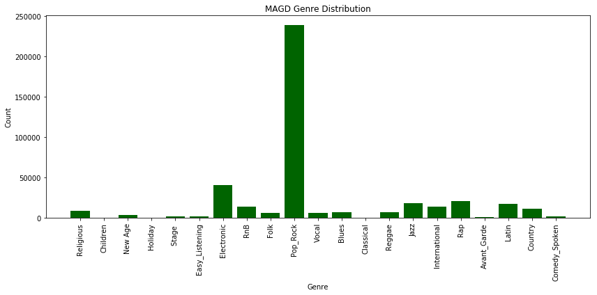

```python
# counts for each genre
genre_counts = genreAssignment_df.groupBy("genre").count().toPandas()

# histgram
plt.figure(figsize=(12, 6))
plt.bar(genre_counts["genre"], genre_counts["count"], color='darkgreen')
plt.xlabel("Genre")
plt.ylabel("Count")
plt.title("MAGD Genre Distribution")
plt.xticks(rotation=90)  # rotation of xticks
plt.tight_layout()
```

```python
data = data.withColumnRenamed("MSD_TRACKID", "track_id")
data = data.withColumn("track_id", regexp_replace("track_id", "^'|'$", ""))
data.show(20)
```

```
+----------------------------------------------+------------------------------------------+----------------------------------------+-------------------------------------------------+---------------------------------------------+-----------------------------------------------------------+------------…
|Spectral_Centroid_Overall_Standard_Deviation_1|Spectral_Flux_Overall_Standard_Deviation_1|Compactness_Overall_Standard_Deviation_1|Spectral_Variability_Overall_Standard_Deviation_1|Root_Mean_Square_Overall_Standard_Deviation_1|Fraction_Of_Low_Energy_Windows_Overall_Standard_Deviation_1|Spectral_Cen…
+----------------------------------------------+------------------------------------------+----------------------------------------+-------------------------------------------------+---------------------------------------------+-----------------------------------------------------------+------------…
|                                         3.934|                                  0.001261|                                   224.6|                                         0.001853|                                      0.07065|                                                    0.09409|            …
|                                         3.065|                                  1.675E-4|                                   211.9|                                          7.04E-4|                                      0.02538|                                                    0.06922|            …
|                                         5.253|                                  0.002695|                                   240.4|                                         0.002034|                                      0.07267|                                                    0.09032|            …
|                                         3.606|                                  0.004807|                                   199.5|                                         0.002019|                                      0.06403|                                                    0.06092|            …
|                                         8.946|                                  5.519E-4|                                   281.0|                                         0.001121|                                      0.03933|                                                    0.05648|            …
|                                         1.981|                                  0.003836|                                   200.0|                                         0.002159|                                       0.0675|                                                    0.07067|            …
|                                         10.71|                                  0.001908|                                   241.4|                                         0.002018|                                      0.06659|                                                     0.0585|            …
|                                         6.656|                                  0.001208|                                   193.7|                                         0.001063|                                       0.0375|                                                    0.05849|            …
|                                         4.774|                                  0.003002|                                   201.9|                                         0.002044|                                      0.06857|                                                    0.05235|            …
|                                         1.439|                                  4.671E-4|                                   136.8|                                         0.001335|                                      0.04654|                                                    0.07119|            …
|                                         5.518|                                  5.808E-4|                                   262.7|                                         0.001265|                                      0.04597|                                                    0.07589|            …
|                                         17.52|                                  2.648E-4|                                   325.3|                                         8.904E-4|                                      0.03422|                                                    0.06156|            …
|                                         5.704|                                  0.006752|                                   212.3|                                         0.002988|                                      0.08973|                                                    0.04536|            …
```

[output cut: 9 more lines]

```python
genre_feature_df = data.join(genreAssignment_df, on="track_id", how="inner")
genre_feature_df.show(20, truncate = False)
```

```
+------------------+----------------------------------------------+------------------------------------------+----------------------------------------+-------------------------------------------------+---------------------------------------------+-----------------------------------------------------…
|track_id          |Spectral_Centroid_Overall_Standard_Deviation_1|Spectral_Flux_Overall_Standard_Deviation_1|Compactness_Overall_Standard_Deviation_1|Spectral_Variability_Overall_Standard_Deviation_1|Root_Mean_Square_Overall_Standard_Deviation_1|Fraction_Of_Low_Energy_Windows_Overall_Standard_Devia…
+------------------+----------------------------------------------+------------------------------------------+----------------------------------------+-------------------------------------------------+---------------------------------------------+-----------------------------------------------------…
|TRAAGTO128F1497E3C|5.699                                         |0.001236                                  |274.8                                   |0.001789                                         |0.06716                                      |0.08579                                              …
|TRAAMFF12903CE8107|3.267                                         |0.005098                                  |234.2                                   |0.002431                                         |0.07684                                      |0.07589                                              …
|TRAAUIH128F4254C9D|13.68                                         |0.004568                                  |253.5                                   |0.002828                                         |0.09537                                      |0.04466                                              …
|TRAAZNZ128F429EF86|2.151                                         |0.002339                                  |313.1                                   |0.001605                                         |0.05131                                      |0.1045                                               …
|TRAAZOZ12903C9CABF|9.105                                         |0.001464                                  |160.0                                   |0.001404                                         |0.05231                                      |0.04957                                              …
|TRABCWK128F42BBC0B|14.39                                         |0.003954                                  |164.6                                   |0.002357                                         |0.0809                                       |0.05017                                              …
|TRABGUX12903CD11FF|5.346                                         |8.369E-4                                  |195.9                                   |0.001113                                         |0.03719                                      |0.06847                                              …
|TRABHCK128F423E15A|4.2                                           |0.001214                                  |231.6                                   |0.001317                                         |0.04669                                      |0.05113                                              …
|TRABIRM128F92CA303|6.157                                         |0.004473                                  |181.4                                   |0.001872                                         |0.05868                                      |0.05181                                              …
|TRABMLM128F429BFA2|4.991                                         |1.92E-4                                   |232.4                                   |0.001848                                         |0.06943                                      |0.09764                                              …
|TRABMSR128F428E581|7.441                                         |0.003568                                  |228.5                                   |0.002321                                         |0.07705                                      |0.07081                                              …
|TRABNRG128F425E087|6.912                                         |1.234E-4                                  |258.2                                   |5.78E-4                                          |0.02213                                      |0.07667                                              …
|TRABPRT128F1495762|4.54                                          |0.002477                                  |200.9                                   |0.001736                                         |0.05743                                      |0.05802                                              …
```

[output cut: 9 more lines]

```python
row_count = genre_feature_df.count()
print(f"Total count of rows is {row_count}")
unique_track_count = genre_feature_df.select("track_id").distinct().count()
print("Number of unique track_id: ", unique_track_count)
```

```
Total count of rows is 420616
Number of unique track_id:  420616
```

### Binary classification "Electronic or not "

```python
data = genre_feature_df.withColumn("label", when(col("genre") == "Electronic", 1).otherwise(0))
data.show(20)
```

```
+------------------+----------------------------------------------+------------------------------------------+----------------------------------------+-------------------------------------------------+---------------------------------------------+-----------------------------------------------------…
|          track_id|Spectral_Centroid_Overall_Standard_Deviation_1|Spectral_Flux_Overall_Standard_Deviation_1|Compactness_Overall_Standard_Deviation_1|Spectral_Variability_Overall_Standard_Deviation_1|Root_Mean_Square_Overall_Standard_Deviation_1|Fraction_Of_Low_Energy_Windows_Overall_Standard_Devia…
+------------------+----------------------------------------------+------------------------------------------+----------------------------------------+-------------------------------------------------+---------------------------------------------+-----------------------------------------------------…
|TRAAGTO128F1497E3C|                                         5.699|                                  0.001236|                                   274.8|                                         0.001789|                                      0.06716|                                                    0…
|TRAAMFF12903CE8107|                                         3.267|                                  0.005098|                                   234.2|                                         0.002431|                                      0.07684|                                                    0…
|TRAAUIH128F4254C9D|                                         13.68|                                  0.004568|                                   253.5|                                         0.002828|                                      0.09537|                                                    0…
|TRAAZNZ128F429EF86|                                         2.151|                                  0.002339|                                   313.1|                                         0.001605|                                      0.05131|                                                     …
|TRAAZOZ12903C9CABF|                                         9.105|                                  0.001464|                                   160.0|                                         0.001404|                                      0.05231|                                                    0…
|TRABCWK128F42BBC0B|                                         14.39|                                  0.003954|                                   164.6|                                         0.002357|                                       0.0809|                                                    0…
|TRABGUX12903CD11FF|                                         5.346|                                  8.369E-4|                                   195.9|                                         0.001113|                                      0.03719|                                                    0…
|TRABHCK128F423E15A|                                           4.2|                                  0.001214|                                   231.6|                                         0.001317|                                      0.04669|                                                    0…
|TRABIRM128F92CA303|                                         6.157|                                  0.004473|                                   181.4|                                         0.001872|                                      0.05868|                                                    0…
|TRABMLM128F429BFA2|                                         4.991|                                   1.92E-4|                                   232.4|                                         0.001848|                                      0.06943|                                                    0…
|TRABMSR128F428E581|                                         7.441|                                  0.003568|                                   228.5|                                         0.002321|                                      0.07705|                                                    0…
|TRABNRG128F425E087|                                         6.912|                                  1.234E-4|                                   258.2|                                          5.78E-4|                                      0.02213|                                                    0…
|TRABPRT128F1495762|                                          4.54|                                  0.002477|                                   200.9|                                         0.001736|                                      0.05743|                                                    0…
```

[output cut: 9 more lines]

```python
# drop the genre and keep the label for binary classification
data = data.drop("genre")
data.show(20)
```

```
+------------------+----------------------------------------------+------------------------------------------+----------------------------------------+-------------------------------------------------+---------------------------------------------+-----------------------------------------------------…
|          track_id|Spectral_Centroid_Overall_Standard_Deviation_1|Spectral_Flux_Overall_Standard_Deviation_1|Compactness_Overall_Standard_Deviation_1|Spectral_Variability_Overall_Standard_Deviation_1|Root_Mean_Square_Overall_Standard_Deviation_1|Fraction_Of_Low_Energy_Windows_Overall_Standard_Devia…
+------------------+----------------------------------------------+------------------------------------------+----------------------------------------+-------------------------------------------------+---------------------------------------------+-----------------------------------------------------…
|TRAAGTO128F1497E3C|                                         5.699|                                  0.001236|                                   274.8|                                         0.001789|                                      0.06716|                                                    0…
|TRAAMFF12903CE8107|                                         3.267|                                  0.005098|                                   234.2|                                         0.002431|                                      0.07684|                                                    0…
|TRAAUIH128F4254C9D|                                         13.68|                                  0.004568|                                   253.5|                                         0.002828|                                      0.09537|                                                    0…
|TRAAZNZ128F429EF86|                                         2.151|                                  0.002339|                                   313.1|                                         0.001605|                                      0.05131|                                                     …
|TRAAZOZ12903C9CABF|                                         9.105|                                  0.001464|                                   160.0|                                         0.001404|                                      0.05231|                                                    0…
|TRABCWK128F42BBC0B|                                         14.39|                                  0.003954|                                   164.6|                                         0.002357|                                       0.0809|                                                    0…
|TRABGUX12903CD11FF|                                         5.346|                                  8.369E-4|                                   195.9|                                         0.001113|                                      0.03719|                                                    0…
|TRABHCK128F423E15A|                                           4.2|                                  0.001214|                                   231.6|                                         0.001317|                                      0.04669|                                                    0…
|TRABIRM128F92CA303|                                         6.157|                                  0.004473|                                   181.4|                                         0.001872|                                      0.05868|                                                    0…
|TRABMLM128F429BFA2|                                         4.991|                                   1.92E-4|                                   232.4|                                         0.001848|                                      0.06943|                                                    0…
|TRABMSR128F428E581|                                         7.441|                                  0.003568|                                   228.5|                                         0.002321|                                      0.07705|                                                    0…
|TRABNRG128F425E087|                                         6.912|                                  1.234E-4|                                   258.2|                                          5.78E-4|                                      0.02213|                                                    0…
|TRABPRT128F1495762|                                          4.54|                                  0.002477|                                   200.9|                                         0.001736|                                      0.05743|                                                    0…
```

[output cut: 9 more lines]

```python
# cache the dataframe

data.cache()

# Count rows
print(f'# rows = {data.count()}')
```

```
# rows = 420616
```

```python
# Compute class frequency

show_as_html(data.groupby('label').count())
```

|  | label | count |
| --- | --- | --- |
| 0 | 0 | 379951 |
| 1 | 1 | 40665 |

### Stratification sampling

```python
# Exact stratification using Window (binary, counts hard coded)

temp = (
    data
    .withColumn("id", F.monotonically_increasing_id())
    .withColumn("random", F.rand())  # random number between 0 and 1
    .withColumn(
        "row",
        F.row_number()  # row number in each class partition (start at 0, 1, ... for positive and separately for negative)
        .over(
            Window
            .partitionBy("label")
            .orderBy("random")
        )
    )
)

training = temp.where(
    ((F.col("label") == 0) & (F.col("row") < 379670 * 0.8)) |  # nP_actual = 379670
    ((F.col("label") == 1) & (F.col("row") < 40688  * 0.8))    # nN_actual = 40688
)
training.cache()

test = temp.join(training, on="id", how="left_anti")
test.cache()

training = training.drop("id", "random", "row")
test = test.drop("id", "random", "row")

print_class_balance(data, "data")
print_class_balance(training, "training")
print_class_balance(test, "test")
```

```
dataset: data
total:   420616
counts:
   label   count    ratio
0      0  379951  0.90332
1      1   40665  0.09668

dataset: training
total:   336285
counts:
   label   count     ratio
0      0  303735  0.903207
1      1   32550  0.096793

dataset: test
total:   84331
counts:
   label  count     ratio
0      0  76216  0.903772
1      1   8115  0.096228
```

```python
# Ensure datasets are cached

data.cache()
training.cache()
test.cache()
```

```
DataFrame[track_id: string, Spectral_Centroid_Overall_Standard_Deviation_1: double, Spectral_Flux_Overall_Standard_Deviation_1: double, Compactness_Overall_Standard_Deviation_1: double, Spectral_Variability_Overall_Standard_Deviation_1: double, Root_Mean_Square_Overall_Standard_Deviation_1: double, …
```

```python
# Downsampling on label 0

training_downsampled = (
    training
    .withColumn("random", F.rand())
    .where(
        ((F.col("label") == 1)) |
        ((F.col("label") == 0) & (F.col("random") < (60000 / 303735)))
    )
)
training_downsampled.cache()

print_class_balance(training_downsampled, "training (downsampled)")
```

```
dataset: training (downsampled)
total:   92655
counts:
   label  count     ratio
0      0  60105  0.648697
1      1  32550  0.351303
```

### Method 1: Logistical regression for binary classification

### No downsampling

```python
# logistic regression
lr = LogisticRegression(featuresCol='features', labelCol='label')
lr_model = lr.fit(training)
pred = lr_model.transform(test)
pred.cache()

print_metrics(pred)
```

```
metrics for custom threshold

threshold: 0.5

total:     84331

nP actual: 8115
nN actual: 76216

nP:        2190
nN:        82141

TP         1167
FP         1023
FN         6948
TN         75193

precision: 0.53287671
recall:    0.14380776
accuracy:  0.90547960

auroc:     0.80660510
```

### downsampling

```python
# logistic regression with downsampled training data

lr = LogisticRegression(featuresCol='features', labelCol='label')
lr_model = lr.fit(training_downsampled)
pred = lr_model.transform(test)
pred.cache()

print_metrics(pred)
```

```
metrics for custom threshold

threshold: 0.5

total:     84331

nP actual: 8115
nN actual: 76216

nP:        11475
nN:        72856

TP         4300
FP         7175
FN         3815
TN         69041

precision: 0.37472767
recall:    0.52988293
accuracy:  0.86968019

auroc:     0.81232500
```

### Method 2: Random forest

### No downsampling

```python
rf = RandomForestClassifier(featuresCol='features', labelCol='label')

rf_model = rf.fit(training)
pred = rf_model.transform(test)
pred.cache()

print_metrics(pred)
```

```
metrics for custom threshold

threshold: 0.5

total:     84331

nP actual: 8115
nN actual: 76216

nP:        333
nN:        83998

TP         242
FP         91
FN         7873
TN         76125

precision: 0.72672673
recall:    0.02982132
accuracy:  0.90556260

auroc:     0.73134600
```

### downsampling

```python
rf = RandomForestClassifier(featuresCol='features', labelCol='label')

rf_model = rf.fit(training_downsampled)
pred = rf_model.transform(test)
pred.cache()

print_metrics(pred)
```

```
metrics for custom threshold

threshold: 0.5

total:     84331

nP actual: 8115
nN actual: 76216

nP:        12063
nN:        72268

TP         3891
FP         8172
FN         4224
TN         68044

precision: 0.32255658
recall:    0.47948244
accuracy:  0.85300779

auroc:     0.78019165
```

### Method 3: SVM

### No downsampling

```python
svm = LinearSVC(featuresCol='features', labelCol='label')

svm_model = svm.fit(training)

svm_pred = svm_model.transform(test)

svm_pred.cache()

print_metrics(svm_pred)
```

```
metrics for custom threshold

threshold: 0.5

total:     84331

nP actual: 8115
nN actual: 76216

nP:        0
nN:        84331

TP         0
FP         0
FN         8115
TN         76216

precision: 0.00000000
recall:    0.00000000
accuracy:  0.90377204

auroc:     0.71982895
```

### downsampling

```python
svm = LinearSVC(featuresCol='features', labelCol='label')

svm_model = svm.fit(training_downsampled)

svm_pred = svm_model.transform(test)

svm_pred.cache()

print_metrics(svm_pred)
```

```
metrics for custom threshold

threshold: 0.5

total:     84331

nP actual: 8115
nN actual: 76216

nP:        11915
nN:        72416

TP         3850
FP         8065
FN         4265
TN         68151

precision: 0.32312211
recall:    0.47443007
accuracy:  0.85379042

auroc:     0.76731433
```

### hyperparamter tuning in Logstic Regression

```python
# Cross validation and hyperparameter tuning (Logistic Regression)

param_grid = (
    ParamGridBuilder()
    .addGrid(lr.regParam, [0.0, 0.1, 0.2])
    .addGrid(lr.elasticNetParam, [0.0, 0.1, 0.2])
    .build()
)
cross_validator = CrossValidator(
    estimator=lr,
    estimatorParamMaps=param_grid,
    evaluator=BinaryClassificationEvaluator(metricName='areaUnderROC'),
    numFolds=3,
)
cross_validator_model = cross_validator.fit(training_downsampled)
pred = cross_validator_model.transform(test)
pred.cache()

print(f'hyperparameters selected')
print(f'')
print(f'regParam:        {cross_validator_model.bestModel.getRegParam()}')
print(f'elasticNetParam: {cross_validator_model.bestModel.getElasticNetParam()}')
print(f'')
print_metrics(pred)
```

```
hyperparameters selected

regParam:        0.0
elasticNetParam: 0.1

metrics for custom threshold

threshold: 0.5

total:     84331

nP actual: 8115
nN actual: 76216

nP:        11817
nN:        72514

TP         4320
FP         7497
FN         3795
TN         68719

precision: 0.36557502
recall:    0.53234750
accuracy:  0.86609906

auroc:     0.80840520
```

### hyperparamter tuning in Random Forest

```python
param_grid = (
    ParamGridBuilder()
    .addGrid(rf.maxDepth, [5, 10])
    .addGrid(rf.numTrees, [20, 50])
    .build()
)


cross_validator = CrossValidator(estimator = rf,
                                 estimatorParamMaps = param_grid,
                                 evaluator = BinaryClassificationEvaluator(metricName='areaUnderROC'),
                                 numFolds = 2)


cross_validator_model = cross_validator.fit(training_downsampled)
pred = cross_validator_model.transform(test)
pred.cache()


print("Hyperparameters selected:")
print(f"Max Depth: {cross_validator_model.bestModel.getMaxDepth()}")
print(f"Number of Trees: {cross_validator_model.bestModel.getNumTrees}")
print("")

print_metrics(pred)
```

```
Hyperparameters selected:
Max Depth: 10
Number of Trees: 50

metrics for custom threshold

threshold: 0.5

total:     84331

nP actual: 8115
nN actual: 76216

nP:        13200
nN:        71131

TP         4640
FP         8560
FN         3475
TN         67656

precision: 0.35151515
recall:    0.57178065
accuracy:  0.85728854

auroc:     0.82583801
```

### hyperparamter tuning in SVM

```python
param_grid = (
    ParamGridBuilder()
    .addGrid(svm.maxIter, [10, 50])
    .addGrid(svm.regParam, [0.1, 0.01])
    .build()
)


cross_validator = CrossValidator(estimator = svm,
                                 estimatorParamMaps = param_grid,
                                 evaluator = BinaryClassificationEvaluator(metricName='areaUnderROC'),
                                 numFolds = 2 )

cross_validator_model = cross_validator.fit(training_downsampled)

pred = cross_validator_model.transform(test)
pred.cache()

print("Hyperparameters selected:")
print(f"Max Iterations: {cross_validator_model.bestModel.getMaxIter()}")
print(f"Regularization Parameter: {cross_validator_model.bestModel.getRegParam()}")
print("")

print_metrics(pred)
```

```
Hyperparameters selected:
Max Iterations: 50
Regularization Parameter: 0.01

metrics for custom threshold

threshold: 0.5

total:     84331

nP actual: 8115
nN actual: 76216

nP:        10538
nN:        73793

TP         3346
FP         7192
FN         4769
TN         69024

precision: 0.31751756
recall:    0.41232286
accuracy:  0.85816604

auroc:     0.74200089
```

### Multi-class prediction

Method Decision: logistic regression

```python
from pyspark.ml.feature import StringIndexer, OneHotEncoder
from pyspark.ml import Pipeline
```

```python
# generate genre labels

string_indexer = StringIndexer(inputCol="genre", outputCol="label")
model = string_indexer.fit(genre_feature_df)
data = model.transform(genre_feature_df)
data = data.withColumn("label", col("label").cast("integer"))
```

```python
data.show(20, truncate = False)
```

```
+------------------+----------------------------------------------+------------------------------------------+----------------------------------------+-------------------------------------------------+---------------------------------------------+-----------------------------------------------------…
|track_id          |Spectral_Centroid_Overall_Standard_Deviation_1|Spectral_Flux_Overall_Standard_Deviation_1|Compactness_Overall_Standard_Deviation_1|Spectral_Variability_Overall_Standard_Deviation_1|Root_Mean_Square_Overall_Standard_Deviation_1|Fraction_Of_Low_Energy_Windows_Overall_Standard_Devia…
+------------------+----------------------------------------------+------------------------------------------+----------------------------------------+-------------------------------------------------+---------------------------------------------+-----------------------------------------------------…
|TRAAGTO128F1497E3C|5.699                                         |0.001236                                  |274.8                                   |0.001789                                         |0.06716                                      |0.08579                                              …
|TRAAMFF12903CE8107|3.267                                         |0.005098                                  |234.2                                   |0.002431                                         |0.07684                                      |0.07589                                              …
|TRAAUIH128F4254C9D|13.68                                         |0.004568                                  |253.5                                   |0.002828                                         |0.09537                                      |0.04466                                              …
|TRAAZNZ128F429EF86|2.151                                         |0.002339                                  |313.1                                   |0.001605                                         |0.05131                                      |0.1045                                               …
|TRAAZOZ12903C9CABF|9.105                                         |0.001464                                  |160.0                                   |0.001404                                         |0.05231                                      |0.04957                                              …
|TRABCWK128F42BBC0B|14.39                                         |0.003954                                  |164.6                                   |0.002357                                         |0.0809                                       |0.05017                                              …
|TRABGUX12903CD11FF|5.346                                         |8.369E-4                                  |195.9                                   |0.001113                                         |0.03719                                      |0.06847                                              …
|TRABHCK128F423E15A|4.2                                           |0.001214                                  |231.6                                   |0.001317                                         |0.04669                                      |0.05113                                              …
|TRABIRM128F92CA303|6.157                                         |0.004473                                  |181.4                                   |0.001872                                         |0.05868                                      |0.05181                                              …
|TRABMLM128F429BFA2|4.991                                         |1.92E-4                                   |232.4                                   |0.001848                                         |0.06943                                      |0.09764                                              …
|TRABMSR128F428E581|7.441                                         |0.003568                                  |228.5                                   |0.002321                                         |0.07705                                      |0.07081                                              …
|TRABNRG128F425E087|6.912                                         |1.234E-4                                  |258.2                                   |5.78E-4                                          |0.02213                                      |0.07667                                              …
|TRABPRT128F1495762|4.54                                          |0.002477                                  |200.9                                   |0.001736                                         |0.05743                                      |0.05802                                              …
```

[output cut: 9 more lines]

```python
# cache the dataframe

data.cache()

# Count rows
print(f'# rows = {data.count()}')
```

```
# rows = 420616
```

```python
# Compute class frequency

show_as_html(data.groupby('label').count(), n = 30)
```

|  | label | count |
| --- | --- | --- |
| 0 | 13 | 4000 |
| 1 | 14 | 2067 |
| 2 | 11 | 6182 |
| 3 | 7 | 11689 |
| 4 | 0 | 237649 |
| 5 | 8 | 8780 |
| 6 | 5 | 14314 |
| 7 | 2 | 20899 |
| 8 | 17 | 1012 |
| 9 | 15 | 1613 |
| 10 | 19 | 463 |
| 11 | 12 | 5789 |
| 12 | 18 | 555 |
| 13 | 10 | 6801 |
| 14 | 1 | 40665 |
| 15 | 3 | 17774 |
| 16 | 20 | 200 |
| 17 | 6 | 14194 |
| 18 | 9 | 6931 |
| 19 | 16 | 1535 |
| 20 | 4 | 17504 |

### stratification sampling on multi-class

```python
# Exact stratification using Window (multi-class, counts computed on the fly)

temp = (
    data
    .withColumn("id", F.monotonically_increasing_id())
    .withColumn("random", F.rand())  # random number between 0 and 1
    .withColumn(
        "row",
        F.row_number()  # row number in each class partition (start at 0, 1, ... for positive and separately for negative)
        .over(
            Window
            .partitionBy("label")
            .orderBy("random")
        )
    )
)

counts = (
    data
    .groupBy("label")
    .count()
    .toPandas()
    .set_index("label")["count"]
    .to_dict()
)
labels = sorted(counts.keys())

print(counts)

training = temp
for label in labels:
    training = training.where((F.col("label") != label) | (F.col("row") < counts[label] * 0.8))

training.cache()

test = temp.join(training, on="id", how="left_anti")
test.cache()

training = training.drop("id", "random", "row")
test = test.drop("id", "random", "row")

print_class_balance(data, "data")
print_class_balance(training, "training")
print_class_balance(test, "test")
```

```
{13: 4000, 14: 2067, 11: 6182, 7: 11689, 0: 237649, 8: 8780, 5: 14314, 2: 20899, 17: 1012, 15: 1613, 19: 463, 12: 5789, 18: 555, 10: 6801, 3: 17774, 1: 40665, 20: 200, 9: 6931, 6: 14194, 16: 1535, 4: 17504}
dataset: data
total:   420616
counts:
    label   count     ratio
0      13    4000  0.009510
1      14    2067  0.004914
2      11    6182  0.014697
3       7   11689  0.027790
4       0  237649  0.565002
5       8    8780  0.020874
6       5   14314  0.034031
7       2   20899  0.049687
8      17    1012  0.002406
9      15    1613  0.003835
```

[output cut: 63 more lines]

```python
# Ensure datasets are cached

data.cache()
training.cache()
test.cache()
```

### reweighting

```python
# Observation reweighting

training_weighted = training.withColumn(
    "weight",
    F.when(F.col("label").isin(18, 19, 20), 100.0)
    .when(F.col("label").isin(0), 1.0)
    .otherwise(50.0)
)

weights = (
    training_weighted
    .groupBy("label")
    .agg(
        F.collect_set(F.col("weight")).alias("weights")
    )
    .toPandas()
)
print(weights)

print_class_balance(training_weighted, "training (weighted)")
```

```
    label  weights
0      13   [50.0]
1      14   [50.0]
2       7   [50.0]
3      11   [50.0]
4       0    [1.0]
5       8   [50.0]
6       5   [50.0]
7       2   [50.0]
8      17   [50.0]
9      15   [50.0]
10     19  [100.0]
11     12   [50.0]
12     18  [100.0]
13     10   [50.0]
```

[output cut: 32 more lines]

```python
# mutli-class regression

lr = LogisticRegression(featuresCol='features', labelCol='label', weightCol="weight")
lr_model = lr.fit(training_weighted)
pred = lr_model.transform(test)
pred.cache()
```

```
DataFrame[track_id: string, Spectral_Centroid_Overall_Standard_Deviation_1: double, Spectral_Flux_Overall_Standard_Deviation_1: double, Compactness_Overall_Standard_Deviation_1: double, Spectral_Variability_Overall_Standard_Deviation_1: double, Root_Mean_Square_Overall_Standard_Deviation_1: double, …
```

```python
# evaluation the multi-class prediction accuracy

evaluator = MulticlassClassificationEvaluator(labelCol="label", predictionCol="prediction", metricName="accuracy")

accuracy = evaluator.evaluate(pred)

print("Accuracy: {:.2f}%".format(accuracy * 100))
```

```
Accuracy: 18.61%
```

### Song recommendations

```python
# repartition the triplets_df

data = triplets_df.repartition(partitions)

data.cache()

data.printSchema()

show_as_html(data)
```

```
root
 |-- user_id: string (nullable = true)
 |-- song_id: string (nullable = true)
 |-- count: string (nullable = true)
```

|  | user_id | song_id | count |
| --- | --- | --- | --- |
| 0 | 51f363cb4b07ee8bed3bd2cacf40f504f3edf656 | SOUANOU12A81C21E5F | 2 |
| 1 | 3dde1238acf73bafc78802d4e3c78685e013ded9 | SOIEBXT12A8C1341E1 | 2 |
| 2 | c2e6e35e4bc5f2f95be9101cba11f0286caa7dcc | SOMTRQJ12A8C132B88 | 2 |
| 3 | bfd1704f2f0b021c53768b10d98800db7e9289ae | SOQLHFS12B35058AB4 | 1 |
| 4 | e18bd0ba9ab3cf1003682c41addab775a7501d8f | SOIVBTY12A8C13A505 | 9 |
| 5 | 718e67af20935e5ba85e28aab589f972477d7c85 | SOWNJYY12A81C20010 | 4 |
| 6 | f8b1506b4498eea7241f0fef975ae290cbb741ca | SOXXROE12B0B8079F6 | 1 |
| 7 | d88e77aa83b87151f62d5187680dbe0c73686b3e | SOPKPUK12A8C13CAED | 1 |
| 8 | 3159061498da3dd9a903e27d7568a1eae00d23a1 | SOBXOWJ12A6D4F85BA | 1 |
| 9 | d83840b6eb4a6c9e5fff488bbc6d69ad426fba62 | SOJBWKA12A58A7AFBD | 6 |
| 10 | 9c6ebf1d5ba38bcb577149b22e19448f655f6252 | SOCALRI12A58A7BBC5 | 24 |
| 11 | fc1ffad26e87b5c39d5353c0796bcb1a62321fe1 | SOWPASM12A8C142B88 | 4 |
| 12 | 9e06ebf2b50b369814a5832a9fd89f907c5e8dd2 | SOODOOU12A8C135054 | 1 |
| 13 | 481622800693743019c97fac028bbec1be3e3256 | SODGJKH12AAA8C9487 | 1 |
| 14 | 5ed78e777b718caf9e3bbed459fa5ae83d5f7a25 | SOUPCXQ12A81C222D9 | 3 |
| 15 | c6f9e0f7e247c8ccac65c3e2d5c4d0fd49e12d93 | SOXYIVW12A58A79989 | 1 |
| 16 | 205b1948f2f5da81a0d0ca9b0cd9261f87de1cf9 | SOROQGG12AB017F628 | 14 |
| 17 | 7b43b131dd00e0755fcbb7643120bd5287374963 | SOKRAMY12A8C140804 | 1 |
| 18 | 436b31459ec8d8480cd2572fd75c3f77c7212efa | SOYJYFW12A8C130E52 | 1 |
| 19 | b995f4eab54ea7b51093a478aab316c00c960a61 | SOYNYVR12A8C13E0BE | 1 |

```python
# count the unique songs
unique_songs_count = data.select("song_id").distinct().count()

print("Number of unique songs:", unique_songs_count)
```

```
Number of unique songs: 384546
```

```python
# count the unique user
unique_users_count = data.select("user_id").distinct().count()

print("Number of unique users:", unique_users_count)
```

```
Number of unique users: 1019318
```

```python
# make sure the count is int type

data = data.withColumn("count", col("count").cast("int"))
data.show()
```

```
+--------------------+------------------+-----+
|             user_id|           song_id|count|
+--------------------+------------------+-----+
|51f363cb4b07ee8be...|SOUANOU12A81C21E5F|    2|
|3dde1238acf73bafc...|SOIEBXT12A8C1341E1|    2|
|c2e6e35e4bc5f2f95...|SOMTRQJ12A8C132B88|    2|
|bfd1704f2f0b021c5...|SOQLHFS12B35058AB4|    1|
|e18bd0ba9ab3cf100...|SOIVBTY12A8C13A505|    9|
|718e67af20935e5ba...|SOWNJYY12A81C20010|    4|
|f8b1506b4498eea72...|SOXXROE12B0B8079F6|    1|
|d88e77aa83b87151f...|SOPKPUK12A8C13CAED|    1|
|3159061498da3dd9a...|SOBXOWJ12A6D4F85BA|    1|
|d83840b6eb4a6c9e5...|SOJBWKA12A58A7AFBD|    6|
|9c6ebf1d5ba38bcb5...|SOCALRI12A58A7BBC5|   24|
|fc1ffad26e87b5c39...|SOWPASM12A8C142B88|    4|
|9e06ebf2b50b36981...|SOODOOU12A8C135054|    1|
|48162280069374301...|SODGJKH12AAA8C9487|    1|
|5ed78e777b718caf9...|SOUPCXQ12A81C222D9|    3|
|c6f9e0f7e247c8cca...|SOXYIVW12A58A79989|    1|
|205b1948f2f5da81a...|SOROQGG12AB017F628|   14|
|7b43b131dd00e0755...|SOKRAMY12A8C140804|    1|
|436b31459ec8d8480...|SOYJYFW12A8C130E52|    1|
|b995f4eab54ea7b51...|SOYNYVR12A8C13E0BE|    1|
+--------------------+------------------+-----+
only showing top 20 rows
```

```python
# find the unique songs played by most active user

most_active_user = data.groupBy("user_id").sum("count").orderBy(col("sum(count)").desc()).first()["user_id"]

unique_songs = data.filter(col("user_id") == most_active_user).select("song_id").distinct().count()

print("Number of different songs played by the most active user:", unique_songs)
```

```
Number of different songs played by the most active user: 202
```

```python
# percentage of unique songs

total_songs_count = data.select("song_id").count()

unique_song_percentage = (unique_songs_count / total_songs_count) * 100

print(f"Percentage of unique songs of total number of songs: {unique_song_percentage:.3f}%")
```

```
Percentage of unique songs of total number of songs: 0.795%
```

### Visualize the distribution

```python
# count the play times for each song

song_play_counts = data.groupBy("song_id").sum("count").withColumnRenamed("sum(count)", "play_count").toPandas()

# count the play times for each user
user_play_counts = data.groupBy("user_id").sum("count").withColumnRenamed("sum(count)", "play_count").toPandas()
```

```python
statistics = song_play_counts["play_count"].describe()

print(statistics)
```

```
count    384546.000000
mean        360.633690
std        3256.809395
min           1.000000
25%           8.000000
50%          32.000000
75%         133.000000
max      726885.000000
Name: play_count, dtype: float64
```

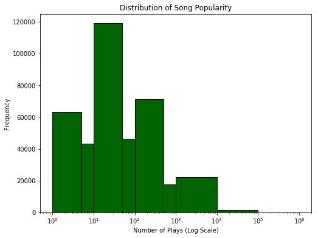

```python
# distribution of song play times
plt.figure(figsize=(8, 6))

bins = [1, 5, 10, 50, 100, 500, 1000, 10000, 100000, 1000000]

plt.hist(song_play_counts["play_count"], bins=bins, color='darkgreen', edgecolor='black')
plt.xscale('log')
plt.title("Distribution of Song Popularity")
plt.xlabel("Number of Plays (Log Scale)")
plt.ylabel("Frequency")
plt.show()
```

```python
statistics = user_play_counts["play_count"].describe()

print(statistics)
```

```
count    1.019318e+06
mean     1.360520e+02
std      1.845255e+02
min      1.000000e+01
25%      3.400000e+01
50%      7.300000e+01
75%      1.630000e+02
max      1.313200e+04
Name: play_count, dtype: float64
```

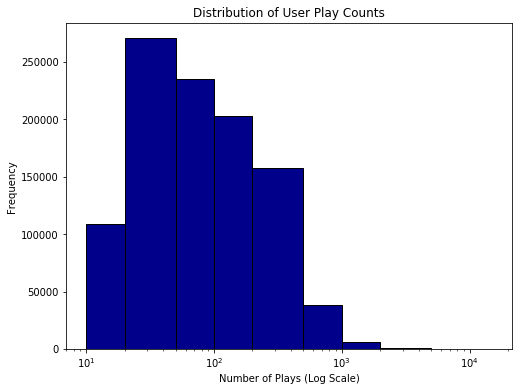

```python
plt.figure(figsize=(8, 6))

bins = [10, 20, 50, 100, 200, 500, 1000, 2000, 5000, 10000, 15000]

plt.hist(user_play_counts["play_count"], bins=bins, color='darkblue', edgecolor='black')
plt.xscale('log')
plt.title("Distribution of User Play Counts")
plt.xlabel("Number of Plays (Log Scale)")
plt.ylabel("Frequency")
plt.show()
```

```python
# Find the songs which is played >= N times
N = 10

song_play_counts = data.groupBy("song_id").agg(F.sum("count").alias("play_count"))

valid_songs = song_play_counts.filter(song_play_counts.play_count >= N).select("song_id").rdd.flatMap(lambda x: x).collect()
```

```python
# Find the users which is played >= M songs
M = 20

user_song_counts = data.groupBy("user_id").agg(F.countDistinct("song_id").alias("song_count"))

valid_users = user_song_counts.filter(user_song_counts.song_count >= M).select("user_id").rdd.flatMap(lambda x: x).collect()
```

```python
valid_songs_df = spark.createDataFrame([(song_id,) for song_id in valid_songs], ["song_id"])
valid_users_df = spark.createDataFrame([(user_id,) for user_id in valid_users], ["user_id"])

recommendation_df = data.join(valid_songs_df, "song_id", "inner").join(valid_users_df, "user_id", "inner")
```

```python
recommendation_df.show(50, truncate = False)
```

```
+----------------------------------------+------------------+-----+
|user_id                                 |song_id           |count|
+----------------------------------------+------------------+-----+
|00007f902e31b0693a023e9c234461d4e6991eec|SOODVNE12AB018D4EA|3    |
|00007f902e31b0693a023e9c234461d4e6991eec|SOGPBAW12A6D4F9F22|3    |
|00007f902e31b0693a023e9c234461d4e6991eec|SOSRJRK12AB0186FF4|1    |
|00007f902e31b0693a023e9c234461d4e6991eec|SOBKLTU12A58A7FB77|4    |
|00007f902e31b0693a023e9c234461d4e6991eec|SOOXPPN12AB0180907|14   |
|00007f902e31b0693a023e9c234461d4e6991eec|SOKKFVZ12A58A7A8B0|1    |
|00007f902e31b0693a023e9c234461d4e6991eec|SOWTZWQ12AB0188079|1    |
|00007f902e31b0693a023e9c234461d4e6991eec|SOPBPCY12AF72A827F|2    |
|00007f902e31b0693a023e9c234461d4e6991eec|SOAUUQZ12A6310E8C4|1    |
|00007f902e31b0693a023e9c234461d4e6991eec|SODIKCN12A8C144F32|2    |
|00007f902e31b0693a023e9c234461d4e6991eec|SOIGXKF12A6701E096|3    |
|00007f902e31b0693a023e9c234461d4e6991eec|SOLAIVS12A6D4FA40A|13   |
|00007f902e31b0693a023e9c234461d4e6991eec|SOMPFYJ12A6D4FC4FB|3    |
|00007f902e31b0693a023e9c234461d4e6991eec|SOITDGY12A8C1334DA|1    |
|00007f902e31b0693a023e9c234461d4e6991eec|SOPUDWU12A8AE4612A|1    |
|00007f902e31b0693a023e9c234461d4e6991eec|SOUUPZA12A8C136429|1    |
|00007f902e31b0693a023e9c234461d4e6991eec|SOWYYUQ12A6701D68D|11   |
|00007f902e31b0693a023e9c234461d4e6991eec|SOGTIXL12A6701C5D6|1    |
|00007f902e31b0693a023e9c234461d4e6991eec|SODZJCH12A8C132ADC|4    |
|00007f902e31b0693a023e9c234461d4e6991eec|SOTAVJH12A67020D8C|2    |
|00007f902e31b0693a023e9c234461d4e6991eec|SOTQUEC12AB01877F8|1    |
|0008320d84f011147fb4eb6afce9e4124ed8b7d5|SOXGMFD12A8C132B83|5    |
|0008320d84f011147fb4eb6afce9e4124ed8b7d5|SOEZFIG12AF729D52E|3    |
|0008320d84f011147fb4eb6afce9e4124ed8b7d5|SODKKNZ12A8C13E383|9    |
|0008320d84f011147fb4eb6afce9e4124ed8b7d5|SOOYIHH12AB018C2C7|1    |
|0008320d84f011147fb4eb6afce9e4124ed8b7d5|SOPWVUB12A8C1386EE|1    |
|0008320d84f011147fb4eb6afce9e4124ed8b7d5|SONQCMY12A6D4FB810|3    |
|0008320d84f011147fb4eb6afce9e4124ed8b7d5|SOVIEIL12A6D4F7D84|1    |
|0008320d84f011147fb4eb6afce9e4124ed8b7d5|SOIYQUA12A8AE46860|5    |
|0008320d84f011147fb4eb6afce9e4124ed8b7d5|SOIZFTE12AB0186842|4    |
|0008320d84f011147fb4eb6afce9e4124ed8b7d5|SOTLFEU12AB01885DB|4    |
|0008320d84f011147fb4eb6afce9e4124ed8b7d5|SOGNXXS12AB0184504|1    |
|0008320d84f011147fb4eb6afce9e4124ed8b7d5|SOHZPYD12AF72A12E2|1    |
|0008320d84f011147fb4eb6afce9e4124ed8b7d5|SOOHRZZ12A8C1334B8|5    |
|0008320d84f011147fb4eb6afce9e4124ed8b7d5|SOPJLOZ12A8C132642|1    |
|0008320d84f011147fb4eb6afce9e4124ed8b7d5|SOBNZTU12AB0188907|9    |
|0008320d84f011147fb4eb6afce9e4124ed8b7d5|SOBYXSO12AB0180014|5    |
|0008320d84f011147fb4eb6afce9e4124ed8b7d5|SOCDTEX12AB017CA4D|1    |
|0008320d84f011147fb4eb6afce9e4124ed8b7d5|SONXXJJ12AAF3B3A9B|2    |
|0008320d84f011147fb4eb6afce9e4124ed8b7d5|SOHCWEJ12A8C13EBD9|1    |
|0008320d84f011147fb4eb6afce9e4124ed8b7d5|SOOBMLO12A8C13B7B6|5    |
|0008320d84f011147fb4eb6afce9e4124ed8b7d5|SOXLOQG12AF72A2D55|2    |
|0008320d84f011147fb4eb6afce9e4124ed8b7d5|SODWUCN12A6701D259|5    |
|0008320d84f011147fb4eb6afce9e4124ed8b7d5|SOIHGCE12A8C134A3E|5    |
|0008320d84f011147fb4eb6afce9e4124ed8b7d5|SOMQSOC12A8C133BED|9    |
|0008320d84f011147fb4eb6afce9e4124ed8b7d5|SOZLLTY12A8C132D24|1    |
|0008320d84f011147fb4eb6afce9e4124ed8b7d5|SOBKRRI12A8C135DC5|5    |
|0008320d84f011147fb4eb6afce9e4124ed8b7d5|SOGEJKA12A58A7D3A8|15   |
|0008320d84f011147fb4eb6afce9e4124ed8b7d5|SOOFGCG12A6D4FD712|1    |
|0008320d84f011147fb4eb6afce9e4124ed8b7d5|SOBPHXV12A6D4F9FD0|6    |
+----------------------------------------+------------------+-----+
only showing top 50 rows
```

```python
# count the rows

row_counts = recommendation_df.count()

print(row_counts)
```

```
43132509
```

```python
data = recommendation_df
data = data.withColumn("count", col("count").cast("int"))
data.cache()
```

```
DataFrame[user_id: string, song_id: string, count: int]
```

```python
# Simple random splitting

training, test = data.randomSplit([0.7, 0.3])    # without caching below, randomSplit is rerun every time you do something

training.cache()
test.cache()

show_as_html(training)
show_as_html(test)
```

|  | user_id | song_id | count |
| --- | --- | --- | --- |
| 0 | 00007f902e31b0693a023e9c234461d4e6991eec | SOAUUQZ12A6310E8C4 | 1 |
| 1 | 00007f902e31b0693a023e9c234461d4e6991eec | SOBKLTU12A58A7FB77 | 4 |
| 2 | 00007f902e31b0693a023e9c234461d4e6991eec | SODIKCN12A8C144F32 | 2 |
| 3 | 00007f902e31b0693a023e9c234461d4e6991eec | SODZJCH12A8C132ADC | 4 |
| 4 | 00007f902e31b0693a023e9c234461d4e6991eec | SOGPBAW12A6D4F9F22 | 3 |
| 5 | 00007f902e31b0693a023e9c234461d4e6991eec | SOGTIXL12A6701C5D6 | 1 |
| 6 | 00007f902e31b0693a023e9c234461d4e6991eec | SOIGXKF12A6701E096 | 3 |
| 7 | 00007f902e31b0693a023e9c234461d4e6991eec | SOITDGY12A8C1334DA | 1 |
| 8 | 00007f902e31b0693a023e9c234461d4e6991eec | SOKKFVZ12A58A7A8B0 | 1 |
| 9 | 00007f902e31b0693a023e9c234461d4e6991eec | SOLAIVS12A6D4FA40A | 13 |
| 10 | 00007f902e31b0693a023e9c234461d4e6991eec | SOODVNE12AB018D4EA | 3 |
| 11 | 00007f902e31b0693a023e9c234461d4e6991eec | SOPBPCY12AF72A827F | 2 |
| 12 | 00007f902e31b0693a023e9c234461d4e6991eec | SOPUDWU12A8AE4612A | 1 |
| 13 | 00007f902e31b0693a023e9c234461d4e6991eec | SOSRJRK12AB0186FF4 | 1 |
| 14 | 00007f902e31b0693a023e9c234461d4e6991eec | SOTAVJH12A67020D8C | 2 |
| 15 | 00007f902e31b0693a023e9c234461d4e6991eec | SOTQUEC12AB01877F8 | 1 |
| 16 | 00007f902e31b0693a023e9c234461d4e6991eec | SOWTZWQ12AB0188079 | 1 |
| 17 | 00007f902e31b0693a023e9c234461d4e6991eec | SOWYYUQ12A6701D68D | 11 |
| 18 | 0008320d84f011147fb4eb6afce9e4124ed8b7d5 | SOBKRRI12A8C135DC5 | 5 |
| 19 | 0008320d84f011147fb4eb6afce9e4124ed8b7d5 | SOBNZTU12AB0188907 | 9 |

|  | user_id | song_id | count |
| --- | --- | --- | --- |
| 0 | 00007f902e31b0693a023e9c234461d4e6991eec | SOMPFYJ12A6D4FC4FB | 3 |
| 1 | 00007f902e31b0693a023e9c234461d4e6991eec | SOOXPPN12AB0180907 | 14 |
| 2 | 00007f902e31b0693a023e9c234461d4e6991eec | SOUUPZA12A8C136429 | 1 |
| 3 | 0008320d84f011147fb4eb6afce9e4124ed8b7d5 | SODWUCN12A6701D259 | 5 |
| 4 | 0008320d84f011147fb4eb6afce9e4124ed8b7d5 | SOEZFIG12AF729D52E | 3 |
| 5 | 0008320d84f011147fb4eb6afce9e4124ed8b7d5 | SOGEJKA12A58A7D3A8 | 15 |
| 6 | 0008320d84f011147fb4eb6afce9e4124ed8b7d5 | SOHCWEJ12A8C13EBD9 | 1 |
| 7 | 0008320d84f011147fb4eb6afce9e4124ed8b7d5 | SOHZPYD12AF72A12E2 | 1 |
| 8 | 0008320d84f011147fb4eb6afce9e4124ed8b7d5 | SOIHGCE12A8C134A3E | 5 |
| 9 | 0008320d84f011147fb4eb6afce9e4124ed8b7d5 | SOIZFTE12AB0186842 | 4 |
| 10 | 0008320d84f011147fb4eb6afce9e4124ed8b7d5 | SONXXJJ12AAF3B3A9B | 2 |
| 11 | 0008320d84f011147fb4eb6afce9e4124ed8b7d5 | SOOFGCG12A6D4FD712 | 1 |
| 12 | 0008320d84f011147fb4eb6afce9e4124ed8b7d5 | SOOYIHH12AB018C2C7 | 1 |
| 13 | 0008320d84f011147fb4eb6afce9e4124ed8b7d5 | SOPWVUB12A8C1386EE | 1 |
| 14 | 0008320d84f011147fb4eb6afce9e4124ed8b7d5 | SOVMWUC12A8C13750B | 3 |
| 15 | 0008320d84f011147fb4eb6afce9e4124ed8b7d5 | SOXLOQG12AF72A2D55 | 2 |
| 16 | 0008320d84f011147fb4eb6afce9e4124ed8b7d5 | SOZLLTY12A8C132D24 | 1 |
| 17 | 000f295d2b9ddd4ed0bfe674f010dbc4376270f7 | SOASKBC12A6D4F9910 | 4 |
| 18 | 000f295d2b9ddd4ed0bfe674f010dbc4376270f7 | SOGGSFE12A6D4F9912 | 1 |
| 19 | 000f295d2b9ddd4ed0bfe674f010dbc4376270f7 | SOHECBR12A8C136FDA | 1 |

```python
# find users of training dataset
training_users = set(training.select(col("user_id")).distinct().rdd.flatMap(lambda x: x).collect())

# find the users of test dataset
test_users = set(test.select(col("user_id")).distinct().rdd.flatMap(lambda x: x).collect())
```

```python
# common users in training and test
common_users = training_users.intersection(test_users)

# find the users with all record in training dataset
users_to_reallocate_to_test = list(training_users - common_users)

# find the users with all record in test dataset
users_to_reallocate_to_training = list(test_users - common_users)
```

```python
print (len(users_to_reallocate_to_test))
print (len(users_to_reallocate_to_training))
```

```
60
0
```

```python
# relocate those users with split ratio 0.7:0.3

for user in users_to_reallocate_to_test:
    user_records = data.filter(data['user_id'] == user)
    num_records_to_move = int(0.3 * user_records.count())
    records_to_move = user_records.limit(num_records_to_move)
    test = test.union(records_to_move)
    training = training.subtract(records_to_move)

for user in users_to_reallocate_to_training:
    user_records = data.filter(data['user_id'] == user)
    num_records_to_move = int(0.7 * user_records.count())
    records_to_move = user_records.limit(num_records_to_move)
    training = training.union(records_to_move)
    test = test.subtract(records_to_move)
```

```python
# cache the traing and test dataset
training.cache()
test.cache()

# display
training.show(20)
test.show(20)
```

```
+--------------------+------------------+-----+
|             user_id|           song_id|count|
+--------------------+------------------+-----+
|00007f902e31b0693...|SOAUUQZ12A6310E8C4|    1|
|00007f902e31b0693...|SOBKLTU12A58A7FB77|    4|
|00007f902e31b0693...|SODIKCN12A8C144F32|    2|
|00007f902e31b0693...|SODZJCH12A8C132ADC|    4|
|00007f902e31b0693...|SOGPBAW12A6D4F9F22|    3|
|00007f902e31b0693...|SOGTIXL12A6701C5D6|    1|
|00007f902e31b0693...|SOIGXKF12A6701E096|    3|
|00007f902e31b0693...|SOITDGY12A8C1334DA|    1|
|00007f902e31b0693...|SOKKFVZ12A58A7A8B0|    1|
|00007f902e31b0693...|SOLAIVS12A6D4FA40A|   13|
|00007f902e31b0693...|SOODVNE12AB018D4EA|    3|
|00007f902e31b0693...|SOPBPCY12AF72A827F|    2|
|00007f902e31b0693...|SOPUDWU12A8AE4612A|    1|
|00007f902e31b0693...|SOSRJRK12AB0186FF4|    1|
|00007f902e31b0693...|SOTAVJH12A67020D8C|    2|
|00007f902e31b0693...|SOTQUEC12AB01877F8|    1|
|00007f902e31b0693...|SOWTZWQ12AB0188079|    1|
|00007f902e31b0693...|SOWYYUQ12A6701D68D|   11|
|0008320d84f011147...|SOBKRRI12A8C135DC5|    5|
|0008320d84f011147...|SOBNZTU12AB0188907|    9|
+--------------------+------------------+-----+
only showing top 20 rows

+--------------------+------------------+-----+
|             user_id|           song_id|count|
+--------------------+------------------+-----+
|00007f902e31b0693...|SOMPFYJ12A6D4FC4FB|    3|
|00007f902e31b0693...|SOOXPPN12AB0180907|   14|
|00007f902e31b0693...|SOUUPZA12A8C136429|    1|
|0008320d84f011147...|SODWUCN12A6701D259|    5|
|0008320d84f011147...|SOEZFIG12AF729D52E|    3|
|0008320d84f011147...|SOGEJKA12A58A7D3A8|   15|
|0008320d84f011147...|SOHCWEJ12A8C13EBD9|    1|
|0008320d84f011147...|SOHZPYD12AF72A12E2|    1|
|0008320d84f011147...|SOIHGCE12A8C134A3E|    5|
|0008320d84f011147...|SOIZFTE12AB0186842|    4|
|0008320d84f011147...|SONXXJJ12AAF3B3A9B|    2|
|0008320d84f011147...|SOOFGCG12A6D4FD712|    1|
|0008320d84f011147...|SOOYIHH12AB018C2C7|    1|
|0008320d84f011147...|SOPWVUB12A8C1386EE|    1|
|0008320d84f011147...|SOVMWUC12A8C13750B|    3|
|0008320d84f011147...|SOXLOQG12AF72A2D55|    2|
|0008320d84f011147...|SOZLLTY12A8C132D24|    1|
|000f295d2b9ddd4ed...|SOASKBC12A6D4F9910|    4|
|000f295d2b9ddd4ed...|SOGGSFE12A6D4F9912|    1|
|000f295d2b9ddd4ed...|SOHECBR12A8C136FDA|    1|
+--------------------+------------------+-----+
only showing top 20 rows
```

```python
# Count rows

print(f'# training rows = {training.count()}')
print(f'# test rows     = {test.count()}')
```

```
# training rows = 30190348
# test rows     = 12942161
```

### Training the ALS Model

```python
from pyspark.ml.feature import StringIndexer

user_indexer = StringIndexer(inputCol="user_id", outputCol="user_index")
song_indexer = StringIndexer(inputCol="song_id", outputCol="song_index")

# transfrom in training dataset
training = user_indexer.fit(training).transform(training)
training = song_indexer.fit(training).transform(training)

# transfrom in test dataset
test = user_indexer.fit(test).transform(test)
test = song_indexer.fit(test).transform(test)
```

```python
# Training

als = ALS(maxIter=5, regParam=0.01, userCol="user_index", itemCol="song_index", ratingCol="count", implicitPrefs=True)

alsModel = als.fit(training)
```

```python
# Predict relevance scores

pred = alsModel.transform(test)
pred.cache()

pred.printSchema()
show_as_html(pred)
```

```
root
 |-- user_id: string (nullable = true)
 |-- song_id: string (nullable = true)
 |-- count: integer (nullable = true)
 |-- user_index: double (nullable = false)
 |-- song_index: double (nullable = false)
 |-- prediction: float (nullable = false)
```

|  | user_id | song_id | count | user_index | song_index | prediction |
| --- | --- | --- | --- | --- | --- | --- |
| 0 | b7032f457c624e23113c39b2f9c444a961c3fdf8 | SOTWSXL12A8C143349 | 1 | 357.0 | 38.0 | 0.137374 |
| 1 | b773e33a20b72a8a62e8cdfb322a26a43add82ff | SOTWSXL12A8C143349 | 1 | 433.0 | 38.0 | 0.110532 |
| 2 | dae08b6f200be684168b34d6aae3d518f4c5d142 | SOTWSXL12A8C143349 | 1 | 568.0 | 38.0 | 0.384151 |
| 3 | 556d875c3f572bbc0971e3144c6247bcfb549548 | SOTWSXL12A8C143349 | 4 | 9360.0 | 38.0 | -0.087932 |
| 4 | 9009438449dce09c7f3efcd8d9e334c8cf5355c1 | SOTWSXL12A8C143349 | 1 | 13224.0 | 38.0 | 0.084103 |
| 5 | aaec25d5c5480c44ed924ed935201f7238823b3f | SOTWSXL12A8C143349 | 3 | 13284.0 | 38.0 | 0.120848 |
| 6 | 8da995c4ea883a832af3e13d451cf7c0faaaeafb | SOTWSXL12A8C143349 | 3 | 14758.0 | 38.0 | -0.021641 |
| 7 | 5d74df91b8a956cce9f8a9866fb37eb6c3a3015c | SOTWSXL12A8C143349 | 9 | 16994.0 | 38.0 | 0.065519 |
| 8 | 631eb46e69c55be7bfac2b7f0000bdcc8516aff7 | SOTWSXL12A8C143349 | 9 | 17638.0 | 38.0 | 0.102418 |
| 9 | fcb30ebe068bac59c9e6cabebc60cb9262db30c5 | SOTWSXL12A8C143349 | 1 | 18044.0 | 38.0 | -0.006657 |
| 10 | 43109fe7f5b33964e14c846bd90302fc28bc2425 | SOTWSXL12A8C143349 | 6 | 18218.0 | 38.0 | 0.089827 |
| 11 | 233735a1892ea33a796caa59219fc7c0cbca4256 | SOTWSXL12A8C143349 | 4 | 23053.0 | 38.0 | 0.317343 |
| 12 | f14356ea53cb9e4f53ec5c0ce06b0549f389b933 | SOTWSXL12A8C143349 | 1 | 24818.0 | 38.0 | 0.096410 |
| 13 | 950366f3dafdecb72721e63eba417b749845eb3f | SOTWSXL12A8C143349 | 1 | 31546.0 | 38.0 | 0.220441 |
| 14 | ba1f236570c67b03dc1948b2c3352e6e8c7b4bcc | SOTWSXL12A8C143349 | 1 | 36213.0 | 38.0 | 0.014063 |
| 15 | daa71162ab115a3c9a0a6d5e52cc2b612c5ce163 | SOTWSXL12A8C143349 | 1 | 50095.0 | 38.0 | -0.151250 |
| 16 | 123d389e6f167457b96bb377d99cfd53b190d8c3 | SOTWSXL12A8C143349 | 1 | 50632.0 | 38.0 | 0.030988 |
| 17 | 35c734613a1518384be4e3d63b5fae389d7e5e01 | SOTWSXL12A8C143349 | 4 | 53413.0 | 38.0 | 0.018962 |
| 18 | b293f2c965a57b1e5a5b8caeb9e0bbf02edcced6 | SOTWSXL12A8C143349 | 2 | 54624.0 | 38.0 | 0.509147 |
| 19 | 5024b7ecdcf57acb135bf2ffc52898317cf8c4f5 | SOTWSXL12A8C143349 | 1 | 59092.0 | 38.0 | -0.006781 |

```python
# Generate recommendations

k = 10

recommendations = alsModel.recommendForAllUsers(k)

recommendations.printSchema()
show_as_html(recommendations)
```

```
root
 |-- user_index: integer (nullable = false)
 |-- recommendations: array (nullable = true)
 |    |-- element: struct (containsNull = true)
 |    |    |-- song_index: integer (nullable = true)
 |    |    |-- rating: float (nullable = true)
```

|  | user_index | recommendations |
| --- | --- | --- |
| 0 | 38 | [(14, 0.3646414577960968), (56, 0.329364776611... |
| 1 | 273 | [(98, 0.8197368383407593), (110, 0.80540001392... |
| 2 | 300 | [(25, 0.6561499238014221), (44, 0.580823063850... |
| 3 | 412 | [(0, 1.1001516580581665), (7, 1.07444334030151... |
| 4 | 434 | [(17, 1.1224370002746582), (49, 1.019694566726... |
| 5 | 475 | [(1, 0.7556081414222717), (56, 0.7033844590187... |
| 6 | 585 | [(98, 0.597981870174408), (38, 0.5866446495056... |
| 7 | 600 | [(1, 1.0522880554199219), (18, 0.9714754819869... |
| 8 | 611 | [(1, 1.1914269924163818), (0, 1.18688094615936... |
| 9 | 619 | [(56, 0.25393131375312805), (14, 0.24864549934... |
| 10 | 641 | [(0, 1.119318962097168), (17, 1.01899445056915... |
| 11 | 739 | [(14, 0.7787840366363525), (56, 0.657948672771... |
| 12 | 881 | [(193, 0.17932996153831482), (94, 0.1650038659... |
| 13 | 946 | [(7, 0.857631266117096), (0, 0.824989080429077... |
| 14 | 980 | [(17, 0.34518226981163025), (49, 0.30498906970... |
| 15 | 1021 | [(1, 0.8067954778671265), (59, 0.7360212802886... |
| 16 | 1092 | [(38, 0.5112833380699158), (26, 0.426221668720... |
| 17 | 1250 | [(0, 1.251996636390686), (1, 1.223566293716430... |
| 18 | 1384 | [(98, 0.7948839068412781), (101, 0.76645314693... |
| 19 | 1397 | [(17, 0.577569842338562), (49, 0.5079804658889... |

```python
recommendations.show(20, truncate = False)
```

```
+----------+---------------------------------------------------------------------------------------------------------------------------------------------------------------------------------------+
|user_index|recommendations                                                                                                                                                                        |
+----------+---------------------------------------------------------------------------------------------------------------------------------------------------------------------------------------+
|38        |[{14, 0.36464146}, {56, 0.32936478}, {1, 0.2875882}, {59, 0.28046647}, {110, 0.2780357}, {98, 0.26710752}, {9, 0.26133633}, {204, 0.26048976}, {91, 0.25239703}, {101, 0.24807158}]    |
|273       |[{98, 0.81973684}, {110, 0.8054}, {101, 0.802152}, {88, 0.7546554}, {14, 0.74599385}, {56, 0.678131}, {52, 0.67208725}, {204, 0.6635342}, {108, 0.6533619}, {38, 0.64326394}]          |
|300       |[{25, 0.6561499}, {44, 0.58082306}, {41, 0.57552844}, {10, 0.5618754}, {34, 0.5499225}, {53, 0.5475901}, {3, 0.5318165}, {79, 0.5087079}, {16, 0.5037182}, {19, 0.4950589}]            |
|412       |[{0, 1.1001517}, {7, 1.0744433}, {23, 0.94932246}, {42, 0.94626343}, {11, 0.9418571}, {24, 0.9296789}, {22, 0.9081128}, {6, 0.89116853}, {30, 0.8705672}, {47, 0.8586385}]             |
|434       |[{17, 1.122437}, {49, 1.0196946}, {26, 1.0151428}, {126, 0.90127826}, {24, 0.8558185}, {158, 0.8487692}, {140, 0.82698375}, {22, 0.8261929}, {89, 0.79221064}, {30, 0.7866392}]        |
|475       |[{1, 0.75560814}, {56, 0.70338446}, {14, 0.58646494}, {59, 0.53785163}, {72, 0.53713036}, {91, 0.53308535}, {204, 0.52600974}, {98, 0.52536124}, {168, 0.4953854}, {110, 0.492544}]    |
|585       |[{98, 0.59798187}, {38, 0.58664465}, {56, 0.58311254}, {110, 0.5760684}, {204, 0.56686574}, {101, 0.5665567}, {88, 0.54306996}, {14, 0.52948725}, {1, 0.5279403}, {91, 0.499119}]      |
|600       |[{1, 1.052288}, {18, 0.9714755}, {6, 0.9209782}, {12, 0.90671015}, {0, 0.9057148}, {10, 0.87944585}, {3, 0.8786726}, {7, 0.83159846}, {21, 0.8271779}, {25, 0.82486206}]               |
|611       |[{1, 1.191427}, {0, 1.186881}, {7, 1.1375381}, {10, 1.1345509}, {6, 1.1170682}, {3, 1.0722618}, {23, 1.0378311}, {11, 1.02983}, {21, 1.0151571}, {20, 0.9408822}]                      |
|619       |[{56, 0.2539313}, {14, 0.2486455}, {25, 0.22895865}, {59, 0.22512124}, {41, 0.22072706}, {91, 0.21401109}, {19, 0.20422924}, {1, 0.20097534}, {96, 0.19479878}, {34, 0.19273527}]      |
|641       |[{0, 1.119319}, {17, 1.0189945}, {24, 0.8769473}, {22, 0.85070616}, {3, 0.7952696}, {49, 0.791243}, {153, 0.7807319}, {55, 0.7451905}, {10, 0.73938197}, {9, 0.71992224}]              |
|739       |[{14, 0.77878404}, {56, 0.6579487}, {1, 0.61841476}, {59, 0.58409107}, {9, 0.55162984}, {41, 0.48859954}, {224, 0.45109797}, {139, 0.44717804}, {204, 0.44095618}, {80, 0.44083604}]   |
|881       |[{193, 0.17932996}, {94, 0.16500387}, {65, 0.15989457}, {71, 0.15882936}, {44, 0.15292864}, {125, 0.14791368}, {102, 0.14664598}, {122, 0.14664018}, {67, 0.14094053}, {8, 0.13876754}]|
|946       |[{7, 0.85763127}, {0, 0.8249891}, {6, 0.8177685}, {23, 0.78973085}, {11, 0.77947366}, {10, 0.74350584}, {30, 0.7066596}, {21, 0.704635}, {36, 0.70351005}, {1, 0.6926885}]             |
|980       |[{17, 0.34518227}, {49, 0.30498907}, {34, 0.2796989}, {76, 0.27553424}, {24, 0.27515173}, {25, 0.27152437}, {158, 0.27145457}, {50, 0.2705788}, {89, 0.26169983}, {22, 0.260763}]      |
|1021      |[{1, 0.8067955}, {59, 0.7360213}, {14, 0.6942668}, {56, 0.67303115}, {159, 0.5630516}, {110, 0.54137987}, {52, 0.5213356}, {40, 0.5203277}, {98, 0.51260084}, {376, 0.5045017}]        |
|1092      |[{38, 0.51128334}, {26, 0.42622167}, {158, 0.41997477}, {126, 0.37380058}, {155, 0.3724251}, {17, 0.3676766}, {9, 0.36323947}, {49, 0.34225515}, {85, 0.33928663}, {14, 0.33365136}]   |
|1250      |[{0, 1.2519966}, {1, 1.2235663}, {6, 1.1791492}, {7, 1.147354}, {3, 1.0722662}, {11, 1.0387467}, {23, 1.0138489}, {10, 0.97408205}, {20, 0.9716463}, {12, 0.96894467}]                 |
|1384      |[{98, 0.7948839}, {101, 0.76645315}, {110, 0.75246763}, {88, 0.7317437}, {1, 0.7308587}, {14, 0.7097515}, {56, 0.62270254}, {52, 0.59669775}, {40, 0.58713424}, {108, 0.5716728}]      |
|1397      |[{17, 0.57756984}, {49, 0.50798047}, {24, 0.45451945}, {22, 0.4438551}, {89, 0.4167756}, {19, 0.40669647}, {26, 0.40138718}, {16, 0.39962617}, {76, 0.39443824}, {207, 0.38692704}]    |
+----------+---------------------------------------------------------------------------------------------------------------------------------------------------------------------------------------+
only showing top 20 rows
```

### Evaluation Metrix

```python
# Collect and sort relevant items in order of descending relevance (e.g. rating)

relevant = (
    test
    .groupBy("user_index")
    .agg(
        F.reverse(F.sort_array(F.collect_list(
            F.struct(
                F.col("count"),
                F.col("song_index"),
            )
        ))).alias("relevant")
    )
)
```

```python
# Merge recommendations and relevant items so they can be compared

temp = (
    recommendations
    .select(
        F.col("user_index"),
        F.col("recommendations.song_index").alias("recommendations").astype(ArrayType(DoubleType())),
    )
    .join(
        relevant
        .select(
            F.col("user_index"),
            F.col("relevant.song_index").alias("relevant").astype(ArrayType(DoubleType())),
        ),
        on="user_index",
        how="inner"
    )
)
temp.cache()

temp.printSchema()
```

```
root
 |-- user_index: integer (nullable = false)
 |-- recommendations: array (nullable = true)
 |    |-- element: double (containsNull = true)
 |-- relevant: array (nullable = false)
 |    |-- element: double (containsNull = true)
```

```python
temp.show(20, truncate = False)
```

```
+----------+-------------------------------------------------------------------+----------------------------------------------------------------------------------------------------------------------------------------------------------------------------------------------------------------------------…
|user_index|recommendations                                                    |relevant                                                                                                                                                                                                                    …
+----------+-------------------------------------------------------------------+----------------------------------------------------------------------------------------------------------------------------------------------------------------------------------------------------------------------------…
|122       |[38.0, 14.0, 9.0, 85.0, 204.0, 155.0, 53.0, 41.0, 158.0, 50.0]     |[29144.0, 50623.0, 1573.0, 1189.0, 75.0, 48774.0, 13369.0, 10446.0, 1934.0, 632.0, 24112.0, 809.0, 555.0, 192980.0, 100333.0, 49154.0, 49072.0, 46436.0, 31412.0, 29935.0, 26963.0, 24907.0, 17634.0, 14962.0, 5982.0, 5774.…
|194       |[25.0, 172.0, 19.0, 41.0, 96.0, 16.0, 60.0, 57.0, 59.0, 18.0]      |[87657.0, 70733.0, 3721.0, 733.0, 7356.0, 49886.0, 45187.0, 38817.0, 34766.0, 31838.0, 28533.0, 10311.0, 9182.0, 8092.0, 7086.0, 4300.0, 3901.0, 2584.0, 2005.0, 38382.0, 20107.0, 3700.0, 61587.0, 24859.0, 13986.0, 4717.0…
|196       |[25.0, 207.0, 172.0, 295.0, 76.0, 19.0, 183.0, 152.0, 16.0, 96.0]  |[5418.0, 229.0, 655.0, 3027.0, 2436.0, 683.0, 140149.0, 17779.0, 5097.0, 2906.0, 1596.0, 569.0, 55.0, 3685.0, 2360.0, 1928.0, 1224.0, 1083.0, 398.0, 303.0, 209.0, 10.0, 3982.0, 2365.0, 2258.0, 1786.0, 1699.0, 1611.0, 139…
|215       |[17.0, 19.0, 26.0, 49.0, 16.0, 24.0, 22.0, 13.0, 89.0, 25.0]       |[110.0, 523.0, 483.0, 75.0, 5102.0, 894.0, 531.0, 464.0, 696.0, 14754.0, 7999.0, 5601.0, 873.0, 25023.0, 23648.0, 13485.0, 8898.0, 4118.0, 941.0, 43437.0, 130878.0, 37269.0, 17929.0, 10790.0, 8911.0, 7586.0, 6186.0, 6086…
|355       |[17.0, 163.0, 49.0, 9.0, 172.0, 89.0, 19.0, 353.0, 14.0, 153.0]    |[8964.0, 10743.0, 6664.0, 14288.0, 11209.0, 31028.0, 47272.0, 34514.0, 19113.0, 17598.0, 1333.0, 16392.0, 854.0, 212921.0, 38621.0, 32254.0, 16737.0, 107.0, 55909.0, 55600.0, 39881.0, 29938.0, 14892.0, 11867.0, 8166.0, 7…
|490       |[1.0, 56.0, 14.0, 19.0, 91.0, 13.0, 16.0, 41.0, 9.0, 10.0]         |[149.0, 31444.0, 684.0, 107.0, 131757.0, 85892.0, 30675.0, 17677.0, 15082.0, 11154.0, 1859.0, 1589.0, 208.0, 128.0, 56.0, 136228.0, 17078.0, 14628.0, 6652.0, 6047.0, 4052.0, 687.0, 257662.0, 238539.0, 236165.0, 160673.0,…
|496       |[204.0, 14.0, 56.0, 91.0, 38.0, 168.0, 41.0, 72.0, 1.0, 110.0]     |[37775.0, 107.0, 94487.0, 14330.0, 2619.0, 229312.0, 99500.0, 44147.0, 22760.0, 10036.0, 6041.0, 7214.0, 40055.0, 10027.0, 2878.0, 386.0, 157955.0, 93571.0, 61405.0, 42983.0, 30504.0, 26847.0, 24307.0, 22484.0, 12132.0, …
|497       |[14.0, 56.0, 204.0, 38.0, 172.0, 9.0, 41.0, 91.0, 224.0, 59.0]     |[8426.0, 1828.0, 858.0, 127245.0, 72041.0, 275.0, 44761.0, 4694.0, 3782.0, 2294.0, 175.0, 81822.0, 26217.0, 19295.0, 5771.0, 5157.0, 4151.0, 47.0, 130757.0, 82211.0, 69404.0, 30852.0, 27688.0, 21953.0, 11203.0, 8052.0, 7…
|523       |[25.0, 295.0, 172.0, 207.0, 76.0, 152.0, 96.0, 209.0, 183.0, 211.0]|[153.0, 17492.0, 3842.0, 187760.0, 131547.0, 16248.0, 2506.0, 2150.0, 214210.0, 167121.0, 47872.0, 264019.0, 183892.0, 180814.0, 53390.0, 38956.0, 16347.0, 13125.0, 6753.0, 244592.0, 239712.0, 213871.0, 204127.0, 199359.…
|530       |[14.0, 56.0, 41.0, 204.0, 91.0, 25.0, 168.0, 1.0, 9.0, 59.0]       |[1804.0, 417.0, 102770.0, 62491.0, 34749.0, 21982.0, 17155.0, 357.0, 228.0, 121448.0, 78641.0, 57238.0, 34183.0, 31973.0, 30237.0, 10494.0, 7846.0, 7157.0, 1877.0, 1780.0, 1080.0, 139321.0, 76456.0, 44912.0, 37179.0, 353…
|544       |[26.0, 0.0, 17.0, 7.0, 25.0, 9.0, 24.0, 22.0, 10.0, 30.0]          |[199320.0, 159404.0, 20925.0, 50503.0, 46626.0, 10017.0, 159877.0, 157170.0, 6165.0, 100222.0, 80076.0, 22798.0, 22425.0, 22310.0, 10080.0, 4697.0, 2706.0, 1731.0, 1088.0, 216484.0, 197766.0, 195512.0, 195067.0, 149478.0…
|574       |[25.0, 14.0, 96.0, 41.0, 172.0, 19.0, 295.0, 152.0, 34.0, 16.0]    |[6411.0, 2839.0, 116479.0, 91284.0, 6620.0, 13882.0, 11196.0, 291.0, 58894.0, 34223.0, 21761.0, 19834.0, 15199.0, 11988.0, 10687.0, 6520.0, 194008.0, 62050.0, 45126.0, 34267.0, 31414.0, 10166.0, 5988.0, 4153.0, 1540.0, 1…
|590       |[49.0, 172.0, 17.0, 100.0, 89.0, 353.0, 14.0, 128.0, 105.0, 9.0]   |[15983.0, 5672.0, 101.0, 32589.0, 19808.0, 18431.0, 11201.0, 10686.0, 10120.0, 461.0, 395.0, 36.0, 27972.0, 30302.0, 30066.0, 13359.0, 11740.0, 10208.0, 7017.0, 5459.0, 4724.0, 2897.0, 2772.0, 2642.0, 2637.0, 2033.0, 191…
```

[output cut: 9 more lines]

```python
# Metrics

k = 10

evaluator = RankingEvaluator(predictionCol="recommendations", labelCol="relevant")

precisionAtK = evaluator.evaluate(temp, {evaluator.metricName: "precisionAtK",            evaluator.k: k})
mapAtK       = evaluator.evaluate(temp, {evaluator.metricName: "meanAveragePrecisionAtK", evaluator.k: k})
ndcgAtK      = evaluator.evaluate(temp, {evaluator.metricName: "ndcgAtK",                 evaluator.k: k})

print(f'metrics for implicit feedback')
print(f'')
print(f'precision @ K: {precisionAtK:.5f}')
print(f'MAP @ K:       {mapAtK:.5f}')
print(f'NDCG @ K:      {ndcgAtK:.5f}')
print(f'')
```

```
metrics for implicit feedback

precision @ K: 0.01374
MAP @ K:       0.00569
NDCG @ K:      0.01540
```

```python
# Run this cell before closing the notebook or kill your spark application by hand using the link in the Spark UI

stop_spark()
```

**Spark**

The spark session is **stopped**, confirm that `yqi43 (jupyter)` is under the completed applications section in the Spark UI.

- [Spark UI](http://mathmadslinux2p.canterbury.ac.nz:8080/)